# 基因彩票（独家首发｜运气、平等与补偿性公正）

## 第六章

## 大自然的随机分配

在《圣经·创世记》中，世界起源的故事刚刚开始，我们就遇到了一对选择不同职业的兄弟：“亚伯是牧羊的，该隐是种地的……耶和华看中了亚伯和他的供物，只是看不中该隐和他的供物。”（《创世记》第4章第2—5节）我们都知道这个故事的结局是什么。从上帝创造人类到亚伯和该隐只有一代人的时间，兄弟俩的劳动得到了不平等的回报，这种不平等所激起的愤怒导致了人类的第一次谋杀。

为什么这兄弟俩会有不同的生活——耕种土地和饲养羊群，实施暴力和成为暴力的受害者？正如我在上一章解释的，如果我们对职业选择或攻击性倾向的环境原因感兴趣，我们可能会做一个实验。比方说，我们随机分配一组家庭的孩子进入高质量的学前班，而对照组则任其自生自灭。第一组的孩子长大后是否会在劳动力市场上做出与第二组不同的选择？他们长大后是否不太可能犯下暴力罪行？但即便我们的实验做得正确，我们仍然不知道学前教育经历对攻击性产生影响的机制是什么。我们仍然不知道这种影响在社会政治和历史背景下的可移植性如何。但我们有信心说，平均而言，高质量的学前教育是否会导致暴力的减少。

上面说的是环境原因，那么遗传原因呢？目前，这样的实验是不可能的，当然也是不道德的：随机选择一组胎儿，在他们还在子宫内的时候编辑他们的基因组，以测试这些基因变化是否对他们的生活结果有因果影响。不过，对科学来说，幸运的是，我们不需要做一个实验来随机分配孩子的基因，因为大自然已经在为我们做这个实验。

请记住，人类的每个基因都有两个拷贝，但其中只有一个拷贝是由父母之一传给孩子的。那么，每次受孕时，孩子继承父母的两个拷贝中的哪一个，是随机分配的。这样一来，遗传的作用就像我在上一章描述的罗马尼亚孤儿院的研究一样。在罗马尼亚孤儿院的研究中，实验者通过抽签随机决定谁被送去寄养，谁留在孤儿院。在日常生活中，从父母那里继承了遗传变异X的孩子与没有继承变异X的兄弟姐妹不同，也是因为偶然。不过，运气的仲裁者现在不是实验者，而是大自然本身。

给定一对父母的基因型，他们的孩子继承哪些基因是随机的。因此，比较基因不同的兄弟姐妹，有助于我们了解基因对人们生活结果的平均影响。如果一组人都继承了变异X，而他们的兄弟姐妹都继承了变异非X，那么比较这两组人的受教育程度，就可以估计出变异X对受教育程度的平均因果效应。兄弟姐妹对照(sibling comparison)的逻辑，与任何药物的随机对照试验或任何环境干预的实验研究完全相同。

换句话说，如果基因不同的兄弟姐妹在健康、福祉或教育方面有相应的差异，这就证明基因导致了这些社会不平等。我们可以利用遗传学中兄弟姐妹差异的自然抽彩，来研究基因是否影响了人们处理抽象信息的敏捷程度，人们是多么有条不紊或者冲动，人们在学校的发展程度，人们收入的多少，以及人们多么快乐和对生活的满足程度（说到这里，请记住上一章中关于“弱因果关系”的警告：我没有说任何特定的DNA序列是某种生活结果的必要或充分原因，没有说DNA决定了人的生活中的任何事情，没有说遗传原因的运作在所有的社会和历史背景下都是一样的，没有说我可以追溯性地推断出导致你生活如此这般的原因就是你的基因，更没有说我知道任何一段DNA是如何工作的）。

在本章中，我将描述这样一些研究：通过比较兄弟姐妹或其他类型的生物学亲属，来测试基因彩票是否导致生活结果的差异。

#### 每个不快乐的家庭成员不快乐的方式都是不同的

我的弟弟迈卡比我小三岁。别人一眼就能看出我们是姐弟。我们有同样的棕色头发，同样的绿眼睛，同样倾向于做我们继母所说的“哈登家的慢速眨眼”：我们对某人感到恼怒时，会闭上眼睛几秒钟。有时他给我发送他写的R语言代码，我感受到了他的爱。

尽管有这些相似之处，我们的生活却有不同的结果。我比他多接受了六年的正规学校教育，从未失业过，收入更多，生了两个孩子，离了婚。而他（与我不同）仍然处于已婚状态，与我们的家人和儿时的朋友住得很近，幸福地摆脱了困扰我日常生活的神经质和多动症症状，仍然可以在足球场上跑来跑去而不至于气喘吁吁。

对于每一种生活结果，我们可能会问，我们之间随机发生的遗传差异在多大程度上促使我们走上了不同的生活道路？让我们从一个简单的问题开始，即身高。迈卡身高1.75米，比美国男性的平均身高要矮，而我身高1.70米，比美国女性的平均身高要高。我们最终有不同的身高，是因为我们继承了不同的基因吗？这个问题的答案可能看起来很明显，但我们有必要了解一下科学家可能会如何回答这个问题。

许多科学家对这个问题（我和迈卡的身高不同，是因为我们继承了不同的基因吗？）的第一反应是：这是一个错误的问题。正如我在上一章所描述的，像身高这样的结果（更不用说像教育这样更复杂的社会结果）受到许多基因的影响，这些基因与表型有概率上的关系。我们通常通过研究生活在特定时间和地点的多个人群中出现某些结果的频率来观察概率。因此，我们通常不能说基因是否对个体的生活造成了某种影响。这种推论有时在极端情况下可能是合适的，比如我在第二章告诉你的那个特别高的NBA球员肖恩·布拉德利。但是，一般来说，科学家用来将基因与复杂的人类表型联系起来的研究设计，允许我们测试基因是否导致了多个人群的平均身高的差异，而不是某个特定的人是否因为他的基因而比另一个人更高。

因此，让我们稍微修改一下问题：平均而言，基因是否会导致人们身高的差异？

检验这个问题的方法之一，是检查一种叫“血缘同源”(identity by descent)的东西。当我母亲的身体在制造成为我的卵子时，她的父系和母系染色体交换了大块的遗传物质。因此，我从母亲那里继承的染色体有百分之百独特的DNA序列，它由可以追溯到我外祖母或外祖父的交替片段组成。当我母亲的身体在制造成为我弟弟迈卡的卵子时，同样的过程也在上演。而这整个过程又进一步加倍，因为我们还有一个父亲。

那么，如果你看一下我们从母亲那里继承的染色体上的任何一个点，迈卡有50%的机会继承了与我完全一样的DNA片段。如果是这样，那么我们在该段上就是“血缘同源”的。由于我和迈卡有一父一母，每条染色体都有两个拷贝，所以我和迈卡在任何一个DNA片段的层面都可能是彼此的克隆，也就是说，在从父亲和母亲那里继承的两个片段上，我们是“血缘同源”的。或者，我们可能在本质上是没有关系的，不是“血缘同源”的。或者，我们可能在我们父母中的一个片段上是匹配的，在另一个片段上则不是。

为了这本书，我弟弟同意接受23andMe公司的基因型分型（真不愧是我的小弟弟，他立即要求我用Venmo ㊟ 【Venmo是一种移动支付服务，让用户可以使用手机或网页转账给他人。类似于支付宝。】 给他200美元作为报酬）。23andMe公司会自动生成一个信息图，显示我们姐弟共享哪些DNA片段，又不共享哪些，这很有帮助（图6.1）。例如，在11号染色体上，我们姐弟几乎是双胞胎；在13号染色体上，我们几乎没有关系。

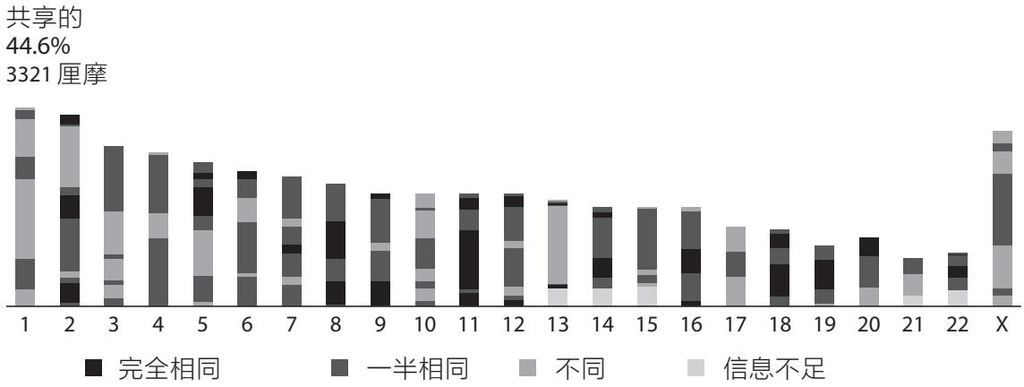

图6.1 一对姐弟23条染色体片段的血缘同源。图片来自作者的23andMe®资料。作者和她的弟弟共享的DNA片段总长度为3321厘摩(cM)，占作者基因组的44.6%。

平均而言，我们预计将共享50%的DNA片段。但这是平均数。如果你抛出一枚硬币1000次，预计它将有50%的时间落在正面，即500次。但在现实中，它可能会有501次落在正面。或者更奇怪的，545次。就像掷硬币一样，繁殖是一个随机的过程。兄弟姐妹中的任何两个人预计会共享50%的DNA片段，但在现实中，他们可能会共享多一点或少一点。迈卡和我共享的比例比预期的要低一点：44.6%。

2006年，统计遗传学家彼得·维舍尔和他的同事进行了一项研究，该研究利用了兄弟姐妹之间血缘同源的程度存在随机变化的事实（有时低于50%，有时更高）。 ㊟ 【Peter M.Visscher et al.,“Assumption-Free Estimation of Heritability from Genome-Wide Identity-by-Descent Sharing between Full Siblings,”PLOS Genetics 2,no.3 (March 24,2006):e41,https://doi.org/10.1371/journal.pgen.0020041.】 对于每一对兄弟姐妹，他们将基因组划分为所谓厘摩（缩写为cM）的片段，并计算兄弟姐妹之间共享的1厘摩片段的实际数量（迈卡和我共享3321厘摩）。平均来说，维舍尔的样本中的兄弟姐妹共享49.8%的DNA片段，这与理论上的50%的预期非常接近。但是，任何一对个体都可能分享更多或更少：血缘同源的范围是37%到62%。

接下来，维舍尔和他的同事的问题是，那些血缘同源的程度较低的兄弟姐妹，是否表现出更大的身高差异。正如我在前一章所描述的，这个问题（基因是否对一个人的身高有影响）从根本上说是一个因果问题。答案是肯定的，这也许并不令人惊讶。

当然，兄弟姐妹的身高不同，也有遗传以外的原因（我弟弟在1989年的大部分时间里除了Rice Krispies香甜米花糖之外什么都不吃，这肯定会阻碍他的成长发育）。继承了更多不同基因的兄弟姐妹可能在身高上有所不同，但与使他们变高或变矮的其他因素相比，这些由基因造成的差异可能就微不足道了。那么，基因的相对影响可以表示为一个比率：兄弟姐妹因为遗传了不同的基因而在身高上体现出的差异，除以人们在身高上的一般差异。这个比率的名字，大家可能很熟悉，那就是身高的遗传率。在这项关于身高的研究中，研究者得出结论：身高的遗传率约为80%。也就是说，身高的总差异中约有80%是由于人们继承了不同的基因。

#### 遗传率谈的是差异

在这里，不妨回顾一下我在前面两章中提出的论点，因为（就像温水煮青蛙）我们已经从一个没有争议的前提走到了一个有高度争议的前提。从上一章开始，我从无争议的前提出发：比较两组被随机分配到X或非X的受试者的平均结果，是对X的平均因果效应的测试。然后，我指出，以父母的基因为条件，兄弟姐妹被随机分配到不同的遗传变异。因此，对基因不同的兄弟姐妹的比较，是对该遗传变异的因果效应的测试。这是自然界最真实的自然实验(natural experiment)。这种因果测试可以用反事实的条件依赖(counterfactual dependence)来描述：如果一个人的基因型不同，那么他的生活结果也会不同吗？

在本章中，我已经开始解释研究者如何去实际进行这种因果检验。维舍尔关于身高的研究利用了兄弟姐妹间基因型的差异：如果一个人的基因型与他的兄弟姐妹的基因型的差异更大，那么他的身高与他的兄弟姐妹的身高的差异是否也会更大？这个因果检验的结果又可以用一个大家可能很熟悉，或者至少听起来很熟悉的统计数字来表示：遗传系数(heritability coefficient)。

通过这种方式，我们得出了一个肯定会引起一些读者异议的结论：遗传率估计值，即对“生活结果的差异在多大程度上由基因型差异造成”的量化，是对遗传是否对生活结果有因果影响的检验。

在遗传学中也许找不到一个概念像遗传率(heritability)那样造成了那么多的困扰。不幸的是，这个专业术语听起来像一个普通的英语单词。“遗传率”这个词的词源比任何关于DNA的知识都要早几千年。heres在拉丁语中是“继承人”的意思，是指某人死后在法律上有权获得其财产和社会地位的（男）人。“世袭”(hereditary)贵族的社会，是财富、等级、头衔、权力和特权代代相传的社会。“遗产”(inheritance)是从父母手中转移到子女手中的资产。我们听到“遗传率”这个词时，几乎无法摆脱几千年来关于“继承”如何运作的文化包袱。继承是要忠实地复制社会等级制度，继承的关键在于从父母到子女的不间断的延续性。

但是，正如我在第二章讨论的，人类并不是“纯育”的。有人想象可遗传性状(heritable traits)就是从父母到孩子完整遗传的性状，但这是一个错误，因为这种设想忽略了一个事实，即一半的遗传变异存在于家族内部。我的每一个基因都有两个拷贝，这种家族内部的遗传多样性在我的子女之间的遗传差异中表现出来。

我们继续以身高为例。80%的遗传率意味着，在被研究的人群中（这一点很重要，我将在本章末尾再次提到），大部分的身高差异是由人与人之间的遗传差异造成的。但是这些导致身高差异的遗传差异既存在于家族内部，也存在于不同家庭之间。如果人群中成年男性身高的标准差为3英寸（约8厘米），平均值为70英寸（约178厘米），我们就会预期人群中的身高分布看起来像图6.2的上半部分。我们可以将这一分布与父亲身高略高于平均水平（71英寸，约180厘米）的所有潜在男性后代的身高分布相比较，即图6.2的下半部分。潜在结果的波动范围有所缩小（身高稍高的父母的孩子不太可能非常矮小），但波动肯定不会消失。

所以，观察到高的遗传率，并不意味着人与人之间的不平等会在几代人之间完全复制：有时高大的父母会有较矮的孩子。实际上，高遗传率意味着，同一对父母的孩子在生活结果上会有差异。遗传率谈的是在遗传层面不同的人是否表现出表型差异，而兄弟姐妹在遗传层面是不同的。

#### 七个不平等领域的遗传率

我们已经讨论了如何利用兄弟姐妹的血缘同源差异来估计身高的遗传率。这种方法依赖于测量人们的DNA，但遗传率的概念早于测量DNA的技术。在过去的一个世纪里，甚至在今天，估计遗传率的最常见方法是将同卵双胞胎与异卵双胞胎相比较。

有关双胞胎或三胞胎的新闻报道经常关注那些出生时就被分开并在不同家庭长大的婴儿， ㊟ 【Nancy L.Segal,Born Together Reared Apart:The Landmark Minnesota Twin Study,illustrated edition (Cambridge,MA:Harvard University Press,2012).】 如电影《孪生陌生人》中的三兄弟。 ㊟ 【Three Identical Strangers (2018),IMDb,accessed February 9,2021,https://www.imdb.com/title/tt7664504/.】 但绝大多数的双生子研究都是针对那些由亲生父母在同一家庭中抚养的双胞胎。从此处开始，除非我特别提到“分开抚养”的双胞胎，否则我说的都是在同一家庭中一起长大的双胞胎。这类双生子研究的基本逻辑，大家可能很熟悉。考虑一下那些有名的同卵双胞胎，比如《哈利·波特》中的韦斯莱双胞胎；还有挑战马克·扎克伯格对Facebook所有权的温克尔沃斯双胞胎，即卡梅伦·温克尔沃斯和泰勒·温克尔沃斯。每一对同卵双胞胎都是作为单一的受精卵开始的，但在发育的早期阶段，细胞分裂的偶然性导致了从一个受精卵变成两个受精卵。同卵双胞胎，或称单卵双胞胎，并不总是在遗传层面百分之百地相同，因为有一些事情发生。基因突变发生在受精卵发育的早期，但在受精卵分裂之后发生，这导致了一对双胞胎之间的遗传差异，甚至是同一个人身体不同部位之间的遗传差异。而同卵双胞胎在基因表达(expression)上也会有差异，也就是他们拥有的基因于何时，以及在身体的哪个部位被“打开”或“关闭”。

但即使有这些差异，同卵双胞胎在历史上一直是人们着迷的对象和极大好奇心的焦点，他们仍然是自然界里最引人入胜的自然实验之一：当别人在与你完全相同的地方开始生活，甚至在生命最初的几个小时里与你是同一个生命体的时候，会发生什么？

异卵双胞胎的开端，则更为平凡一些。他们就像非双胞胎的兄弟姐妹一样，各自由独特的精子和卵子组合形成。唯一不同的是，这些卵子是在同一个月经周期中释放的，因此在一次怀孕中产生了两个胎儿。

所有双胞胎，无论同卵还是异卵，只要不是“出生后被分离”并寄养到不同的家庭，其最初社会地位的一切都是相同的，特别是由社会科学的大多数关键变量定义的指标，如家庭住址、家庭收入和学区。因此，我们预计，双胞胎长大后会彼此相似。双生子研究的关键是这个问题：同卵双胞胎的相似程度，比异卵双胞胎的相似程度多多少？

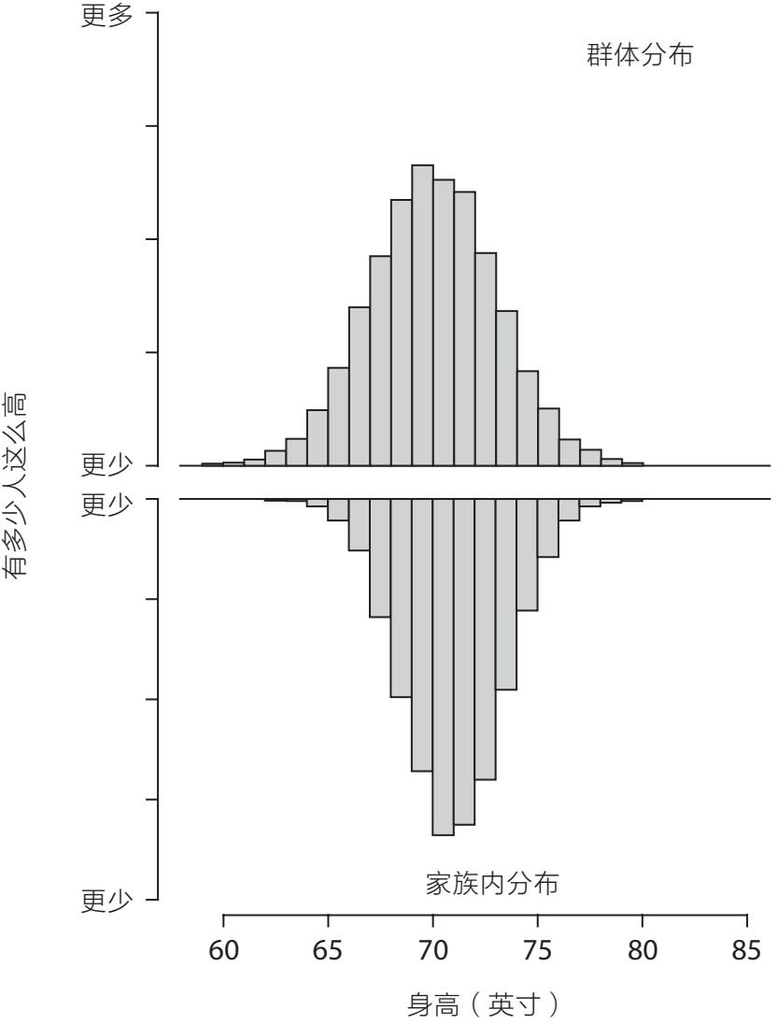

图6.2 一般人群中的预期身高分布（上）与单对父母的潜在后代的预期身高分布（下）。人群分布基于平均数70英寸（约178厘米），标准差为3英寸（约7.6厘米）。家族内部分布，即一对父母的所有可能的后代中的身高分布，基于0.8的遗传率。例子和计算方法改编自Peter M.Visscher,William G.Hill,and Naomi R.Wray,“Heritability in the Genomics Era--Concepts and Misconceptions,”Nature Reviews Genetics 9,no.4 (April2008):255–66,https://doi.org/10.1038/nrg2322。

所有在同一家庭长大的双胞胎都接触到同样的父母缺陷、同样的社区条件、同样的学校。但同卵双胞胎共享的东西更多。他们还共享（几乎）所有的遗传密码。或者换句话说，异卵双胞胎共享的东西更少。与同卵双胞胎相比，异卵双胞胎在基因上有更多的不同。就像我在本章开始时描述的关于身高的兄弟姐妹对照研究一样，检验遗传对生活结果的因果影响的关键问题是这样的：遗传差异较大的人（在本案例中是异卵双胞胎与同卵双胞胎相比）是否也有更大的表型差异？与同卵双胞胎相比，异卵双胞胎在某一特定性状（如身高）上的差异越大，该性状的遗传率就越高。

2015年，《自然—遗传学》杂志上的一篇论文总结了五十年来的双生子研究：共计2000多篇科学论文，对200多万对双胞胎的1.7万多个性状作了测量。 ㊟ 【Tinca J.C.Polderman et al.,“Meta-Analysis of the Heritability of Human Traits Based on Fifty Years of Twin Studies,”Nature Genetics 47,no.7 (July 2015):702–9,https://doi.org/10.1038/ng.3285.】 从2015年的论文中，我提取了七个不同生活领域的数据，并绘制了这些数据的图表，见图6.3。

前两个领域是人的心理学方面：性格特征和认知能力。这些心理特征很重要，因为它们是与第三个结果（教育成功）最密切相关的心理特征。 ㊟ 【Sophie von Stumm,Benedikt Hell,and Tomas Chamorro-Premuzic,“The Hungry Mind:Intellectual Curiosity Is the Third Pillar of Academic Performance,”Perspectives on Psychological Science 6,no.6 (November 1,2011):574–88,https://doi.org/10.1177/1745691611421204.】 而教育又是决定一个人在第四个领域（劳动力市场）取得成功的有力因素。失业和/或低收入的人往往会在第五个领域（社会对健康的危害）遇到困难，如生活在有污染和暴力事件发生率较高的贫困社区。最后两个领域是发生精神障碍的风险，如抑郁症或酗酒；以及人际关系，如是否结婚或离婚，是否感到孤独，与朋友交往，等等。

从图6.3中图形的大小可以看出，双生子研究多如牛毛，有超过100万对双胞胎为精神障碍的双生子研究提供了数据。而且你会从圆圈和三角形之间的空隙中看到，在每个领域，异卵双胞胎都比同卵双胞胎有更大的差异。异卵双胞胎相关性和同卵双胞胎相关性之间的距离越远，遗传率就越高。

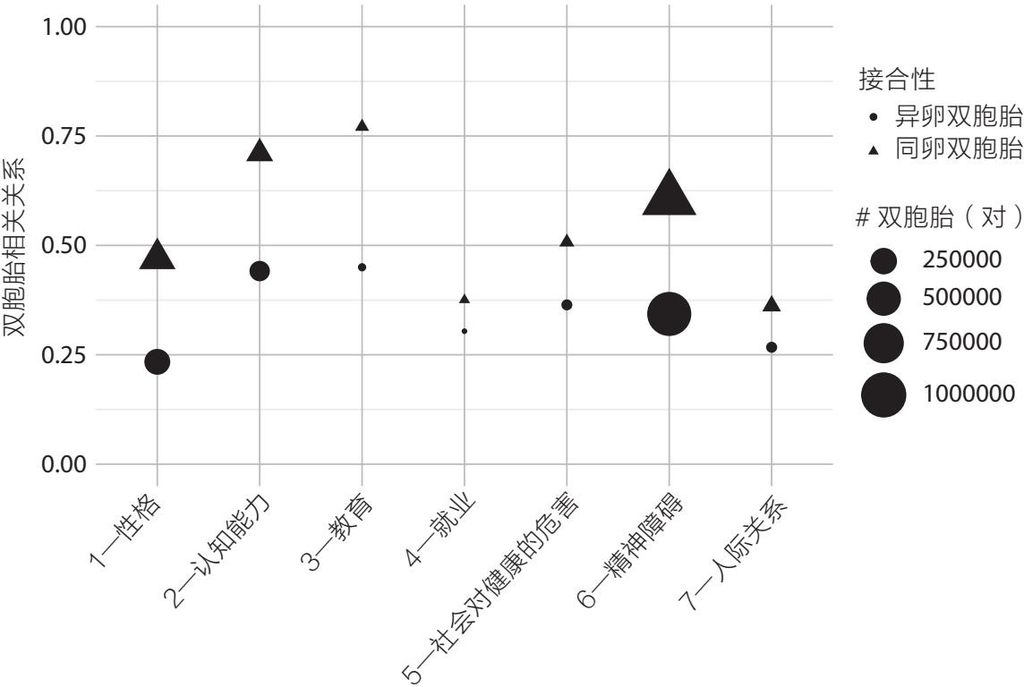

图6.3 七个不平等领域的同卵双胞胎和异卵双胞胎的相关关系。作者分析的数据出自Tinca J.C.Polderman et al.,“Meta-Analysis of the Heritability of Human Traits Basedon Fifty Years of Twin Studies,”Nature Genetics 47,no.7 (July 2015):702–9,https://doi.org/10.1038/ng.3285。

#### 一种常见的反对意见

甚至在我写作本书的时候，我也听到很多人异口同声地喊出了一个我很熟悉的反对意见：“遗传率的估计值是特定于一个人群的。”也就是说，即使这些不平等的领域在被测量的特定人群中是可遗传的，得出的遗传率也不是在所有时间、地点和人群中都成立的固定的自然法则。与全基因组关联分析(GWAS)一样，双生子研究在研究对象上有明显的欧洲中心主义倾向。在20世纪和21世纪初，双生子研究的对象主要是生活在美国的明尼苏达州、科罗拉多州、得克萨斯州、威斯康星州、弗吉尼亚州，以及荷兰、挪威、丹麦、芬兰、瑞典、英国和澳大利亚的白人成年人。如果科学家研究的是生活在不同的时间和地点、处于不同的社会结构的人群，或者在未来研究其他人群，那么生活结果的遗传率也可能不同。仅举一个例子，作为女性，如果我出生在1782年而不是1982年，我就不会被允许上大学，更不用说攻读博士学位了。随着受教育的环境机会(environmental opportunities)的改变，我随机继承的基因的相关性也随之改变。在接下来的章节中，我将讨论多个类似的经验性例子，来说明遗传率在不同的社会和历史背景下如何不同。

遗传率有可能（而且确实）在不同人群中有所不同，这一事实一直是批评行为遗传学的人们的主要论据，这些批评者主张完全放弃遗传率的概念及对遗传率的估算。正如生物学家理查德·陆文顿在1974年的讲话：“我建议我们停止无休止地寻找更好的方法来估计无用的量。” ㊟ 【Richard C.Lewontin,“The Analysis of Variance and the Analysis of Causes,”International Journal of Epidemiology 35,no.3 (June 2006):520–25,https://doi.org/10.1093/ije/dyl062】 又如心理学家理查德·勒纳在2004年的哀叹：“为什么我们要不断地重新埋葬行为遗传学？” ㊟ 【Richard M.Lerner,“Another Nine-Inch Nail for Behavioral Genetics!,”Human Development 49,no.6 (2007):336–42,https://doi.org/DOI:10.1159/000096532.】 再如经济学家查尔斯·曼斯基在2011年的疑问：“为什么遗传率研究会持续存在？……这项工作继续进行，但我不知道为什么。” ㊟ 【Charles F.Manski,“Genes,Eyeglasses,and Social Policy,”Journal of Economic Perspectives 25,no.4 (Fall 2011):83–94,https://doi.org/10.1257/jep.25.4.83.】

但是，其他一些关于不平等的人口统计数据，也是特定于具体的时间和地点的，而我们不会因此将其视为不重要。例如，基尼指数是对收入不平等的衡量。每个人的收入完全相同的国家，其基尼指数为0；只有一个人赚得盆满钵满而其他人一无所有的国家，其基尼指数为1。正如一个性状没有单一的遗传率，一个国家也没有单一的基尼指数，因为它随着经济和政治的变化而变化。如果有人用基尼指数来描述每个特定社会中的人们在历史的特定时刻经历的不平等，我们不会急吼吼地说这个基尼指数仅对这个特定人群有效，所以它是无价值的。

就像基尼指数一样，遗传率和多基因指数关联要看具体的历史和地理条件，这没错，但遗传率和多基因指数关联的意义和价值并不会因此而减少。 ㊟ 【另一种反对意见：这些性状是否可遗传并不重要，因为一切都是可遗传的。也就是说，你能测量到的个体在人群中的一切差异，都显示出一些可遗传变异的证据。这甚至适用于一些愚蠢的性状，如你看多少电视或你喜欢吃多少马麦酱。愚蠢的例子对于反击我在上一章讨论的那种直觉很有用，即认为遗传因果关系意味着类似生物决定论的机制。我们不会在“基因组水平”上理解为什么某人喜欢马麦酱和看电视。但我们并不关心喜欢马麦酱的遗传率，不是因为遗传率是一个无用的和“比喻的”统计数字，而是因为我们并不关心人们是否喜欢马麦酱。但我们确实关心人们能否从大学毕业。遗传率统计在科学和哲学层面的重要性，来自表型在科学和哲学层面的重要性。Eric Turkheimer,“Three Laws of Behavior Genetics and What They Mean,”Current Directions in Psychological Science 9,no.5 (October 1,2000),160–64,https://journals.sagepub.com/doi/10.1111/1467-8721.00084.】 即使遗传率的估计值完全是针对具体的特定人群的，它仍然是对“生活结果中的不平等在多大程度上由该人群的遗传抽彩结果造成”的一个重要总结。尽管有人主张抛弃遗传率的概念，但我预计遗传率研究将继续存在。遗传率研究之所以能够持续存在，是因为它回答了一个问题：在我们实际生活的社会中，人们的基因（一种他们无法控制的偶然）是否造成了人们在教育、收入、福祉和健康等方面的差异。 [1]

#### 遗传率缺失的问题

特别是在赫恩斯坦和默里的《钟形曲线》之后，双生子研究的假设受到了严格的审视。而且，无论是否出于政治动机，我们都有很好的理由对双生子研究的假设进行审视。双生子研究确实做了很多假设，其中许多可能不会让你觉得特别可信。首先，双生子研究假设同卵双胞胎不会单纯因为他们是同卵双胞胎而受到更相似的待遇。这就是“同等环境假设”(equal environments assumption)。如果你曾经看到双胞胎穿着完全相同的服装，就连袜子和蝴蝶结也一模一样，那么“同等环境假设”可能看起来有点牵强。 ㊟ 【平等环境的假设受到了很多审视，而利用DNA测量进行的较新研究在很大程度上发现了支持它的证据。一项值得注意的研究利用了这样一个事实：父母、儿科医生，甚至双胞胎自己也经常误判双胞胎的接合性(zygosity)，即认为他们是同卵双胞胎，而实际上是异卵双胞胎，或者反之亦然。一项对大约300名荷兰双胞胎的研究发现，父母对他们孩子的接合性有19%的错误判断。我在得克萨斯州进行的双生子研究中发现了类似的情况：在猜测DNA结果将显示双胞胎是同卵双胞胎还是异卵双胞胎方面，见过一组双胞胎的大学生比双胞胎的父母更容易猜对。社会学家道尔顿·康利和他的同事利用父母的这种偏见来检验平等环境假设。康利等人推断，如果同卵双胞胎比异卵双胞胎更相似是因为他们的父母对待他们的方式更相似（这违反了平等环境假设），那么，实际上是异卵双胞胎、却被错误归类为同卵双胞胎的双胞胎，将比被正确归类为异卵双胞胎的双胞胎更相似。事实上，这正是康利希望发现的结果。对于一位惯于以恐惧和厌恶的态度看待行为遗传学结果的社会学家来说，这个实验的设计似乎很聪明，可以驳斥稳步增长的证据，即基因对于理解社会不平等很重要。但他没有发现自己想要的结果！相反，康利的研究发现，双胞胎的表型相似性（即双胞胎的结果有多相似）跟随了他们的实际遗传关系，而不是他们的父母认为他们的接合性是什么。这就支持了同等环境假设。Dalton Conley et al.,“Heritability and the Equal Environments Assumption:Evidence from Multiple Samples of Misclassi.ed Twins,”Behavior Genetics 43,no.5 (September 2013):415–26,https://doi.org/10.1007/s10519-013-9602-1.】 更为普遍的情况是，基因和环境以复杂的方式相互关联，可能难以测量和统计，这让人们一直怀疑，也许双生子研究将实际上由环境决定的东西归于遗传了。

早期全基因组关联分析(GWAS)的结果让人们怀疑，双生子研究从根本上出了问题。正如我在第三章描述的，在对100多万人受教育程度的GWAS中，关联信号最为显著的几个位点只能解释人与人之间受教育程度差异的1%的零头，相当于几周的额外教育。 ㊟ 【James J.Lee et al.,“Gene Discovery and Polygenic Prediction from a Genome-Wide Association Study of Educational Attainment in 1.1 Million Individuals,”Nature Genetics 50,no.8 (August 2018):1112–21,https://doi.org/10.1038/s41588-018-0147-3.】 如果你把GWAS确定的所有基因以多基因指数的形式放在一起，这些变异可以解释约13%的教育程度的差异。与我们看到的其他社会科学变量的效应值（例如，家庭收入可以解释受教育程度差异的11%）相比，13%是相当可观的。 ㊟ 【Matthew J.Salganik et al.,“Measuring the Predictability of Life Outcomes with a Scienti.c Mass Collaboration,”Proceedings of the National Academy of Sciences 117,no.15 (April 14,2020):8398–8403,https://doi.org/10.1073/pnas.1915006117.】 不过，这与双生子研究估计的“40%的受教育程度差异是由遗传造成的”相比，仍有很大差距。 ㊟ 【Amelia R.Branigan,Kenneth J.McCallum,and Jeremy Freese,“Variation in the Heritability of Educational Attainment:An International Meta-Analysis,”Social Forces 92,no.1 (September 2013):109–40.】

GWAS发现的遗传能够解释的差异，与双生子研究估计的遗传率之间的差距，被称为“遗传率缺失”(missing heritability)问题（图6.4）。

[figure not shown]

图6.4 遗传率缺失的案例。Image reproduced by permission of Springer Nature from Brendan Maher,“Personal Genomes:The Case of the Missing Heritability,”Nature 456,no.7218 (November 1,2008):18–21,https://doi.org/10.1038/456018a.

不过，在用“遗传率缺失”现象来断然否定双生子研究的结论之前，我们要记住，我们也有理由怀疑GWAS和多基因指数研究低估了基因的影响，原因至少有两个。 ㊟ 【Alexander I.Young,“Solving the Missing Heritability Problem,”PLOS Genetics 15,no.6 (June 24,2019):e1008222,https://doi.org/10.1371/journal.pgen.1008222.】 首先，这些方法并没有测量每一个遗传变异，特别是罕见的遗传变异，它们可能有特别大的影响。其次，即使是样本量多达100多万人的GWAS，也可能没有足够的样本量去检测个别基因的非常微弱但仍然非零的影响。

如果双生子研究得出的遗传率估计值可能太高，而GWAS得出的遗传效应(genetic effects)估计值可能太低，那么遗传的DNA变异对生活结果（如教育）的影响的最佳估计值是多少？说到底，正如统计遗传学家亚历克斯·扬(Alex Young)解释的，“解决遗传率缺失问题的最深层次手段，是识别所有具有因果性的遗传变异，并测量它们能解释多少性状变异”。 ㊟ 【Young.】

显然，对于任何人类表型来说，我们还没有做到这一点，更不用说像教育这样复杂的表型了。同时，获得遗传率的适中（不太大，也不太小）估计值的一种方法，是我在本章开始时说到的同胞回归法(sibling regression method)，该方法使用成对的兄弟姐妹之间的随机变异来确定血缘同源的程度。这种方法可以扩展到使用其他类型的生物学亲属，这种方法被称为“亲缘关系不平衡回归”(relatedness disequilibrium regression)，缩写为RDR。 ㊟ 【Alexander I.Young et al.,“Relatedness Disequilibrium Regression Estimates Heritability without Environmental Bias,”Nature Genetics 50,no.9 (September 2018):1304–10,https://doi.org/10.1038/s41588-018-0178-9.】

在图6.5中，我绘制了使用同胞回归法、RDR和双生子方法对四种结果的遗传率估计：(1)身高，(2)身体质量指数，(3)女性的初次生育年龄，以及(4)受教育程度。就教育而言，基因是否造成了结果中40%的差异，或更接近17%的差异，仍然存在一些不确定性。但作为比较，请记住，家庭收入只造成了美国白人受教育程度差异的11%。 ㊟ 【Lee et al.,“Gene Discovery and Polygenic Prediction from a Genome-Wide Association Study of Educational Attainment in 1.1 Million Individuals.”】 这种比较告诉我们，即使抛开双生子研究的有争议的假设，受教育程度的遗传率仍然不是零。遗传差异导致了教育结果的差异，而且遗传差异的影响在解释教育结果差异方面，至少与家庭收入这样的变量同等重要。

#### 多基因指数的家族内研究

以双胞胎或兄弟姐妹为研究对象的遗传率研究告诉我们，整个基因组对人们的生活结果有总体影响，但这些研究并没有告诉我们，是哪些具体的遗传变异在驱动这种影响。相比之下，GWAS的目的是识别具体的遗传变异，但典型的GWAS研究是对来自不同家庭的人进行比较，因此总是有可能“捕获”环境的影响，而这些影响恰好与遗传差异相关联。合并上述两种方法的手段，是使用GWAS的结果来构建一个多基因指数，然后用家庭成员的样本来测试这个多基因指数。当我们研究基因彩票如何在一代人中发挥作用时，家庭成员之间的遗传差异是随机的，而不是与不同家庭之间的血统、地理和文化差异交织在一起。因此，多基因指数的家族内研究方法是利用自然界的实验，来测试多基因指数“捕获”的特定基因是否会导致生活结果的差异。

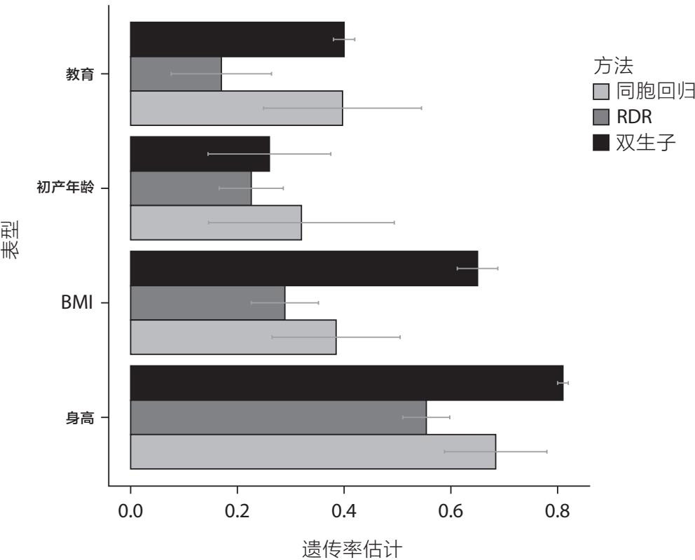

图6.5 三种不同方法对四种人类表型的遗传率估计。“教育”=受教育程度（接受正规学校教育的时长）。“初产年龄”=女性第一次生育的年龄。“BMI”=身体质量指数。“身高”=成年后的身高。“双生子”方法通过比较一起长大的单卵双胞胎的相似性和一起长大的双卵双胞胎的相似性来估计遗传率。“同胞回归法”通过利用成对的兄弟姐妹之间的随机变异来估计遗传率，即通过血缘同源的程度来判断。“RDR”（亲缘关系不平衡回归）方法将同胞回归方法扩展到其他成对的亲属，一对亲属的亲缘关系以他们父母的亲缘关系为条件。误差棒代表标准误差。大部分遗传率估计值出自Alexander I.Young et al.,“Relatedness Disequilibrium Regression Estimates Heritability withoutEnvironmental Bias,”Nature Genetics 50,no.9 (September 2018):1304–10,https:// doi.org/10.1038/s41588-018-0178-9,只有“双生子”方法对受教育程度遗传率的估计值出自Amelia R.Branigan,Kenneth J.McCallum,and Jeremy Freese,"Variation in the Heritability of Educational Attainment:1 (2013):109·140 ；“双生子”方法对女性初次生育年龄的遗传率的估计值出自Felix C.Tropf et al.,“Genetic Influence on Age at First Birth of Female Twins Born in the UK,1919–68,”Population Studies 69,no.2(May 4,2015):129–45,https://doi.org/10.1080/00324728.2015.1056823。

有三种不同类型的家族内研究，研究者用它们来调查基因彩票的影响：(1)兄弟姐妹的比较研究，(2)被收养者和非被收养者的比较研究，以及(3)父母—子女三人组的研究。

兄弟姐妹的研究也许是最简单的：多基因指数不同的兄弟姐妹，他们的生活结果是否不同？这样的一项研究跟踪了英国2000多对异卵双胞胎，从他们12岁开始一直跟踪到21岁。 ㊟ 【Saskia Selzam et al.,“Comparing Within- and Between-Family Polygenic Score Prediction,”The American Journal of Human Genetics 105,no.2 (August 1,2019):351–63,https://doi.org/10.1016/j.ajhg.2019.06.006.】 研究者测量了每个人的身高、身体质量指数、自评健康状况、多动症症状、精神病经历、神经质、智力测试分数以及由GCSE（英国的中等教育普通证书，这是一种标准化测试，类似于美国的SAT，在16岁左右进行）分数衡量的学业成就。对于每一种生活结果，研究者可以测试，多基因指数差异较大的兄弟姐妹是否在生活结果上表现出较大的差异。

的确如此。遗传差异最大的一对双胞胎的实际身高相差近9厘米。他们的身体质量指数相差3个点，这相当于一个身高170厘米的女性的体重增加了20磅。他们的GCSE分数相差0.5个标准差。

英国的这项双生子研究对受试的双胞胎进行了跟踪，直到他们年满21岁。当然，21岁的时候，人生还很漫长。那么，当人们开始成为“真正的”成年人，结了婚、有抵押贷款时，他们的情况如何？

在本书第二章简要介绍过的一项研究中，哥伦比亚大学社会基因组学研究员丹尼尔·贝尔斯基和他的同事探讨了这个问题。 ㊟ 【Daniel W.Belsky et al.,“Genetic Analysis of Social-Class Mobility in Five Longitudinal Studies,”Proceedings of the National Academy of Sciences 115,no.31 (July 31,2018):E7275–84,https://doi.org/10.1073/pnas.1801238115.】 使用基于受教育程度GWAS的多基因指数，贝尔斯基和他的同事发现，教育多基因指数比自己的兄弟姐妹高的人的受教育程度更高，从事更有声望的职业，并且在工作生涯结束时更富有。由于这些兄弟姐妹的遗传变异的差异是完全随机的孟德尔式抽彩的结果，这项研究提供了一些最令人信服的证据，表明一个人的基因确实会导致教育和财富的差异（当然，像社会科学领域的许多随机控制试验的因果推论一样，我们仍然不知道这些遗传效应是如何运作的，只是知道它们确实是这样的。我们将在下一章讨论这个问题）。

利用被收养者来研究基因彩票的想法，在一项巧妙的研究中得到了展示，该研究使用了英国生物样本库(UK Biobank)的数据。 ㊟ 【Rosa Cheesman et al.,“Comparison of Adopted and Nonadopted Individuals Reveals Gene–Environment Interplay for Education in the UK Biobank,”Psychological Science 31,no.5 (May 1,2020):582–91,https://doi.org/10.1177/0956797620904450.】 被收养者，顾名思义，不是由他们的亲生父母抚养长大的。这意味着被收养者的遗传特征与养父母的遗传特征没有关系，所以被收养者的遗传特征与“同其养父母的遗传特征相关的血统、地理、社会地位和文化的复杂网络”的联系较少。在对英国6000多人的研究中，罗莎·齐斯曼及其同事表明，教育多基因指数确实与被收养者的受教育程度有关，但这种关系的强度比非被收养者的要弱。因此，这项研究为一个人自己的基因对受教育程度的“直接”影响提供了证据，同时也提出了一个问题：为什么教育多基因指数与亲生父母抚养的孩子的结果有更强的关联（这个问题我们将在第九章再次讨论）。

最后一种家族内研究是测量父母—子女三人组（一对生物学父母和他们的一个孩子）的DNA。对于父母中的任意一人来说，他或她的基因组可以分为两部分：传递给孩子的基因和未传递的基因。对每个孩子来说，获得了哪些基因和未获得哪些基因是随机的，是基因彩票的结果。那么，与未传递给孩子的基因相比，传递给孩子的基因与孩子的生活结果有多强的关系，是对基因的因果效应的一项检验。父母传递给孩子和未传递给孩子的基因都与父母的血统、环境、地理和文化等方面相关，但只有传递下去的基因是（随机地）生物遗传的。

使用“父母—子女三人组”方法的最引人注目的研究是在冰岛进行的。 ㊟ 【Augustine Kong et al.,“The Nature of Nurture:Effects of Parental Genotypes,”Science 359,no.6374 (January 26,2018):424–28,https://doi.org/10.1126/science.aan6877.】 研究者对超过2万名已进行基因型分型的人士和他们的父母进行了研究，得出了与兄弟姐妹对照研究和收养研究类似的结论。当你在家族内部进行比较时，教育多基因指数和受教育程度之间的关联性会减弱，但肯定不会消失。所以，三种方法得出了同一个结论：基因彩票的结果对一个人在学校的发展有因果关系。

再把视角放广一些。当我们把五十年来的双生子研究结果和最近几年来DNA研究的结果放在一起时，我们就不可避免地得出一个结论：人们之间的遗传差异导致了社会不平等，包括受教育程度的不平等，也包括身体健康结果（如身体质量指数）、心理结果（如多动症和其他精神障碍）以及生育结果（如初次生育年龄）的不平等。

1962年，演化生物学家杜布赞斯基 ㊟ 【Theodosius Dobzhansky,“Genetics and Equality:Equality of Opportunity Makes the Genetic Diversity among Men Meaningful,”Science 137,no.3524 (July 13,1962):112–15,https://doi.org/10.1126/science.137.3524.112.】 写道：“人们在能力、精力、健康、性格和其他重要的社会特征方面存在差异。而且我们有很好的证据，尽管不是绝对结论性的证据，表明所有这些特征的差异部分是受遗传规定的。请注意，是受遗传规定(conditioned)，而不是由遗传固定(fixed)或注定(predestined)。”杜布赞斯基是对的。在他写下这段话之后的几十年里，科学界积累的大量证据使得他的这个结论更加确凿无疑。

不幸的是，虽然杜布赞斯基和其他一些人在半个世纪前就清楚地认识到了这一点，科学界却浪费了大量精力去争论这个事实，因为确定基因是社会不平等的原因之一也许是研究事业中最容易的部分。更困难的问题是：基因如何造成社会不平等？我们将在下一章关注这个问题。

[1] 遗传率和遗传因果关系之间的联系，可以通过考虑在农业选种计划中如何使用遗传率系数来进一步澄清。所谓的“育种公式”(breeder's equation)是这样给出的。R = h2 × S，其中h2是种群中的遗传系数，R是对选择的反应，定义为各代之间平均表型的变化，S是被选作育种的亲代的性状与种群中平均值的差别。

在2019年的美国，男性的平均身高是176厘米。想象一下，一个反乌托邦式的独裁政权规定，只有身高超过某个阈值的男人才可以生儿育女。结果，被选去生育的父亲的平均身高是183厘米。那么在这个例子中，被选去生育的亲代的身高与人群平均身高之间的差异是7厘米。假设母亲也受到类似程度的选择，那么，假设环境中的其他一切都保持完全相同，下一代的男性孩子平均会比没有亲代选择的情况下高多少？根据我在本章开始时描述的维舍尔的研究，身高的遗传率估计为0.80，而不是1.0，所以下一代的儿子不会平均高7厘米。但高遗传率意味着，经过选择培育的亲代的后代的身高确实会大幅增加，平均增高5厘米多一点。人群中平均数的变化对“极端”值的出现频率有影响。在一个平均身高为176厘米的人群中，大约有1%的男性身高超过198厘米。将平均身高上移5厘米至181厘米，就约有4%的男性身高超过198厘米。

因为它决定了对选择的反应，所以遗传率的因果关系可以在操纵主义因果关系理论(manipulationist theory of causation)的框架内进一步理解。与我在上一章描述的理论—因果关系作为反事实的条件依赖(counterfactual dependence)—相关，操纵主义理论不是以“如果X没有发生，Y会发生什么？”这个问题为中心，而是以“如果你改变X,Y会发生什么？”这个问题为中心。詹姆斯·伍德沃德在《让事情发生》（第40页）中更准确地描述了这一点：“X导致Y的说法意味着，至少对某些人来说，他们拥有的X的某些值可能受到操纵，在其他适当的条件下（也许包括将不同于X的其他变量固定在某些值上），这将改变Y的值或这些人的Y的概率分布。”

选择实验(selection experiments)是这个要求的一个有趣的转折。基因(X)导致表型(Y)的说法意味着，至少对某些个体来说，他们拥有的X的某些值有可能被操纵。在选择的情况下，这种操纵是为了限制被允许繁衍的基因型的范围。考虑到其他适当的条件，包括将不同于X的其他变量（即环境条件）固定在某些数值上，这将改变这些个体的后代的Y的概率分布。

如果选择实验证明了基因对表型的因果作用，而遗传率决定了对选择的反应，那么就不可能得出结论说遗传率在某种程度上与因果关系无关。正如彼得·维舍尔在另一篇论文中所述的：“遗传率是遗传学的一个基本参数……它是生物演化和农业生产中选择的关键，也是医学中疾病风险预测的关键。”

James Woodward,Making Things Happen:A Theory of Causal Explanation,Oxford Studies in Philosophy of Science (Oxford:Oxford University Press,2003);Peter M.Visscher,William G.Hill,and Naomi R.Wray,“Heritability in the Genomics Era—Concepts and Misconceptions,”Nature Reviews Genetics 9,no.4 (April 2008):255–66,https://doi.org/10.1038/nrg2322.

## 第七章

## 作用机制的奥秘

1998年，我赢得了傅尔曼大学的绩优奖学金。傅尔曼大学是一所位于南卡罗来纳州的小型文理学院，曾属于浸信会。这笔奖学金涵盖了我四年的全部学杂费，包括一个学期的海外学习（在伦敦）。目前傅尔曼大学的学费是每年近五万美元，而我上大学一分钱没花。当时和现在一样，我完全没有运动细胞；我的课外活动没什么新意；我无需克服任何特别的困难，在面对挑战或逆境时也没有表现出特别的韧性。我唯一的所谓优点是在学术能力测试(SAT)中获得了近乎完美的分数。SAT是美国的大学入学考试，对高中生来说是一种迈入人生新阶段的仪式。

正如我在第六章描述的，我们可以相当有把握地认为，基因对一个人的受教育程度有因果关系的影响。而且，如我在第五章所述，说两样东西有因果关系，并不意味着我们知道这种因果关系的机制。就像我们对“把罗马尼亚孤儿从孤儿院拯救出来”为什么能够提高他们的智商测试分数不甚了解一样，我们对“一个人的基因如何最终影响他的教育成绩”也不甚了解。

但我们比较了解教育体制是如何运作的。以我自己的大学之旅为例。我父母都受过大学教育，他们对我上大学有明确的期望，并对如何驾驭招生过程有一定的了解。我也有机会接触到其他形式的社会资本，比如一个前一年上过傅尔曼大学的朋友和一个向我推荐大学的高中辅导员都为我提供了帮助。在机构层面，傅尔曼大学和许多小型文理学院一样，利用绩优奖学金来吸引考试成绩高的学生，这可以提高学校在《美国新闻》“最佳”大学名录中的排名，而更高的排名使学校更能够吸引其他潜在的学生，也就是那些支付全额学费的学生。

当我们想象遗传对复杂的生活结果（如教育）产生影响的可能机制时，下列的社会过程——父母的期望、进入有利的社会网络、商品化的教育市场中的机构竞争——并不是我们首先想到的东西。相反，我们很容易得出这样的结论：遗传原因必须有完全的生物机制，并发生在人体之内。

但要回答遗传如何影响教育结果的问题，我们不仅要研究分子和细胞之间的相互作用，还要研究人和社会机构之间的相互作用。在本章中，我将描述我们对遗传作用机制问题的了解，或者至少是我们自信了解的东西。我将重点讨论基因组和教育成功之间的路径，这既是因为这是我自己的研究小组做了大量工作的一个领域，也是因为教育在构建其他不平等的过程中占据核心地位。

正如我在第四章所述，我们必须记住，我在这里描述的一切都适用于理解群体内的个体差异。我在这里描述的研究工具（主要是双生子研究和多基因指数分析）无法解释群体间平均差异的原因。

#### 红发儿童和其他可能的世界

1972年，社会学家桑迪·詹克斯(Sandy Jencks)提出了一个关于遗传效应的社会机制的影响最持久的思想实验。 ㊟ 【Christopher Jencks et al.,Inequality:A Reassessment of the E.ect of Family and Schooling in America (New York:Basic Books,1972).】

例如，如果一个国家拒绝送红发儿童上学，那么造成红头发的基因可以说是降低了阅读测试的分数……在这种情况下，将红发人的文盲归咎于他们的基因，可能会让大多数读者觉得很荒谬。不过，传统的估计遗传率的方法恰恰就是这么做的。

詹克斯是对的。对遗传率的估计确实提供了关于基因是否导致某种表型的信息。但这些设计并未解释哪些机制将基因型和表型联系起来，而且相关机制可能不是直观的“生物学”过程。

詹克斯关于红发儿童的思想实验已经成为遗传学讨论中的一个“模因”(meme)。我认为它之所以能够产生持久的影响，是因为它直观地抓住了三个值得详细解读的观念：(1)因果链，(2)分析层次，以及(3)其他的可能世界。

首先，红发儿童的例子表明，基因可以通过较长的因果链与表型联系起来。 ㊟ 【复杂的人类行为并不是唯一通过长因果链与基因型相连的表型。正如演化生物学家理查德·道金斯所说：“任何遗传特征……无论是形态的、生理的还是行为的，如果不是某种更基本的东西的‘副产品’，那还能是什么？如果我们把这个问题想清楚，我们会发现所有的遗传效应都是‘副产品’，除了蛋白质分子。”类似地，现在我们越来越清楚地看到，即使是表面上简单的环境干预措施，如同伴规范(peer norms)和教师效应(teacher e.ects)，也可能依赖于涉及复杂社会过程的长因果链才能奏效。Richard Dawkins,The Extended Phenotype:The Long Reach of the Gene,rev.ed.(Oxford and New York:Oxford University Press,1999).】 在这个例子中，MC1R基因的一种变异会产生棕黑素，而棕黑素使人的头发明显变红。这种表型特征随后被其他人以文化和历史上特定的社会偏见来看待，而这些偏见在禁止某些儿童上学的社会政策中根深蒂固。

其次，这些因果链可以跨越多个分析层次。科研的一种方式，是将科学家研究的现象像千层蛋糕一样排列，每一层的物体都是上一层物体的一部分。 ㊟ 【Paul Oppenheim and Hilary Putnam,“Unity of Science as a Working Hypothesis,”in Concepts,Theories,and the Mind-Body Problem,Minnesota Studies in the Philosophy of Science,vol.2 (Minneapolis:University of Minnesota Press,1958),3–36,http://conservancy.umn.edu/handle/11299/184622.】 亚原子粒子，如夸克，是原子的一部分；个人是社会的一部分（图7.1）。詹克斯关于红发儿童的思想实验清楚地表明，因果链可以通过多个分析层次向上延伸：MC1R基因是DNA分子；它在细胞内编码产生了棕黑素蛋白；“红发”描述的是一个人，而禁止红发儿童上学的决定是一种社会现象。

当詹克斯断言“将红发人的文盲归咎于他们的基因，可能会让大多数读者觉得很荒谬”时，他正在提出的论点部分是关于描述和理解这一现象的最佳分析层次(level of analysis)：在他看来，即使因果链的一部分涉及DNA分子，认为上学是一种分子现象仍然是荒谬的。 ㊟ 【Carl F.Craver and Lindley Darden,In Search of Mechanisms:Discoveries across the Life Sciences (Chicago:University of Chicago Press,2013).】

最后，在詹克斯的例子中，很明显存在着其他可能的世界，在那些世界里，从基因到文盲的因果链被打破了。当你听到红发儿童的例子时，你可以立即想象出另一种社会，在这个社会中，所有的儿童都被允许上学，无论他们的头发颜色如何。也就是说，社会政策的改变，将在无需直接操纵儿童的基因或基因表达产物(gene products)的情况下，打破基因型和表型（无法正常接受教育）之间的因果链。要减轻教育受到的“遗传”的负面影响，我们不必编辑胚胎的DNA或给儿童服用药物来改变他们的生物学特性。

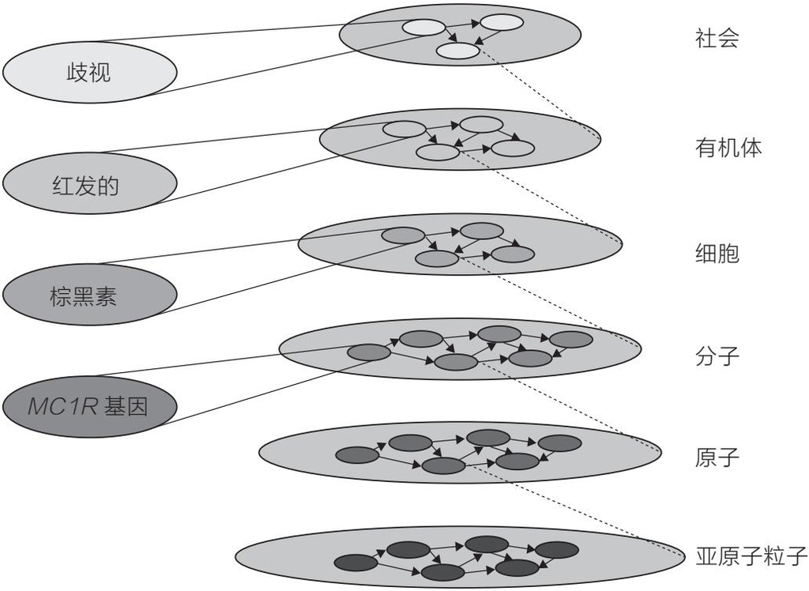

图7.1 科学分析的层次。本图表达的思想出自Carl F.Craver,Explaining the Brain:Mechanisms and the Mosaic Unity of Neuroscience(Oxford:Oxford University Press,2007);Paul Oppenheim and Hilary Putnam,“Unity of Science as a Working Hypothesis,”1958,http://conservancy.umn.edu/handle/11299/184622;and Christopher Jencks et al.,Inequality:A Reassessment of the Effect of Family and Schooling in America(New York:Basic Books,1972)。

我们可以把红发儿童跟HTT和亨廷顿舞蹈症之间的关系进行对比。首先，HTT和亨廷顿舞蹈症之间的因果链相对较短。也就是说，不需要那么多步骤来解释从头到尾的因果链。其次，HTT和亨廷顿舞蹈症之间的因果链都发生在明显是“生物学”的分析层次。也就是说，为了描述这个因果链，你要描述细胞内分子的活动。最后，很难想象会有另一个世界，在那里HTT不会导致亨廷顿舞蹈症。如果要打破从HTT到亨廷顿舞蹈症的因果链，就需要直接操纵人体的某些方面，例如运用基因编辑或药理学。

我们还可以设想一些因果链，它们既没有亨廷顿舞蹈症的严格生物决定性，也没有詹克斯假设的红头发的纯粹社会条件依赖性。例如，人们可以通过使用兴奋剂药物（改变细胞中的分子）、运用为完成规定任务提供及时奖励的行为策略（改变个人的行为），以及改变教室的结构（改变社会组织），来干预从而改善多动症儿童的学习功能。多动症既不纯粹是生物性的，也不纯粹是社会性的。它是一种经验和行为模式，产生于某人的特定神经生物学特征与特定社会环境的期望之间的交叉点。

遗传率分析或家族内多基因指数分析本身并不能告诉你，导致较低受教育程度的基因的运作是更像“红发儿童不可以上学”，还是更像HTT基因导致亨廷顿舞蹈症。即使我们知道遗传对社会不平等有因果影响，关于这些影响的机制仍然存在重要的疑问：因果链有多长，有哪些环节，跨越了多少个分析层次，以及（也许对于社会政策辩论来说最关键的是）如何才能找到打破或加强这个因果链的最优解？

从优生学之父弗朗西斯·高尔顿在19世纪的著作《遗传的天赋》 ㊟ 【Francis Galton,Hereditary Genius:An Inquiry into Its Laws and Consequences (London and New York:Macmillan,1892).】 开始，一直到21世纪的书籍，如保守派煽动分子查尔斯·默里的《人类多样性》 ㊟ 【Charles Murray,Human Diversity:The Biology of Gender,Race,and Class (New York:Twelve,2020).】 ，优生主义思想家们对上述问题提出了一套具体的答案：首先，遗传和社会不平等之间的因果链很短，主要是通过智力的发展来调节的；其次，遗传和社会不平等之间的因果链最好从细胞和有机体的分析层次来理解，智力被视为一个人的大脑的固有属性，而不是在社会环境中发展的东西；最后，打破这个因果链的另一种可能的世界是反乌托邦式的，需要国家大规模干预人们的家庭生活，或需要广泛的基因工程。简而言之，优生主义的表述是，基因导致社会阶层的划分，就像基因导致亨廷顿舞蹈症一样，通过普遍的、生物学层面的、很难（如果不是不可能）改变的机制来实现。

将遗传和社会不平等之间的联系概念化为一个简短的、生物学层面的、普遍的因果链，会削弱解决不平等的政治意愿。正如哲学家凯特·曼恩所说，将社会不平等“自然化”，实际上就是“使社会不平等看起来不可避免，或认为试图抵制它的人在进行一场必败的战斗”。 ㊟ 【Kate Manne,Down Girl:The Logic of Misogyny (New York:Oxford University Press,2017).】 说政府应该做一些事情来纠正不平等，就是暗示变革是可能的，而严格的基因决定论则暗示变化是不可能的，所以为什么要纠正不平等呢？基因决定论者认为，基因和社会不平等之间的关系最好从一个人的细胞生物学层面来理解，而不是从社会组织的层面来理解，这种想法与优生学的观念相呼应，即有些人天生就比其他人优越。正如演化生物学家杜布赞斯基在1960年代总结的：“保守派最喜欢的论点一直是，社会和经济地位单纯反映了人内在的能力。” ㊟ 【Theodosius Dobzhansky,“Genetics and Equality:Equality of Opportunity Makes the Genetic Diversity among Men Meaningful,”Science 137,no.3524 (July 13,1962):112–15,https://doi.org/10.1126/science.137.3524.112.】

这种出于意识形态动机的关于基因和社会不平等的联系机制的论点，可能会妨碍我们对科学本身的认识。归根结底，无论是关于人类优越性的优生观念，还是关于红发儿童的思想实验，都不能代替经验性的结果：我们对基因与社会不平等，特别是教育结果不平等之间的联系机制，究竟了解多少？ ㊟ 【重要的是要记住，机制未知（也许是通过不直观的媒介运作）的问题，并不是遗传原因特有的问题。事实上，这个问题可能伴随着任何从随机对照试验(RCT)中做出的因果推断。诺贝尔经济学奖得主安格斯·迪顿和科学哲学家南希·卡特赖特(Nancy Cartwright)在评论RCT的优缺点时指出，“还需要做大量的其他工作—经验性的、理论性的和概念性的，才能使RCT的结果可用”。你也许知道在这一组控制条件下以这种方式进行干预会产生这种平均处理效应(ATE)，但边界条件(boundary conditions)是什么？干预和最终结果之间的因果链是什么？人们对干预措施的反应有何不同？因此，仅仅利用自然界的随机化来测试一组遗传变异对结果的平均处理效应，是不够的。要使这种因果推断的结果具有科学性和实用性，还有经验性、理论性和概念性的工作要做。Deaton and Cartwright,“Understanding and Misunderstanding Randomized Controlled Trials,”Social Science & Medicine 210,special issue:Randomized Controlled Trials and Evidence-based Policy:A Multidisciplinary Dialogue (August 2018):2–21,https://doi.org/10.1016/j.socscimed.2017.12.005.】

这个研究领域发展很快，但就目前而言，我认为我们可以就遗传与教育不平等的联系机制说五点。

1.与教育有关的基因在大脑中活跃，而不是在头发、皮肤、肝脏或脾脏中。

2.将基因与教育联系起来的机制，在人体发育的早期，甚至在孩子出生之前就开始了。

3.遗传效应对教育成功的影响，涉及标准化测试所衡量的智力类型的发展……

4.……但不仅仅是智力。遗传效应对教育成功的影响还涉及所谓的“非认知”技能的发展。

5.要理解遗传效应的机制，需要理解人与社会机构之间的相互作用。

现在，让我们详细考虑这五点中的每一点。

#### “哪里”的问题：基因对大脑的影响

正如我在第三章所述，受教育程度或任何其他表型的GWAS给我们提供了一组相对简单的结果，包括一个SNP列表以及它们与我们研究的结果有多大的关联。就其本身而言，这组结果对我们理解机制的帮助不大。但是，就像《塔木德》作者对《托拉》 ㊟ 【《塔木德》是犹太教中仅次于《圣经》的主要经典，对犹太教律法进行注释和讲解。《托拉》狭义专指《摩西五经》，但可以涵盖所有的犹太教律法和教导。】 的精练文本进行注释一样，生物注释(bioannotation)会分析GWAS产生的极简单的结果，并根据我们对基因组和细胞生物学的了解，提供解释说明：单个SNP被映射(mapped)到基因上；基因被映射到基因功能和基因表达产物上，如蛋白质；基因表达产物被映射到细胞或组织内的生物系统(biological system)上。

生物注释工具箱里的一件重要工具，是测试与一个结果相关的基因是否在身体的某些部位或某些细胞类型中优先表达。你身体里的每一个细胞都有相同的DNA代码，但不同的细胞需要做不同的事情，所以它们以基因表达的典型模式来打开和关闭不同的基因。那么，有了一组GWAS的结果，分析人员就可以测试，与受教育程度、主观幸福感或肥胖等性状最相关的基因是否也更有可能在身体的某个部位表达。

这类基因表达工作给我们带来了一个重要的洞见：与受教育程度相关的基因在大脑中优先表达；而在大脑中，它们在神经元中优先表达。具体到与受教育程度相关的“顶级”(top)基因，它们参与了对神经元相互交流能力至关重要的过程。这些过程包括神经递质的分泌，这些递质在神经元之间传递信息；神经元连接的适应性，以应对新的信息或废弃的信息；以及维持离子通道(ion channel)，这是神经元的电荷所必需的。大脑在基因表达方面的中心地位，也体现在与社会不平等相关的其他每一种表型上：主观幸福感和抑郁症，酒精摄入和吸烟，肥胖和收入。

我们再回到詹克斯的红发儿童的例子。受教育程度的遗传率可能聚焦于由基因引起的身体外观的差异，然后引起其他人（对红发儿童）的不同待遇。不过，如果是这样的话，那么与受教育程度相关的基因就会在身体的其他地方表达，而不是在大脑中。但我们看到的并非如此。无论基因是如何使一些人更有可能或更不可能在教育方面取得成功，它们都是在人们的大脑中进行的，而不是在人的头发、肝脏、皮肤或骨骼中。

#### “何时”的问题：基因在人体发育过程的早期就开始产生影响

生物注释分析可以获得的另一个信息是，在人体发育过程中，与某一结果相关的基因何时被表达。在我们生命的不同阶段，不同的基因在我们身体里活跃。例如，与生长有关的基因在身体快速增长时是必要的，而一旦我们获得成年人的身材，这些基因就不那么重要了。生物注释分析显示，一些与受教育程度有关的基因在产前优先表达，那时儿童的大脑和神经系统仍在形成过程中。 ㊟ 【James J.Lee et al.,“Gene Discovery and Polygenic Prediction from a Genome-Wide Association Study of Educational Attainment in 1.1 Million Individuals,”Nature Genetics 50,no.8 (August 2018):1112–21,https://doi.org/10.1038/s41588-018-0147-3.】

了解基因何时变得相关的另一种策略，是分析在不同年龄段测量的双胞胎的数据。例如，我和我的同事研究了一个双胞胎样本，他们在生命的早期（10个月和2岁时）就被测量了认知能力。 ㊟ 【Elliot M.Tucker-Drob et al.,“Emergence of a Gene × Socioeconomic Status Interaction on Infant Mental Ability Between 10 Months and 2 Years,”Psychological Science 22,no.1 (January 2011):125–33,https://doi.org/10.1177/0956797610392926.】 在这些非常早期的认知能力测试中，测试者要求孩子们做一些事情，如重复声音，把三个立方体放在杯子里，或拉动一根线使铃铛响起等。在10个月大的时候，被测量的认知能力的差异没有明显的遗传效应，但在儿童2岁时就显示出了遗传效应。

另一项研究使用了从受教育程度GWAS中创建的多基因指数，以观察哪些表型与教育多基因指数相关，以及在人体发育过程中这些相关关系在何时明显。这项研究表明，教育多基因指数与儿童是否在3岁前开始说话以及他们在5岁时的智商测试分数相关。 ㊟ 【Daniel W.Belsky et al.,“Genetic Analysis of Social-Class Mobility in Five Longitudinal Studies,”Proceedings of the National Academy of Sciences 115,no.31 (July 31,2018):E7275–84,https://doi.org/10.1073/pnas.1801238115;Daniel W.Belsky and K.Paige Harden,“Phenotypic Annotation:Using Polygenic Scores to Translate Discoveries from Genome-Wide Association Studies from the Top Down,”Current Directions in Psychological Science 28,no.1 (February 1,2019):82–90,https://doi.org/10.1177/0963721418807729;J.Wertz et al.,“Genetics and Crime:Integrating New Genomic Discoveries Into Psychological Research About Antisocial Behavior,”Psychological Science 29,no.5 (May 1,2018):791–803,https://doi.org/10.1177/0956797617744542;Daniel W.Belsky et al.,“The Genetics of Success:How Single-Nucleotide Polymorphisms Associated with Educational Attainment Relate to Life Course Development,”Psychological Science 27,no.7 (July 1,2016):957–72;Emily Smith-Woolley et al.,“Differences in Exam Performance between Pupils Attending Selective and Non-Selective Schools Mirror the Genetic Di.erences between Them,”Npj Science of Learning 3 (March 2018):3,https://www.nature.com/articles/s41539-018-0019-8;Eveline L.de Zeeuw et al.,“Polygenic Scores Associated with Educational Attainment in Adults Predict Educational Achievement and ADHD Symptoms in Children,”American Journal of Medical Genetics Part B:Neuropsychiatric Genetics 165B,no.6 (September 2014),510–20,https://onlinelibrary.wiley.com/doi/full/10.1002/ajmg.b.32254;Robert Plomin and Sophie von Stumm,“The New Genetics of Intelligence,”Nature Reviews Genetics 19,no.3 (March 2018):148–59,https://doi.org/10.1038/nrg.2017.104;Andrea G.Allegrini et al.,“Genomic Prediction of Cognitive Traits in Childhood and Adolescence,”Molecular Psychiatry 24,no.6 (June 2019):819–27,https://www.nature.com/articles/s41380-019-0394-4.】 因此，与在生物注释和双生子研究中观察到的情况一致，多基因指数分析表明，无论基因如何影响教育不平等，都是在生命的早期发生的，其影响在儿童开始上学之前就已显现。

#### “什么”的问题：遗传效应涉及基本认知能力

我在得克萨斯大学参与指导的双生子研究，测量了一组被称为执行功能的认知能力。在几个小时内，受试儿童完成了12项不同的测试（如图7.2所示）。

虽然“执行功能”(executive functions)一词是复数的，但在某项执行功能测试中表现良好的儿童，往往在其他所有测试中也表现良好。测试分数之间的这种正相关意味着，所有测试的得分都可以在统计学上汇总为一个单一的总分，我们称之为综合执行能力(general EF)。具有较高综合执行能力的儿童更善于调节自己的注意力。他们可以停止自己的动作，可以从一种规则切换到另一种规则。他们实时更新信息，并在工作记忆(working memory)中保存少量的信息。

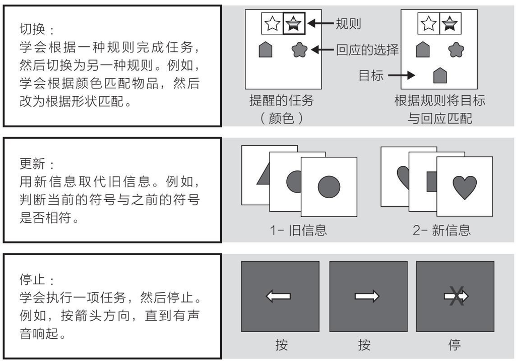

图7.2 儿童执行功能测试的例子。Described in Laura E.Engelhardt et al.,“Genes Unite Executive Functions in Childhood,”Psychological Science 26,no.8 (August 1,2015):1151–63,https://doi.org/10.1177/0956797615577209.

综合执行能力有两点让我着迷。首先，它的遗传率几乎是百分之百。 ㊟ 【Laura E.Engelhardt et al.,“Genes Unite Executive Functions in Childhood,”Psychological Science 26,no.8 (August 1,2015):1151–63,https://doi.org/10.1177/0956797615577209.】 也就是说，在一群都在上学的孩子中，我们估计他们之间的综合执行能力差异几乎全都是由他们之间的遗传差异造成的。我们对数百名8—15岁的双胞胎进行了执行功能测试，在纠正了测量误差（由于随机性，测试的分数有轻微变化的趋势）之后，发现同卵双胞胎的综合执行能力基本上完全一样。异卵双胞胎的综合执行能力的相关度为0.5，他们共享一半的遗传差异，所以他们彼此之间的相似度为同卵双胞胎的一半。对任何行为特征（尤其是在儿童时期测量的行为特征）来说，近乎完美的遗传率是罕见的。综合执行能力的遗传率与眼睛的颜色或身高的遗传率相当，比身体质量指数或青春发育时相(pubertal timing)的遗传率更高。 ㊟ 【对双生子研究的一个常见批评是，它可能低估了同一家庭的孩子所共有的环境因素对其生活结果差异的贡献程度，因为研究没有包括足够多的来自弱势背景的家庭。请记住，遗传率是一个比例，样本中的环境差异越多，分母就越大，遗传率就越小。但就得克萨斯双生子项目(Texas Twin Project)而言，我们的样本确实代表了广泛的环境逆境条件：三分之一的参与家庭在孩子出生后接受过某种公共援助（如SNAP，即帮助购买食物）。我们还计算了我们的样本的基尼指数（衡量收入不平等的指标），结果为0.35，而整个美国的基尼指数为0.39，这表明，特别是考虑到我们样本的地理限制，我们比较合理地捕捉到了美国社会中更广泛的收入不平等模式。我们样本的构成很重要，因为它意味着我们不会因为只抽到来自富裕程度类似的背景的孩子就看到EF的高遗传性。更重要的是，由心理学家纳奥米·弗里德曼在科罗拉多州领导的一个独立实验室发现了完全相同的结果，即完美的遗传性，而其所用的双胞胎样本在接受测试时年龄较大。Naomi P.Friedman et al.,“Individual Differences in Executive Functions Are Almost Entirely Genetic in Origin,”Journal of Experimental Psychology:General 137,no.2 (May 2008):201–25,https://doi.org/10.1037/0096-3445.137.2.201.】

其次，这种几乎完全可遗传的特质，对学生在州政府规定的学业成绩测试中的表现有着惊人的预测作用。与美国各地的公立学校学生一样，得克萨斯州的学生从三年级开始，在学年结束时必须参加数学和阅读技能的标准化测试。我们收到了参加我们研究的孩子的成绩单，所以我们可以看到他们在执行功能测试中的表现能否预测他们在学校进行的高利害测试中的表现。结果是确实如此：综合执行能力与学生的考试成绩有0.4—0.5的相关性。

这只是一项研究，但它说明了一个更普遍的模式。长期以来，双生子研究已经发现了遗传对基本认知能力有影响的证据。 ㊟ 【Elliot M.Tucker-Drob and Daniel A.Briley,“Continuity of Genetic and Environmental In.uences on Cognition across the Life Span:A Meta-Analysis of Longitudinal Twin and Adoption Studies,”Psychological Bulletin 140,no.4 (July 2014):949–79,https://doi.org/10.1037/a0035893.】 这些能力通常是在高度控制的实验室环境中测量的，反过来又能预测受试者在各种测试中的表现，如州政府规定的小学成绩测试，以及进入大学和研究生院的入学测试。

这一模式在使用多基因指数而不是双生子来研究遗传影响的研究中也很明显。正如我在上一节所述，如果我们对成年后的受教育程度进行GWAS研究，然后用该GWAS的结果创建一个多基因指数，那么该多基因指数也与儿童在5岁时的智商测试成绩相关。教育多基因指数还与儿童10岁时的阅读能力、13岁时的智商分数以及17岁时的大学入学考试分数相关。

在正规教育的每一个阶段，能够快速记忆事实、轻松地调整注意力，并在头脑中操作抽象信息的人，在考试中的表现更好。一个人是否在考试中表现良好，是他能否进入学校教育下一阶段的主要因素。

#### 再谈“什么”的问题：遗传效应不仅仅涉及智力

正如陀思妥耶夫斯基提醒我们的，“要想明智地行动，需要的不仅仅是智慧”。 ㊟ 【Fyodor Dostoyevsky,Crime and Punishment,translated by Richard Pevear and Larissa Volokhonsky (New York:Alfred A.Knopf,1991).】 记者保罗·图赫在他的畅销书《性格的力量：勇气、好奇心、乐观精神与孩子的未来》中提出，之所以“有些孩子成功，有些孩子失败”，是因为成功的孩子拥有某些特定的“性格”特征，如“毅力、好奇心、自觉性、乐观和自制力”。 ㊟ 【Paul Tough,How Children Succeed:Grit,Curiosity,and the Hidden Power of Character (Houghton Mifflin Harcourt,2012),https://www.amazon.com/How-Children-Succeed-Curiosity-Character/dp/0544104404.】 诺贝尔奖得主詹姆斯·赫克曼给出了一个类似的清单：“积极性、毅力和韧性，对人生的成功也很重要。” ㊟ 【James J.Heckman,“Skill Formation and the Economics of Investing in Disadvantaged Children,”Science 312,no.5782 (June 30,2006):1900–1902,https://doi.org/10.1126/science.1128898.】 这一系列特质通常被称为社会情感技能，或被更广泛地称为“非认知”技能。

“非认知”这个标签其实是用词不当：行为控制和人际交往能力显然是基于大脑的、对认知有很高要求的表型。但“非认知”中的“非”是为了强调这些动机、行为和情感特征不是什么：它们不是认知能力或学术成就标准化测试成绩的同义词。

《性格的力量》和安吉拉·达克沃思的《坚毅：释放激情与坚持的力量》等书（这两本书都登上了《纽约时报》畅销书榜），以及一些TED演讲，如卡罗尔·德韦克博士关于思维模式的TED演讲（观看次数超过1200万次），大大普及了关于非认知技能的心理学研究。 ㊟ 【Carol Dweck,The Power of Believing That You Can Improve,TEDx Norrkoping,November 2014,https://www.ted.com/talks/carol_dweck_the_power_of_believing_that_you_can_improve.】 随着“坚毅”(grit)和“成长型思维模式”(growth mindset)等词成为流行语，关于遗传在人的发展中的作用的猜测急速增多，比科研发展的速度更快，许多评论家迅速将这些技能与遗传相对立。例如，图赫写道：“对年轻人的成功非常重要的性格优势”并不是“好运气或好基因的结果”。 ㊟ 【Tough,How Children Succeed.】 同样，乔纳·莱勒（他现在已经因为抄袭和捏造而名誉扫地）为《连线》杂志写了一篇关于“坚毅的重要性”的文章，将坚毅描绘成与遗传影响相抗衡的重要因素。“天赋的内在性被高估了，我们的基因并没有赋予我们特定的天赋……天赋其实就是勤奋地练习。” ㊟ 【Jonah Lehrer,“Which Traits Predict Success?(The Importance of Grit),”Wired,March 14,2011,https://www.wired.com/2011/03/what-is-success-true-grit/.】 我推测，公众对非认知能力之所以如此热情，部分原因是它们被认为不受遗传因素的影响，而遗传因素又困扰着关于认知能力的讨论。但“非认知能力不受遗传影响”的假设是不正确的。有三条证据表明，非认知能力的发展是连接基因和教育结果的路径的一部分。

首先，我们可以研究双胞胎的非认知技能。我在得克萨斯州参与指导的双生子研究，设计了一套测量方法，试图捕捉被认为对教育和其他方面的成功重要的各种特质（图7.3）。这些特征包括过去几十年社会心理学和教育心理学的“最重要发现”，包括坚毅、成长型思维模式、求知欲、掌握取向(mastery orientation)、自我概念(self-concept)和测试动机(test motivation)。在我们的双胞胎样本中，非认知技能具有适中的遗传率（约60%），这一估计与大多数团队发现的智商的遗传率(50%—80%)一致。

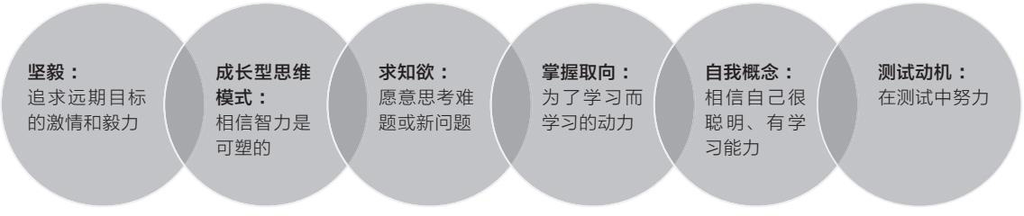

图7.3 不同类型的非认知能力。描述见Elliot M.Tucker-Drob et al.,“Genetically Mediated Associations between Measures of Childhood Character and Academic Achievement,”Journal of Personality and Social Psychology 111,no.5 (2016):790–815,https://doi.org/10.1037/pspp0000098。

第二，研究者从受教育程度GWAS中创建了多基因指数，并观察这些多基因指数在儿童和青少年时期跟哪些表型（而不是认知测试成绩）相关。该研究发现，教育多基因指数与下列因素相关 ㊟ 【Belsky et al.,“Genetic Analysis of Social-Class Mobility in Five Longitudinal Studies”;Belsky et al.,“The Genetics of Success:How SNPs Associated with Educational Attainment Relate to Life Course Development”;Wertz et al.,“Genetics and Crime”;Smith-Woolley et al.,“Di.erences in Exam Performance between Pupils Attending Selective and Non-Selective Schools Mirror the Genetic Differences between Them”;de Zeeuw et al.,“Polygenic Scores Associated with Educational Attainment in Adults Predict Educational Achievement and ADHD Symptoms in Children”;Plomin and Stumm,“The New Genetics of Intelligence”;Allegrini et al.,“Genomic Prediction of Cognitive Traits in Childhood and Adolescence.”】 ：

- 9岁儿童在成人眼中的人际交往能力（“友好、自信、合作或善于沟通”）
- 儿童在11岁时逃学的次数
- 12岁儿童被教师说有多动症的可能性
- 青少年在15岁时，多么渴望有一天能从事地位高的职业，如医学或工程学
- 人们在童年和成年时多么讨人喜欢，对新事物的态度多么开放

研究非认知技能遗传的第三种方法，是研究那些在受教育程度上有差异但在认知能力测试上表现相似的人。这种方法能告诉我们：在从受教育程度中剔除认知能力后，剩下的是什么？我和我的同事借用了这一策略，将其应用于GWAS，测试哪些SNP与人在学校的学习表现（较高的受教育程度）的差异有关，然后剔除这些SNP与认知测试成绩的关系。 ㊟ 【Perline Demange et al.,“Investigating the Genetic Architecture of Noncognitive Skills Using GWAS-by-Subtraction,”Nature Genetics 53 (January 7,2021):35–44,https://doi.org/10.1038/s41588-020-00754-2.】 剩下来的就是一组关于受教育程度的“非认知”差异的GWAS结果。

对这些GWAS结果的一项早期的后续研究，比较了在“非认知技能”多基因指数方面存在差异的兄弟姐妹，发现有证据表明我们的GWAS确实捕捉到了与教育成功有因果关系的基因。 ㊟ 【Perline Demange et al.,“Genetic Associations between Non-Cognitive Skills and Educational Outcomes:The Role of Parental Environment,”BGA 2020,Behavior Genetics Association 50th annual meeting,online,June 25–26,2020,http://bga.org/wp-content/uploads/2020/06/Cheesman_Abstract_BGA2020.pdf.】 此外，我们用这些GWAS结果来计算教育结果与其他多种性状的“遗传相关性”(genetic correlation)。遗传相关性分析使用两个不同性状的GWAS结果，来估计影响每个性状的基因之间的关系强度。 ㊟ 【Brendan Bulik-Sullivan et al.,“An Atlas of Genetic Correlations across Human Diseases and Traits,”Nature Genetics 47,no.11 (November 2015):1236–41,https://doi.org/10.1038/ng.3406.】

我们发现，与更大的教育成就有关的非认知技能的遗传特征，同多种不同类型的事物有关。 ㊟ 【Demange et al.,“Investigating the Genetic Architecture of Non-Cognitive Skills Using GWAS-by-Subtraction.”】 在人格领域，非认知遗传特征与一种叫“经验开放性”(Openness to Experience)的特质关系最密切，这种特质反映了好奇心、学习欲望和对新奇经验的开放性。非认知技能的遗传特征也与延迟满足的能力有关，延迟满足的能力是由人们对较大的、较晚的奖励而不是较小的、立即的奖励的偏好程度来衡量的；非认知技能的遗传特征与较晚的生育有关；总的来讲，也与较少的冒险行为有关。总体而言，我们的研究结果表明，非认知技能确实是一项技能，许多不同的与遗传相关的特征和行为都有助于人们取得更好的学业成果。

也有一些令人惊讶的情况。与非认知技能相关的SNP跟几种精神疾病的高风险相关，包括精神分裂症、双相障碍症、神经性厌食症和强迫症。这一结果警告我们，不要把与“在目前的正规教育体制中取得更好成果”相关的遗传变异看作是固有的“好”东西。一个单一的遗传变异可能会使一个人在学校里取得更好成绩的可能性增加一点点，但同一个变异也可能会增加人患精神分裂症或其他严重精神障碍的风险。

总的来说，这三条研究路线告诉我们，在理解遗传如何影响与不平等相关的特征时，非认知技能并非一张“免罪金牌”，也就是说，非认知技能也受遗传影响。一个人的基因型与一个人的最终受教育程度之所以相关的部分原因是，积极性、好奇心、人际交往能力和毅力这些能使人在学校取得更大成功的特征本身，就受到遗传的影响。

#### “谁”的问题：遗传效应涉及人与人之间的相互作用

正如我在前文所述，遗传效应在生命的早期就很明显了：在受教育程度GWAS中发现的基因早在产前就已获得表达，并与5岁时的智商测试成绩有关。同时，我们还观察到一种可能看起来不直观的模式：遗传对认知能力的影响，随着时间的推移只会越来越强。一项元分析（将大量研究项目的数据汇集起来并加以总结的研究）发现，从出生到儿童期结束（即10岁左右），遗传对认知能力的影响迅速变强。 ㊟ 【Tucker-Drob and Briley,“Continuity of Genetic and Environmental In.uences on Cognition across the Life Span.”】 遗传对个性特征（如有序性和对新经验的开放性）的影响强度也有类似的增加，但持续时间更长，一直到30岁左右。

为什么随着时间的推移，即使儿童积累了越来越多的环境经验，遗传的影响仍然越来越强？理解这个明显悖论的秘诀，是要理解这一点：人与社会环境的互动，是连接遗传同心理和社会结果的因果链的重要组成部分。 ㊟ 【Elliot M.Tucker-Drob,Daniel A.Briley,and K.Paige Harden,“Genetic and Environmental In.uences on Cognition Across Development and Context,”Current Directions in Psychological Science 22,no.5 (October 1,2013):349–55,https://doi.org/10.1177/0963721413485087.】 智力、好奇心、积极性、自律，这些并不是作为一个人的神经系统的“固有”或“天生”的属性在真空中出现的。相反，它们是随着时间的推移而发展的，是儿童与他们生活中的人们之间相互作用的一部分。

在我们关于这个想法的第一项研究中，我们研究了一对4岁的双胞胎儿童和他们的父母的样本。 ㊟ 【Elliot M.Tucker-Drob and K.Paige Harden,“Early Childhood Cognitive Development and Parental Cognitive Stimulation:Evidence for Reciprocal Gene–Environment Transactions,”Developmental Science 15,no.2 (March 2012):250–59,https://doi.org/10.1111/j.1467-7687.2011.01121.x.】 我们通过拍摄父母（通常是母亲）与孩子用两袋玩具进行10分钟的互动，来衡量父母的教养行为。训练有素的评分者被要求对父母的认知刺激(cognitive stimulation)水平打分：父母是否试图教孩子一些能促进他们语言或感知能力发展的东西，以及父母是否以适合孩子发展和跟踪孩子兴趣的方式来做这些事情？

我们发现两个主要结果。首先，在2岁时有更先进的认知功能的孩子，在4岁时从他们的父母那里获得了更多的认知刺激，即使实验者排除(controlling for)了父母以前的教养行为的影响。第二，在孩子2岁时为孩子提供更多认知刺激的父母，其孩子在4岁时有更好的阅读能力，即使实验者排除了他们以前的认知功能水平的影响。这项研究让我们了解到因果链的早期部分：2岁时能够更好地重复声音和对玩具进行分类的孩子，与不会咿呀学语的孩子相比，会得到父母不同的回应。而父母提供的认知刺激，对儿童在4岁时的阅读能力也有影响。那么，在生命早期重复声音的能力方面的最初遗传优势，会通过孩子受到的教养行为的类型，在因果链中向下传递。

另一项使用多基因指数而非双胞胎的研究，考察了幼童家庭环境的几个不同方面，并测试了哪些方面与父母的遗传特征有关，这些遗传特征是通过父母的教育多基因指数来衡量的。 ㊟ 【Jasmin Wertz et al.,“Genetics of Nurture:A Test of the Hypothesis That Parents'Genetics Predict Their Observed Caregiving,”Developmental Psychology 55,no.7 (2019):1461–72,https://doi.org/10.1037/dev0000709.】 访谈者进入家庭，测量父母有多么温暖和亲切，房子有多么安全和整洁，房子有多么混乱和无序，以及父母在认知方面对孩子的刺激程度。其中，只有认知刺激（通过玩具、拼图和书籍的有无和多少，以及通过孩子与父母一起做的活动，如去动物园或博物馆来衡量）同时与父母的遗传特征和孩子最终在学校的发展程度是相关的。

与社会环境互动的重要性并非仅限于儿童发育的早期。我和我的同事做了一项研究，使用了大约3000名美国人样本，他们在1994—1995年是高中生。 ㊟ 【K.Paige Harden et al.,“Genetic Associations with Mathematics Tracking and Persistence in Secondary School,”Npj Science of Learning 5 (February 5,2020):1,https://doi.org/10.1038/s41539-020-0060-2.】 这个样本很有意思，因为受试者既提供了他们的DNA供基因型分型，又给出了他们的高中成绩单，这样研究者就可以看到他们每年都上了哪些课程。结合这些不同的信息来源，我们可以看到，美国高中的分班(tracking)过程可能是连接学生的遗传差异与最终受教育程度差异的因果链的一部分。

开始上高中时，大多数学生对他们要上哪种数学课有选择权。根据一些因素（比如他们在八年级上了哪种数学课，他们对数学的喜欢程度和兴趣有多大，他们的老师和辅导员对他们的评价，他们的父母对进入大学的必要课程的了解程度），学生要么被安排在代数课（美国中学九年级学生最常见的数学课），要么被安排在“初级代数”这样的补习课程，或者学生可以选择几何这样的“高级”课程。

当我为其他学者做关于高中数学成绩的讲座时，我请听众中有在高中学过微积分的人举手。几乎毫无例外，房间里的每个人都会举手。大多数最终获得理工科博士学位的人在高中时都有相当高的数学训练水平。

在美国，我们不会禁止红头发的人上学，但实际上，我们禁止那些在九年级没有学过几何的学生在高中学习微积分，（在美国许多州）我们禁止那些没有完成“代数2”课程的学生从高中毕业或进入重点公立大学。

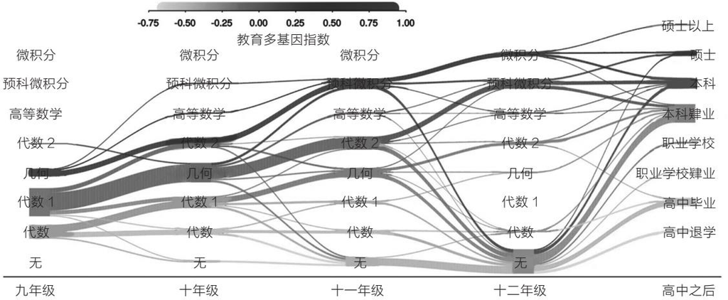

图7.4 按教育多基因指数划分的学生在高中数学课程中的流向。线条的宽度代表高中每一年注册每门数学课程的学生人数。线条的暗度代表注册该课程的学生的平均教育多基因指数。多基因指数的值以标准差为单位。数据出自“全国青少年健康纵向研究”中的欧洲裔学生，他们在1990年代中期在美国高中就读。Reproduced from K.Paige Harden et al.,“Genetic Associations with Mathematics Tracking and Persistencein Secondary School,”Npj Science of Learning 5 (February 5,2020):1–8,https://doi.org/10.1038/s41539-020-0060-2.

图7.4直观地显示了基因在学生选修高中数学课程流向中发挥的作用。从上到下是按难度排序的不同数学课程，从微积分到基础/数学补习班。从左到右是高中四年和学生的最终受教育程度。每年的“河流”的宽度代表遵循该特定课程轨迹的学生的数量。“河流”的颜色深浅代表学生的教育多基因指数。

在图中，我们看到，学生根据一些受遗传影响的特征，被分成了不同的组，每组的学习机会不同，这导致了高中开始时教育的遗传分层(genetic stratification)。对于学习几何的学生来说，多基因“河流”的颜色已经比学习初级代数的学生更深。从那里，我们看到了一个显著的路径依赖，随后学习什么课程取决于之前学习了什么课程。同时，多基因指数低的学生在每一年都更有可能退出数学课程，这导致随着高中学业的进行，遗传分层愈演愈烈。

我们应该重新审视“机制”(mechanism)这个词。当高中毕业生申请大学时，高校看不到他或她的DNA。不过，高校可以看到学生的成绩单，其中给出了关于学生是否已经完成进入大学所需的课程，包括“代数2”的信息。如果分班导致了学生的基因型与积累（或不积累）大学招生办所关注的数学资质相关，那么分班和大学招生就成了基因效应的作用机制。学校将学生分配到不同课程、使学生升学和录取学生的方式，将无形的DNA转化为可见的学术能力证明。

#### 再谈红发儿童

当詹克斯在1970年代首次提出他的红发儿童思想实验时，人们逐渐明白，基因确实对学习成绩、智力、收入、精神病理、健康和福祉有影响，但是，正如他正确指出的，这些遗传效应的可能的传播机制极多。不过，在那之后的五十年里，我们已经幸运地学到了一些东西。数以千计的遗传变异对受教育程度和其他复杂的人类表型有影响。这些基因通过发生在神经元和其他脑细胞中的大体上未知的细胞过程发挥其作用。这些细胞效应在产前发育过程中已经发生，它们对有机体的影响在儿童时期已经很明显，如更出色的早期词汇量、更好的执行功能和更强的非认知技能。在这些技能方面具有较大初始优势的儿童，会得到父母和教育工作者的更好回应：这样的儿童在家里得到更多的认知刺激，在学校得到更具挑战性的课程，这两种情况都会使他们的初始优势得到加强。而这整个过程要经过多年的时间，在重视考试的正规教育体制的背景下进行。

那么，红发儿童的例子暗示的另一个问题——在哪些可能的替代世界里，这些因果链会被打破，而我们会愿意生活在这些可能的替代世界里吗？本书的后半部分会探讨这个问题。

讲到这里，我希望我已经让你相信了三件事。第一，遗传学研究已经开发了一系列的方法，使用家庭成员对比、DNA测序以及两者的组合，来估计基因对人类复杂性状的影响。第二，遗传学研究的压倒性共识是，人与人之间的遗传差异对谁能在正规教育中取得成功有影响，而正规教育的结果对许多其他方面的不平等有影响。第三，虽然这些遗传差异的生物学特性在很大程度上仍然是个谜，但科学界在理解遗传对教育成功产生影响的心理介质和社会介质方面，正在取得进展。现在，让我们把注意力转向如何在政策和教育实践中运用这些洞见，重新审视我们关于优绩主义的迷思。

# 认真对待平等问题

## 第八章

## 其他可能的世界

遗传学研究最终希望回答关于一组可能的替代世界的问题：你是在特定时间和特定地点出生和长大的，但如果你遗传了不同的基因，会怎样？与之相比，我在上一章描述的桑迪·詹克斯关于红发儿童的思想实验，是在问一个不同的问题，关于一组不同的可能世界：如果你的基因型没有变，但社会和历史背景改变了，会怎样？

这不仅仅是一个反问句。1989年柏林墙倒塌时，菲利普·科林格，也就是我们在第三章遇到的那位热爱柠檬鸡的经济学家，才14岁。到当时为止，他的生活都是在东柏林度过的，但在柏林墙倒塌之后，科林格和其他东德学生有机会进入一个全新的教育世界。政府倒台，边界解体，经济变革，法律通过，政策制定者改变主意。社会被重新想象和重新塑造。

自弗朗西斯·高尔顿以来，优生学思想家们一直稳步而成功地进行着误导性宣传，想使人们相信，对社会的重新想象是徒劳的。他们的宣传是这样的：如果人与人之间的遗传差异导致了生活结果的差异，那么社会变革将只能通过编辑人们的基因而不是通过改变社会来实现。这是心理学家阿瑟·詹森在1960年代末写的一篇重磅论文的论点。他问道：“我们能在多大程度上提高智商和学术成就？”他利用早期对学术成就遗传率的研究，给出了非常负面的答案。 ㊟ 【Arthur Jensen,“How Much Can We Boost IQ and Scholastic Achievement?,”Harvard Educational Review 39,no.1 (Winter 1969):1–123,https://doi.org/10.17763/haer.39.1.l3u15956627424k7.】

几十年之后，作家查尔斯·默里继续进行同样的遗传悲观主义(hereditarian pessimism)宣传。他在《人类多样性》一书中提出，“外部干预对个性、能力和社会行为的影响，受到固有的限制”。 ㊟ 【Charles Murray,Human Diversity:The Biology of Gender,Race,and Class (New York:Twelve,2020).】 之所以受到固有的限制，是因为我们的这些方面是受遗传影响的。根据默里的观点，人有一个固有的遗传“设定值”(set point)，在这个设定值周围存在少量由环境引起的抖动(jitter)。默里认为，社会变化有可能影响基因设定值周围的少量变化，但不能改变设定值本身。

这种关于社会变革可能性的遗传悲观主义，实际上是基于对遗传原因和环境干预之间关系的根本误解。正如经济学家阿瑟·戈德伯格在1970年代末所说的，你的遗传导致你的视力不佳，但你的眼镜仍然很好用。 ㊟ 【Arthur S.Goldberger,“Heritability,”Economica 46,no.184 (1979):327–47,https://doi.org/10.2307/2553675.】 也就是说，眼镜不只是有助于解决环境造成的视力不佳。眼镜能帮助改善你的所有屈光问题，无论它是由遗传还是环境造成的。这样一来，眼镜就成为一种外部干预，切断了一个人的近视基因和拥有功能性视力之间的联系。

眼镜的例子对一个更普遍的问题很有启发。有一个“如果”问题是这样的：如果在所有其他条件都相同的情况下，你从父母那里继承了不同的基因组合，会怎样？对这个“如果”问题的回答，并不能直接帮助我们回答另一个“如果”问题：如果你的基因型完全相同，而社会和经济环境发生了变化，会怎样？ ㊟ 【遗传率不能明确说明环境诱导的变化对一个表型是否可能产生影响，但它可能说明环境诱导的变化是否会跨代地、持续地产生影响。回到戈德伯格的眼镜的例子，你的视力可以通过眼镜得到矫正，但是如果你的孩子没有机会获得眼镜，那么你的视力改善就不会持续到你的孩子身上。正如康利和弗莱彻所说：“任何预防或修复［像视力不佳这样的不良结果］的干预措施，都不太可能在下一代产生跨代的回报，因为种系［germ line，即从父母到后代的遗传］中固有的风险没有被改变……如果想让有益的效果持续下去，我们必须不断地为每一代人应用这些解决方案。”Dalton Conley and Jason Fletcher,The Genome Factor:What the Social Genomics Revolution Reveals about Ourselves,Our History,and the Future (Princeton,NJ:Princeton University Press,2017).】 如果科林格继承了不同的遗传变异组合，他获得博士学位的概率会有所不同吗？会。我们从多基因指数的兄弟姐妹对照、双生子研究和测量DNA遗传率的研究中知道这是真的。但是，即使教育结果有遗传原因，如果柏林墙没有倒塌，科林格获得博士学位的概率会不会有所不同？也会。可遗传的表型对社会变革是没有免疫力的。

不幸的是，认为遗传影响是社会变革不可逾越的障碍的错误想法，得到了广泛认可。不仅是那些试图将不平等“自然化”（即认为不平等是自然现象）的人，而且他们在意识形态和政治上的对手也认可这种错误想法。出生于俄国的演化生物学家杜布赞斯基在二战后对斯大林迫害遗传学家的行为敲响了警钟。他在1962年评论了这种很讽刺的现象：“奇怪的是，一些自由主义者接近于同意顽固保守派的这种观点，即如果能证明人们在基因上是多样化的，那么通过社会、经济和教育的改善来改善人们命运的尝试将是徒劳的，甚至可能是‘违背自然’的。” ㊟ 【Theodosius Dobzhansky,“Genetics and Equality:Equality of Opportunity Makes the Genetic Diversity among Men Meaningful,”Science 137,no.3524 (July 13,1962):112–15,https://doi.org/10.1126/science.137.3524.112.】

杜布赞斯基对某些人对遗传学的反应的刻画，仍然具有显著的前瞻性。例如，人类学家阿古斯丁·富恩特斯在为纪录片《危险的想法》所做的采访中概括了这种态度 ㊟ 【Stephanie Welch,A Dangerous Idea:Eugenics,Genetics and the American Dream,documentary (Paragon Media),accessed November 13,2019,http://adangerousidea.lm.com/.】 ：“如果你相信某人成为工业大亨的能力……是以某种方式写在DNA里的，那么你就没有任何责任，一切可以保持原样。”富恩特斯暗示，人们有道德上的责任为一个更平等的社会而努力。因此，他反对社会不平等是“以某种方式写在DNA里”的想法，因为这种想法会妨碍人们对社会变革的倡导和投入。

但这两件事可以同时成立：遗传可能成为社会分层的原因，而对待系统性社会力量的措施，可以有效地推动社会变革。一旦你对这两个真理有了清晰的认识，围绕行为遗传学的很大一部分争议就会消散，留下空间来解决两个更有趣、更复杂的问题。首先，社会和历史环境改变基因型与表型之间关系的方式，与戴眼镜会改善视觉效果有什么不同？第二，展望政策问题，我们希望人们的遗传特征和他们的生活结果之间的关系是什么样子的？这些都是我们在本章要考虑的问题。

#### 向下拉平：当最差的环境产生最平等的结果时

当然，除了科林格和东德的其他孩子之外，还有很多人的教育机会随着苏联解体而改变。爱沙尼亚是一个波罗的海国家，从二战结束到1991年间，爱沙尼亚学生几乎没有自由选择。 ㊟ 【Mikk Titma,Nancy Brandon Tuma,and Kadi Roosma,“Education as a Factor in Intergenerational Mobility in Soviet Society,”European Sociological Review 19,no.3 (July 1,2003):281–97,https://doi.org/10.1093/esr/19.3.281.】 在八年级结束时，他们会被分配到三个学校轨道中的一个，这三个轨道之间很少有流动。完成学业后，学生被分配到工作单位，他们必须在那里工作至少三年。大学学位并不特别受重视，进入大学的竞争也不激烈。

苏联时代结束之后，爱沙尼亚人终于可以在教育和就业方面进行自由选择和竞争。如今，爱沙尼亚人享有经济合作与发展组织(OECD)所称的“高绩效的教育体制”，“将公平与质量相结合”。像其他几个经合组织国家（如芬兰、挪威、韩国和冰岛）一样，爱沙尼亚学生的阅读测试成绩高于平均水平，而且国内学生之间的成绩差异很少是由学生的社会经济背景造成的。 ㊟ 【OECD,Equity and Quality in Education:Supporting Disadvantaged Students and Schools (Paris:OECD Publishing,2012).】

除了发展出高质量且公平的教育体系，爱沙尼亚还拥有世界上最好的国家生物样本库之一。爱沙尼亚基因组中心一直在建设一个关于爱沙尼亚人口的大规模数据库，其中包括关于爱沙尼亚国民的健康和基因的信息。爱沙尼亚生物样本库中的一些人是在苏联时代长大的，也有一些人是在恢复独立之后成年的。因此，在2018年，来自英国的遗传学家提出了这个问题：当社会发生变化时，遗传原因会怎样？

具体来说，英国遗传学家从受教育程度的全基因组关联分析(GWAS)中创建了一个多基因指数，并测试该指数与在苏联时代结束时（即将学生分配到三个中学轨道的制度被废除之前）小于10岁的人的受教育程度的关系。研究发现，与在苏联时代受教育的人相比，教育多基因指数能够明显更多地解释后苏联时代群体的受教育程度差异。当孩子们被分配到几乎不考虑选择或竞争的学校时，他们之间的遗传差异与他们最终的受教育程度的关系更加微弱。

在研究教育多基因指数与美国女性获得更多教育机会的历史变革之间的关系时，类似的结果也很明显。 ㊟ 【Pamela Herd et al.,“Genes,Gender Inequality,and Educational Attainment,”American Sociological Review 84,no.6 (December 1,2019):1069–98,https://doi.org/10.1177/0003122419886550.】 对于我祖母的出生队列（1939—1940年出生的人），教育多基因指数与女性受教育程度的关系，比教育多基因指数与男性受教育程度的关系要弱（在我的母校弗吉尼亚大学于1972年开始不分性别录取学生之前，1939—1940年出生的女性已经三十多岁了）。但随着时间的推移，这种性别差异在缩小：随着女性受教育机会的增加，多基因指数与女性的教育结果有了更紧密的联系。对于我所在的出生队列的女性（1975—1982年出生的人）来说，多基因指数与教育结果的关系，跟男性的一样紧密。具有讽刺意味的是，遗传特征已成为性别平等的标志。

在分析双胞胎数据时，我们发现了相同模式的证据：在允许更多选择和竞争的社会背景下，遗传的关联性更强。挪威的一项早期（1985年）的双生子研究 ㊟ 【A.C.Heath et al.,“Education Policy and the Heritability of Educational Attainment,”Nature 314,no.6013 (April 25,1985):734–36,https://doi.org/10.1038/314734a0.】 发现，较晚出生的队列，特别是受益于扩大高等教育机会的教育改革的男性，其受教育程度的遗传率高于较早出生的队列。

除了比较一个国家不同时期双胞胎的受教育程度遗传率之外，我们还可以比较不同国家的受教育程度遗传率。这些国家的代际社会流动性不同，由父母与子女受教育程度的相关性决定。 ㊟ 【Per Engzell and Felix C.Tropf,“Heritability of Education Rises with Inter-generational Mobility,”Proceedings of the National Academy of Sciences 116,no.51 (November 29,2019):25386–88,https://doi.org/10.1073/pnas.1912998116;Wendy Johnson et al.,“Family Background Buys an Education in Minnesota but Not in Sweden,”Psychological Science 21,no.9 (September 1,2010):1266–73,https://doi.org/10.1177/0956797610379233.】 尽管美国被神化为“充满机遇的土地”，但美国的社会流动性比其他许多国家要低。丹麦是社会流动性高的国家的一个例子。在社会流动性较低的国家，如美国和意大利，受教育程度的遗传率实际上较低。这项研究提醒我们，遗传率是关于差异的，甚至同一家庭的不同成员的遗传特征也是不同的。在一个比较静态的社会里，教育从父母那里复制到孩子那里，几乎没有向上或向下的流动，基因彩票对孩子的生活结果的影响较小。相反，当生活机遇较少取决于家庭的经济和文化资源水平时，基因会产生更多的影响。

最后，双生子研究表明，儿童认知能力的遗传率在出身于贫困家庭的儿童中最低，而在富裕家庭的儿童中最高，特别是在美国，其保护贫困家庭的社会安全网比其他发达国家更弱。 ㊟ 【Elliot M.Tucker-Drob and Timothy C.Bates,“Large Cross-National Di.erences in Gene × Socioeconomic Status Interaction on Intelligence,”Psychological Science 27,no.2 (February 1,2016):138–49,https://doi.org/10.1177/0956797615612727.】 从基因到更好的智力测试成绩的因果链并没有完全断裂，但当儿童的家庭物质资源匮乏时，它被削弱了。

这些研究共同说明了一个向下拉平(leveling down)的过程：当人们因为贫穷、性别歧视或政府压迫而无法继续接受教育时，他们拥有的基因在很大程度上变得无关紧要。基因型和上学之间的因果链取决于是否有学可上。因此，我们经常看到，基因对教育的影响最小的社会背景是最不理想的，因为其中普遍存在剥夺、歧视和/或威权主义的社会管控。

研究结果呈现的这种模式——好环境中的遗传率高于坏环境中的遗传率——可能是反直觉的。但我们可以利用生物学家理查德·陆文顿的一个经典的思想实验来建立一个直观感受。 ㊟ 【Ned Block,“How Heritability Misleads about Race,”The Boston Review 20,no.6 (January 1996):30–35.】 想象一下，有两个花园，其中一个有营养丰富的土壤、明媚的阳光和充足的水，另一个则遍布岩石，黑暗笼罩，土地干枯。现在，这两个花园都播种了不同基因的玉米种子。在资源丰富的花园里，每株植物都有机会达到最大的高度。此外，由于同一花园内所有植株的条件完全相同，所以植株之间的高度差异主要是由于种子之间的遗传差异。

陆文顿的例子经常被用来说明，为什么（正如我在第四章所解释的）即使群体内部的差异是由遗传差异造成的，群体之间（如种族群体）的差异仍然可能完全是由环境因素造成的。 ㊟ 【Block.】 同时，花园的例子也说明了在关于“缩小”学生差距的言辞中往往被忽略的一点 ㊟ 【Stephen J.Ceci and Paul B.Papierno,“The Rhetoric and Reality of Gap Closing:When the 'Have-Nots'Gain but the 'Haves'Gain Even More,”American Psychologist 60,no.2 (2005):149–60,https://doi.org/10.1037/0003-066X.60.2.149.】 ：资源丰富的花园，为所有植株提供相同的环境，植株的平均高度可能更高，但植株在高度上更不平等。同样，消除结构性障碍，如制度化的性别歧视、过于高昂的学费和严格的分班制度，一方面会提高人群的平均教育水平，但另一方面会增加跟人与人的遗传差异有关的教育结果的不平等。

#### 平等与公平

如上文所示，通过观察研究，我们经常看到，在压抑和匮乏的环境中，教育结果的遗传率较低；而在更开放和资源丰富的环境中，教育结果的遗传率较高。基于这种观察，一些科学家提出，高遗传率实际上是好事，它表明恶劣的环境条件得到了改善，也表明社会更尊重个体，所以每个人独特的、受遗传影响的才能和倾向能够体现出来，并影响他们的生活结果。1970年代，理查德·赫恩斯坦在他的《优绩主义中的智商》一书中指出，高遗传率是一个积极的迹象，表明社会已经消除了若干环境不平等的现象：“消除学校中的大班制、糟糕的图书馆、简陋的物质环境、拥挤的贫民区、素质较差的教师、不充足的饮食等……必然会提高遗传率。” ㊟ 【Richard J.Herrnstein,I.Q.in the Meritocracy (Boston:Little,Brown,1973).】 近期，社会科学家道尔顿·康利和詹森·弗莱彻重提这一点，认为高遗传率可以被视为社会中“公平的衡量标准”，是“一个机会平等的乌托邦社会的必要但不充分的组成部分”。 ㊟ 【Conley and Fletcher,The Genome Factor.】

这一观点，即生活结果的高遗传率是乌托邦社会的一个必要组成部分，会让一些读者深感不安。这真的是我们的理想吗：一个“遗传的香格里拉” ㊟ 【Conley and Fletcher.】 ，在那里，贫困和压迫造成的生活结果不平等已经被消除，但遗传造成的生活结果不平等仍然存在？

植根于社会环境的不平等是不可接受的，这是大部分人的共识。那么，为什么与基因有关的不平等就可以接受呢？毕竟，正如我在本书中所论证的，这两者都是出生的意外，是一个人无法控制的运气。

1980年代初，对行为遗传学持激烈批评态度的心理学家里昂·卡明，反驳了这样一种直觉认识，即由基因造成的生活结果的不平等，在道德上比由环境造成的不平等更可接受。他举的例子是苯丙酮尿症(PKU)，这是一种罕见病，由单基因突变引起，损害了人体代谢一种叫苯丙氨酸的蛋白质砌块的能力。如果不加以治疗，PKU会导致智力障碍。而高收入国家现在经常对新生儿进行PKU筛查，通过低苯丙氨酸的限制性饮食来治疗。

用饮食治疗PKU，就像用眼镜应对近视一样，让我们想起了我在本章前面提到的一个观点：遗传原因可以有环境的解决方案。事实上，尽管PKU有一个简单的、已得到充分了解的遗传病因，但在目前，环境解决方案仍然是治疗PKU唯一的办法。PKU的基因疗法（目前）还没有成为现实。 ㊟ 【Hiu Man Grisch-Chan et al.,“State-of-the-Art 2019 on Gene Therapy for Phenylketonuria,”Human Gene Therapy 30,no.10 (October 2019):1274–83,https://doi.org/10.1089/hum.2019.111.】 而且，我们可以将PKU的简单病因与具有高多基因性的结果（如智力测试分数或受教育程度）的遗传结构进行对比，它们涉及成千上万影响微小、机制不明的遗传变异。 ㊟ 【Evan A.Boyle,Yang I.Li,and Jonathan K.Pritchard,“An Expanded View of Complex Traits:From Polygenic to Omnigenic,”Cell 169,no.7 (June 2017):1177–86,https://doi.org/10.1016/j.cell.2017.05.038.】 更加复杂的是，这些变异中有许多同时具有正反两方面的作用，例如，许多与高受教育程度有关的遗传变异，也与精神分裂症的高风险有关。 ㊟ 【V.Bansal et al.,“Genome-Wide Association Study Results for Educational Attainment Aid in Identifying Genetic Heterogeneity of Schizophrenia,”Nature Communications 9,no.1 (August 6,2018):3078,http://dx.doi.org/10.1038/s41467-018-05510-z;Demange et al.,“Investigating the Genetic Architecture of Non-cognitive Skills Using GWAS-by-Subtraction.”】 一些保守派学者建议我们通过编辑儿童的基因组来提高他们的智商，这在科学上不仅是不可行的，也是荒谬的。 ㊟ 【Richard Haier,“No Voice at VOX:Sense and Nonsense about Discussing IQ and Race,”Quillette,June 11,2017,https://quillette.com/2017/06/11/no-voice-vox-sense-nonsense-discussing-iq-race/;Ann Brown,“John McWhorter:Racial Equality May Mean Genetic Editing To Close Racial IQ Gap,”The Moguldom Nation,February 9,2021,https://moguldom.com/335699/john-mcwhorter-racial-equality-may-mean-genetic-editing-to-close-racial-iq-gap/.】

而且，正如卡明指出的，PKU的例子也显示了只关注植根于环境的不平等，而不关注植根于基因的不平等的荒谬性 ㊟ 【Leon J.Kamin,“Commentary,”in Sandra Scarr,Race,Social Class,and Individual Di.erences in IQ (Hillsdale,NJ:Lawrence Erlbaum Associates,1981),482.】 ：

如果家庭对其后代的生活机遇有长期的遗传影响，自由主义者为什么不应该感到不安？“遗传”产生的差异是否比“环境”产生的差异更公正、更美好、更真实？……“遗传”差异是否比“环境”差异更加固定和不可逆转？如果认为我们应该对文化家族性智能不足(cultural-familial retardation)感到不安，同时又愉快地接受由基因决定（但很容易预防）的PKU，那显然是荒谬的。

卡明的反问（“自由主义者为什么不应该感到不安？”）反映了政治哲学家约翰·罗尔斯的论点。罗尔斯指出，如果人们发现源于环境运气的不平等令人不安地不公平，那么人们也可能发现源于遗传运气的不平等同样令人不安 ㊟ 【John Rawls,A Theory of Justice,rev.ed.(Cambridge,MA:Harvard University Press,1999).［本书《正义论》的引文译文借用谢延光先生的译本，上海译文出版社，1991年。个别之处，略有改动。］】 ：

一旦我们在决定分配份额时为社会偶然因素或天然机会的影响而感到苦恼，我们在思考时也不免要为另一种影响而感到苦恼。从道德的观点看，这两种影响似乎是同样毫无道理的。

我们应该为人们无法控制（因此不能说他们应得）的因素造成的不平等而烦恼，这种想法并没有停留在抽象的哲学世界。相反，它已经融入了世界各地的教育政策。让我们考虑一下经合组织是如何定义教育公平的 ㊟ 【OECD,Equity in Education:Breaking Down Barriers to Social Mobility,PISA (Paris:OECD Publishing,2018),https://doi.org/10.1787/9789264073234-en.】 ：

公平并不意味着所有学生都获得同等的教育结果，而是指学生的成果差异与他们的背景或学生无法控制的经济或社会环境无关（强调是我加的）。

这里的逻辑很清楚。来自不同社会阶层的学生之间的任何不平等，都被认为是不公平的，而不公平的原因在于它们是抽彩的运气造成的，学生对其既无选择也无控制。

这种对公平的理解已经深入美国教育工作者的思维中。 ㊟ 【H.Moriah Sokolowski and Daniel Ansari,“Understanding the E.ects of Education through the Lens of Biology,”Npj Science of Learning 3 (October 1,2018):17,https://doi.org/10.1038/s41539-018-0032-y;Carina Omoeva,“Mainstreaming Equity in Education,”issues paper,FHI 360 Education Equity Research Initiative,September 2017,26,http://www.educationequity2030.org/resources-2/2017/10/27/mainstreaming-equity-in-education.】 关于公平(equity)和平等(equality)之间的区别，有一个著名的阐释，即三个身高不同的人，都想从一个棒球场的栅栏上看过去（图8.1）。“平等”意味着他们每个人都得到一个高度完全相同的凳子，导致他们之间的个体差异持续得到表达。而“公平”意味着每个人都得到一个足够高的凳子，使他们能够看到栅栏的另一边，其中最矮的人得到更高的凳子（即更有力的支持）。

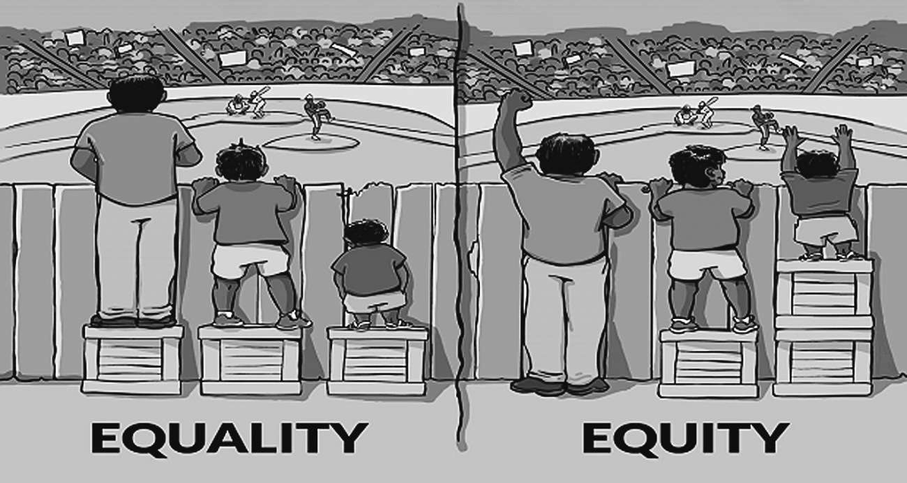

图8.1 平等与公平。图片出自Interaction Institute for Social Change.Artist:AngusMaguire。

因此，我们认为，教育公平不是对每个人都一视同仁，而是给那些最有可能在学习上遇到困难的孩子（无论是由于他们的背景社会条件还是由于“自然的偶然性”）提供有针对性的强化支持，使他们的学习尽可能达到更有优势的同龄人更容易达到的水平。我女儿的学前班教室里有一张彩色招贴画，上面写着：“公平不是每个人都得到同样的东西。公平是每个人都得到他为了成功而需要的东西。”这是5岁孩子也能理解的公平概念。

公平的倡导者反对主导美国政治话语的“机会平等”言论。机会平等实际上可以用多种不同的方式来定义。 ㊟ 【Richard Arneson,“Four Conceptions of Equal Opportunity,”The Economic Journal 128,no.612 (July 1,2018):F152–73,https://doi.org/10.1111/ecoj.12531.】 但最简单明了的定义是，以完全相同的方式对待每个人。当然，问题在于人们在基因和其他方面并不完全相同。为每个人提供完全相同的教育条件的教育体制，将不可避免地产生深刻的结果不平等，就像建造一个1.8米高的栅栏，然后给每个人提供完全相同的15厘米高的脚凳，不管他们的身高如何。

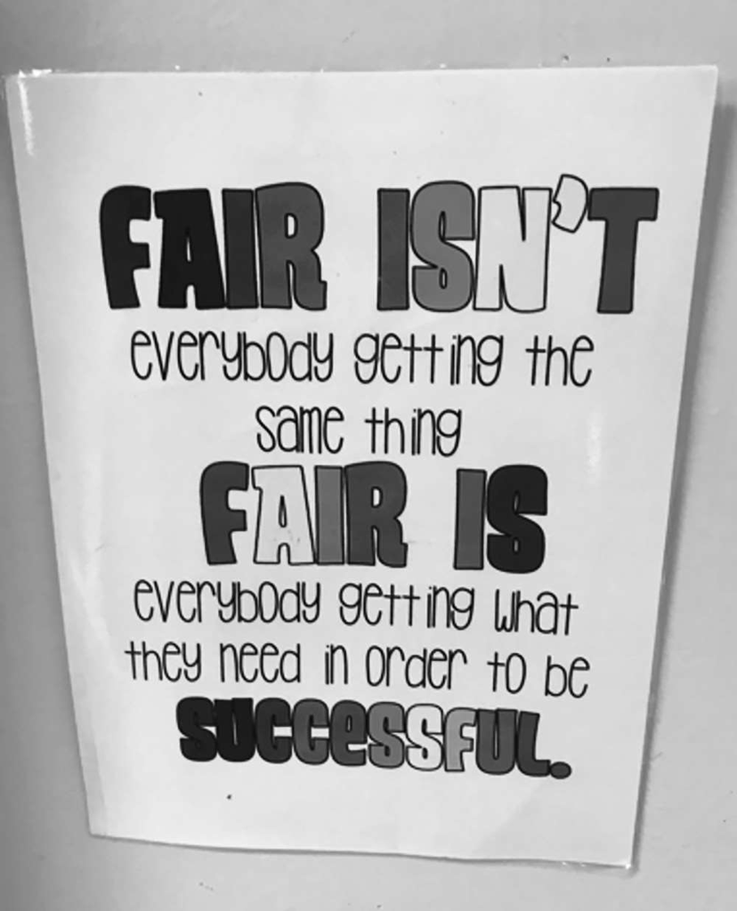

图8.2 学前班教室里关于公平的招贴画。照片由作者提供。

机会平等必然会复制植根于自然随机性的不平等，所以有些人主张放弃对机会平等理念的依恋。哲学家托马斯·内格尔指出：“自由主义的一视同仁观念……必定会反映，也许会扩大由自然或历史造成的差别……人们熟知的一视同仁原则，加上其关于相关差异的‘优绩主义’概念，看来过于软弱，不能与自然制造的不平等作斗争。” ㊟ 【Thomas Nagel,Mortal Questions (Cambridge,UK,New York:Cambridge University Press,1979) .［引文译文借自《人的问题》，万以译，上海译文出版社，2004年，第105页。］】 作家弗雷德里克·德博尔说得更尖锐：“机会平等是一种陈腐的过时观念。它是一种诡计，一种躲避。它是进步人士为不平等提供祝福的一种方式。” ㊟ 【Fredrik deBoer,The Cult of Smart:How Our Broken Education System Perpetuates Social Injustice (New York:All Points Books,2020).】

#### 抬高底线：当干预措施促进了公平

回到戈德伯格的眼镜的例子，我们可以看到，这个思想实验之所以如此影响深远，部分原因在于，眼镜是一种促进公平的干预。拥有良好视力的人并没有获得增强视力的手术来使他们的视力变得更加敏锐。相反，资源被有选择地给予那些视力差的人，使他们的日常视功能尽可能地达到视力好的人享有的水平。

不过，我怀疑戈德伯格的例子之所以经久不衰，也是因为现实生活中可以借鉴的促进公平的行为干预的例子太少了。很少，但并非完全没有。特别是近年来，随着强有力的GWAS创建的多基因评分的出现，我们终于开始看到丰富化的环境的例子，这些环境既改善了平均结果，又缩小了与遗传有关的不平等，使那些最容易出现不良结果的人受益。

举个例子。一项研究考察了20世纪中期英国的一项教育改革对人们健康的影响，该项改革规定：1957年9月1日或之后出生的每个人都必须在学校待到他们年满16周岁，不准提前退学。 ㊟ 【Silvia H.Barcellos,Leandro S.Carvalho,and Patrick Turley,“Education Can Reduce Health Di.erences Related to Genetic Risk of Obesity,”Proceedings of the National Academy of Sciences 115,no.42 (October 16,2018):E9765–72,https://doi.org/10.1073/pnas.1802909115.】 在这个截止日期之前出生的人，与在这个截止日期之后出生的人不会有任何系统性的差异。那么，生日就构成了一种自然实验的基础，测试政府强迫人们在学校多待一年的效果。

平均而言，额外的教育年限改善了人们的健康：经历此项教育改革的人在成年后的身体质量指数更小，肺功能更好。但并不是每个人的反应都一样。此项改革对那些具有最高的超重遗传倾向（以肥胖症GWAS的多基因指数衡量）的人的影响最大。因为教育改革对风险最大的人影响最大，所以改革减少了与遗传有关的不平等。在没有经历过此项改革的人当中，具有最高遗传风险的三分之一的人，与具有最低遗传风险的人相比，超重或肥胖的风险要高20%。改革之后，这一差距缩小到只有6%。

另一个例子是一个名为“家庭检查”(Family Check-Up)的干预项目，该项目向青少年的父母传授所谓的“家庭管理”策略：如何监测青少年的朋友和行踪而又不过分干涉，如何设定合理的限制（如宵禁）并予以执行。 ㊟ 【Sally I-Chun Kuo et al.,“The Family Check-up Intervention Moderates Polygenic Influences on Long-Term Alcohol Outcomes:Results from a Randomized Intervention Trial,”Prevention Science 20,no.7 (October 2019):975–85,https://doi.org/10.1007/s11121-019-01024-2.】 美国的一项随机对照试验将接受“家庭检查”干预的家庭与对照组进行了比较，结果发现，平均而言，干预措施减少了青少年饮酒现象和随后出现的酗酒问题。一项后续研究引入了遗传数据，使用从酒精依赖的GWAS中创建的多基因指数。在对照组中，多基因指数和酗酒问题之间的联系跟我们根据原始GWAS所期望的结果相符：平均而言，多基因指数较高的人有更多的酗酒问题。但在那些家庭接受干预的人中，遗传效应被关闭了：遗传风险和酗酒问题之间没有关联。

最后，我们在研究“美国高中数学分班与结果的多基因关联”时（见上一章），看到了类似的抬高底线的模式。总的来说，多基因指数更高的学生学习数学的平均年限更长（这项研究使用了1990年代中期的数据，当时美国大多数州只要求高中生学习两到三年的数学）。但是，来自优势高中（那里有更多家长拥有大学文凭）的学生，即使他们的多基因指数较低，也不会从数学课程中半途而废。

目前我们还不清楚这是为什么。也许是因为优势高中可以为有学习困难的学生提供额外的辅导或指导，或者可能仅仅是因为在家长受过大学教育的家庭中存在强烈的社会规范，即期望学生参加什么类型的数学课。但是两个多基因指数相当的学生会根据他们的学校环境不同而显示出不同的结果，特别是如果他们的多基因指数很低的话。

这三个例子说明了一个更普遍的问题：公平(equity)和质量(quality)并不总是对立的。在所有这三个例子中，正向的环境改变，不成比例地改善了那些具有最高遗传风险（肥胖、酗酒、从数学课程中半途而废）的人的结果，因此使不同基因型的人的结果变得更均衡。

#### 当富人变得更富有，穷人被抛下

不过，促进公平的结果并不是必然的。干预措施可能成功，因为它们平均而言改善了结果，但同时它们也可能加剧人们之间的遗传差异。例如，自1960年代以来，政府对香烟和其他烟草产品征税，已成功地将烟草消费量减半。但是健康经济学家詹森·弗莱彻和其他人提出，征税对于劝阻那些在遗传上香烟成瘾风险最小的人吸烟最为有效。 ㊟ 【Jason M.Fletcher,“Why Have Tobacco Control Policies Stalled?Using Genetic Moderation to Examine Policy Impacts,”PLOS ONE 7,no.12 (December 5,2012):e50576,https://doi.org/10.1371/journal.pone.0050576】 相比之下，那些在遗传上成瘾风险最大的人却越来越被抛在后面，继续在吸烟的灾难性健康后果（和惩罚性的经济成本）中挣扎。 ㊟ 【Jason D.Boardman et al.,“Population Composition,Public Policy,and the Genetics of Smoking,”Demography 48,no.4 (November 2011):1517–33,https://doi.org/10.1007/s13524-011-0057-9;Benjamin W.Domingue et al.,“Cohort E.ects in the Genetic In.uence on Smoking,”Behavior Genetics 46,no.1 (January 2016):31–42,https://doi.org/10.1007/s10519-015-9731-9.】

这种情况，即原本就处于有利地位的人从政策或干预措施中受益最多，被称为马太效应。耶稣在《马太福音》（第25章第29节）中说：“因为凡有的，还要加给他，叫他有余。没有的，连他所有的，也要夺过来。”教育研究者研究了马太效应与儿童考试成绩或其社会经济地位等因素的关系，发现马太效应虽然并非不可避免，但当干预措施或计划可供所有人使用时，马太效应也是普遍存在的。 ㊟ 【Ceci and Papierno,“The Rhetoric and Reality of Gap Closing.”】 例如，暑期学校计划往往使中产阶级家庭的孩子比贫困家庭的孩子受益更多。 ㊟ 【Harris Cooper et al.,“Making the Most of Summer School:A Meta-Analytic and Narrative Review,”Monographs of the Society for Research in Child Development 65,no.1 (February 2000):i–127;Thomas D.Cook et al.,Sesame Street Revisited (New York:Russell Sage Foundation,1975).】

#### 谁在受益？呼吁提高透明度

在本章中，到目前为止，我们讨论了社会可能不同于当前状况的三种路径。第一，社会可以变得更加具有压迫性和贫穷，通过将每个人向下拉平来减少结果的不平等。第二，社会可以通过对那些在遗传上最有可能出现不良结果的人进行有针对性的投入，来最大限度地减少结果的不平等。或者，第三，社会可以实施干预措施和计划，最大限度地提高那些原本就处于有利地位的人的成果，但不能提高（或不能大幅提高）其他人的成果。

第一个可能的替代世界使每个人的情况都变差，没有人的情况变好，这显然是不可取的。但在另外两种替代世界中如何选择，可能就不那么明确了。

在图8.3中，我解释了这两种替代的环境。对于每一种选择，都有一个跨个体的可能结果分布，但这些分布不仅在平均值上有差异，而且在其范围（即不平等的程度）上也有差异。该图还指出了两个拥有不同基因的假设个体的结果：基因型A（圆形）与B（三角形）。具有某种基因型的个体的预期表型结果在不同的环境中如何变化，被称为反应规范(reaction norm)。 ㊟ 【Anthony J.F.Gri.ths et al.,“Norm of Reaction and Phenotypic Distribution,”in An Introduction to Genetic Analysis,7th ed.,ed.Anthony J.F.Gri.ths et al.(New York:W.H.Freeman,2000),http://www.ncbi.nlm.nih.gov/books/NBK22080/.】

反应规范发生转变的概念，突出了一个不同的问题，即个人与同一社会中的其他人有什么不同。与其说是人与人之间的比较，不如说是回到了我在本章开始时强调的“如果”问题：如果你的基因型完全相同，但社会环境发生了变化，会怎样？换句话说，我们现在是将每个人与他们自己在不同的可能世界中的情况进行比较，而不是在同一个世界中比较不同的人。以这种方式考虑，突出的问题不是哪个世界使儿童之间的结果不平等最小化，而是哪个世界使个人的结果最大化。

但是，我们应该优先考虑谁的成果？例如，考虑到一所学校正在采用新的数学课程，并在两个方案中做出选择。a或b哪一个更可取？

(a)新课程对那些在遗传上最有“风险”的儿童特别有帮助，从而减少那些碰巧继承或没有继承特定遗传变异组合的儿童之间的教育结果差距。

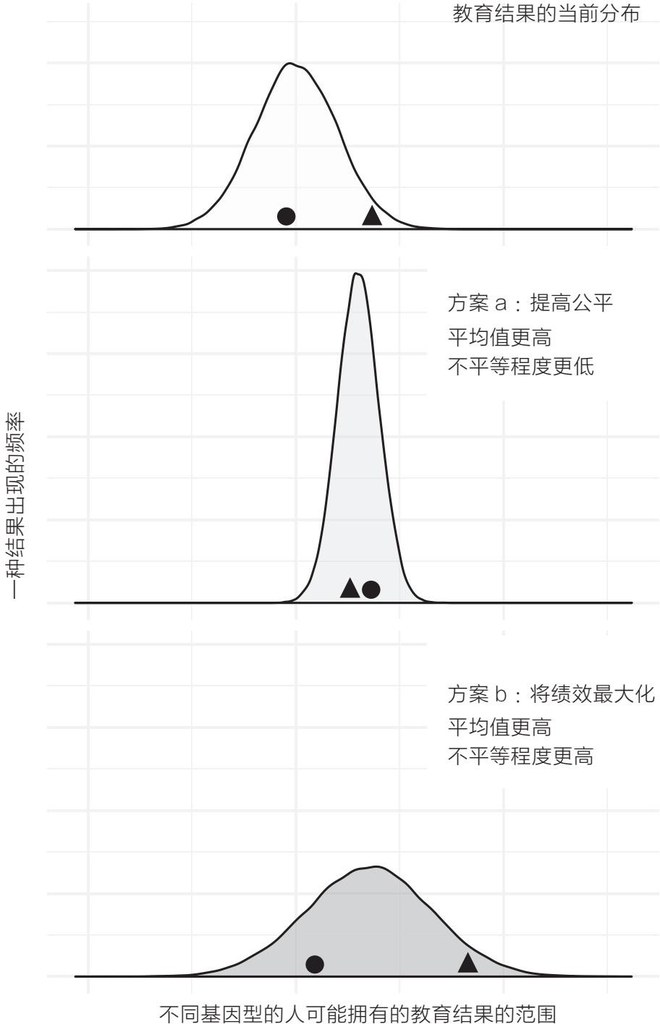

图8.3 不同基因型的人在不同环境中的教育结果分布。圆圈和三角形代表两个具有不同基因型的假设个体。相对于目前的情况，促进公平的环境（方案a）改善了圆圈所代表的个体的受教育程度，但对三角形代表的个体来说差别不大，从而减小了结果的不平等。相比之下，绩效最大化的环境（方案b）改善了三角形代表的个体的教育结果，但没有改善圆形代表的个体的教育结果，因此增加了他们之间的不平等。在两个备选方案中，方案b取得了更高的个体结果。

(b)新课程对那些无论如何都最有可能成功的儿童特别有帮助，从而使少数学生获得更高水平的数学技能。

讲求理性的人可以为a和b提出各种经验论据。例如，我们可以进行各种成本效益分析：a与b相比，有多少学生得到了帮助？一套新的课程对每个学生来说要花费多少钱？一个社会中有更多的人拥有某种基线水平的数学技能，与一个社会中有更多的人拥有非常高的数学技能，其（在经济生产力、技术创新、社会凝聚力、政治参与等方面的）下游影响(downstream impact)是什么？

除了这些经验问题之外，这种选择还涉及人们的价值观问题，包括人们是把教育结果的平等作为目的，认为平等本身就是一件好事；还是仅仅把平等作为实现其他目标（如经济成果的平等）的一种手段。

不过，目前，政策制定者和教育工作者不必对这些价值观保持透明，也不必面对相关政策或干预措施的实现效果是否符合这些价值观的证据。在教育和政策研究中，人们之间的遗传差异在很大程度上是不可见的，因为研究者甚至没有尝试去测量人们的任何遗传信息。在研究教育成就或心理健康时，关于基因与干预的相互作用的高质量研究，如显示英国的一项教育改革如何特别有利于肥胖症高风险人群的研究，是非常罕见的。 ㊟ 【大多数关于基因×干预效应或基因×环境效应的研究，都使用了不良的基因型测量方法（例如，研究单一遗传变异的影响），或者使用了本身与人们的遗传差异相关的环境背景的测量方法。相比之下，少数做得好的研究有很好的基因型测量方法（如从强有力的GWAS中创建的多基因指数），并使用准实验设计来研究环境，从而更好地推断出环境影响的因果关系。Lauren Schmitz and Dalton Conley,“Modeling Gene-Environment Interactions With Quasi-Natural Experiments,”Journal of Personality 85,no.1 (2017):10–21,https://doi.org/10.1111/jopy.12227.】

根据我跟正在开发和测试干预措施的科学家探讨的经验，他们往往不愿意在他们的研究中加入遗传信息。他们有一些务实的反对意见：“会不会很贵？要求提供DNA信息会不会降低参与度？我必须在现场准备一个低温冰箱吗？”（答案是：不贵，不会降低参与度，不需要。基因型分型可以相对便宜地完成，每个人的费用不到75美元。正如直接面向消费者的基因型分型公司的成功所证明的，人们可能对参与遗传学研究相当好奇和热心。而且唾液样本可以在室温下储存数月，甚至数年。）

不过，在这些务实的反对意见之下，潜藏着更深层次的恐惧：在教育或心理健康结果的研究中，单单是采集DNA样本这种行为本身，就牵涉到优生学意识形态，这让不情愿的研究者感到厌恶，因为他们认为运用遗传信息的风险总是大于好处。当然，研究者在这一点上是正确的，即基因信息确实有可能被滥用，例如使用多基因指数来选拔个别学生到竞争激烈的学术职位上。我将在第十二章中讨论这些滥用，以及它们的反优生主义的替代方案。

但是，就像鸵鸟把头埋在沙子里一样，对遗传数据视而不见并不能使遗传差异消失。如果一项干预措施会使那些在遗传上最有可能获得不良受教育结果的儿童更加落后，那么无论研究者是否观察到这种促进不平等的效果，它都是客观存在的。而如果我们忽视遗传信息，我们就失去了一件有用的工具，无法看到谁从现有的干预措施中受益，谁又没有受益。

#### 什么的公平？不要忘了长因果链

关于教育干预措施或政策能否促进公平，以及是否应该促进公平的问题，具有额外的意义，因为人们在受教育程度上的差异与许多其他形式的不平等密切相关。特别是在美国，拥有和不拥有大学学历的人在收入、财富、身体健康和心理健康方面的差距很大，而且越来越大（见第一章）。很多时候，通过增加读完大学的人数，使大学学历不再依赖于一个人的出身条件（无论是遗传条件还是社会经济条件），从而提升教育结果的公平，被描绘成解决人们生活中更广泛不平等的唯一可能手段。

但是，缩小教育结果方面的差距，并不是我们解决没有受过大学教育的美国人面临的经济和健康危机的唯一途径。当然，我相信教育本身是一种值得追求的好东西，为更多人提供真正的机会花几年时间学习艺术、文学、科学或哲学，将丰富他们的生活。但是，我们可以坚持认为教育是人们需要获得的好东西，但同时不迷信高等教育是获得健康、安全和美满生活的唯一可接受的途径。正如经济学家安妮·凯斯和安格斯·迪顿所写：“我们不接受这样的基本前提，即人们如果没有学士学位就对经济毫无价值。我们当然也不认为，那些没有获得学位的人应该受到某种程度的不尊重，或被视为二等公民。” ㊟ 【Anne Case and Angus Deaton,Deaths of Despair and the Future of Capitalism (Princeton,NJ:Princeton University Press,2020),https://press.princeton .edu/books/hardcover/9780691190785/deaths-of-despair-and-the-future-of-capitalism.】

正如我在本章开头描述的，一个多世纪以来，优生学思想家的典型立场就是从遗传学的角度对通过社会政策进行社会变革的前景持悲观态度。这种悲观主义产生于一种有缺陷的遗传决定论，它想象人们的特征（认知、个性和行为）都不可避免地被DNA所固定。正如我在本章描述的大量研究表明的，遗传决定论是错误的，但遗传决定论并不是唯一需要根除的错误。优生主义者对通过社会政策进行社会变革的前景所持的遗传悲观主义，也来自一种有缺陷的经济决定论，它想象那些在教育方面不成功的人必然被置于糟糕的工作、低工资和糟糕的医疗保健（或根本没有医疗保健）当中。

不过，我们不必看得很远，就能想象出安排社会的不同方式。例如，凯斯和迪顿认为，没有受过大学教育的美国人的贫困化，大部分责任可以归于我们过分昂贵的医疗保健体制，这个体制是高收入国家中的异类。 ㊟ 【Case and Deaton.】 我在本书第一部分中提出，人与人之间的遗传差异会导致他们在社会和行为结果上的差异。但我们必须从一个漫长而复杂的因果链来理解基因的因果关系，这个因果链跨越了多个分析层次，从分子的运动到社会的行动。这个因果链的长度和复杂性意味着，有多种机会来干预基因型和复杂表型之间的联系。改革医疗保健系统，使“低技能”工人的工资不被雇主提供的医疗保险的高额费用所拖累，不会改变人们的DNA，但它可能会削弱连接遗传差异和收入差异的漫长因果链中的一个环节。

此外，我们对公平的相对重视程度，在因果链的不同环节会有所不同。例如，人们可能很容易得出结论，使用基因编辑来平衡人们的DNA序列本身的努力，其侵入性、经济成本和负面结果的风险是非常可怕的。人们可能会认为，与其在人们获得理工科博士学位的可能性方面实现平等，不如最大限度地提高少数具有高度数学兴趣和能力的人的生产力，即使这些兴趣和能力是“赢得”社会彩票或自然彩票的产物。不过，人们也可能认为，在获得清洁的水、营养食品以及医疗保健和免于身体疼痛方面使人们平等，而不管他们的教育水平如何，是非常重要的。连接基因彩票和社会不平等的漫长因果链意味着，关于公平的决定（关于我们希望世界是什么样子）必须在因果链的每个环节做出。

#### 憧憬一个不同的人类社会

有这样一种观念，成为许多人接受生物学和社会行为之间联系的巨大障碍之一：生物学对进步的社会变革的可能性划定了一条硬性的界线(hard stop)。很多人会这么想，并非偶然。正如我在本章开头所讨论的，政治极端分子在过去一个世纪的大部分时间里都宣称这是真的。他们的推理是，如果某种特征是可遗传的，它就无法改变；因此，试图改变它，或者想象“一个非常不同的人类社会”（哲学家彼得·辛格语），是没有意义的。 ㊟ 【Peter Singer,A Darwinian Left:Politics,Evolution,and Cooperation (New Haven,CT:Yale University Press,2000).】 在本书中，我已经开始描述为什么遗传原因不是社会变革的敌人。但是，承认遗传原因的重要性和接受使用遗传学研究工具，还有别的平等主义的理由。

## 第九章

## 用先天来理解后天

我在上一章提出，社会不平等现象有遗传原因，并不意味着社会就不能变革了。相反，我们可以找到大量的证据，证明环境变化（从苏联解体这样的全面政治变化，到家庭辅导这样私密的个体变化）可以改变人们的DNA和生活结果之间的关系。将遗传特征与社会不平等联系起来的长长的因果链可能会使科学家感到沮丧，他们必须与它往往令人困惑的复杂性作斗争，但它为父母或决策者提供了许多不同的干预机会。

鉴于遗传影响并不是社会变革可能性的硬性上限(hard upper bound)，我们可能很容易得出结论，那些对社会变革感兴趣的人可以安全地忽略遗传。我的许多学术同行就认为，行为遗传学领域往好了说，与他们的工作无关，往坏了说，则是对寻找社会现象的社会原因的一种有害的干扰。但这么想就错了。在本章中，我将解释为什么遗传学远不是改善人类生活的敌人，亦不会干扰改善人类生活的努力；事实上，遗传学是我们的一个重要盟友，如果放弃它，我们就会付出巨大的代价。

#### 我们并非已经知道该怎么做

生物伦理学家埃里克·帕伦斯在《科学美国人》中哀叹用于遗传学的研究资金数量太多。这反映了一种错误的想法，即认为遗传学只会干扰人们对社会不平等的“真正”原因的理解。帕伦斯写道：“我们继续在遗传学上投入过多的期望……遗传学工具……不会减少，更不会消除由不公正的社会条件产生的健康差异。” ㊟ 【Erik Parens,“The Inflated Promise of Genomic Medicine,”Scientific American Blog Network,June 1,2020,https://blogs.scienti.camerican.com/observations/the-in.ated-promise-of-genomic-medicine/.】

那些像帕伦斯一样认为“遗传学过度干扰了应对决定不平等的社会因素”的人经常断言，遗传学的见解和工具是不必要的，因为我们已经知道该如何解决教育、健康和财富方面的不平等。例如，教育家约翰·华纳在《高等教育内幕》中对我的著作做了回应，认为基因数据不仅会分散人们的注意力，而且很危险。 ㊟ 【“Why We Shouldn't Embrace the Genetics of Education,”Just Visiting (blog),Inside Higher Ed,July 26,2018,https://www.insidehighered.com/blogs/just-visiting/why-we-shouldnt-embrace-genetics-education.】 华纳写道：“我们对儿童在什么样的环境里学习最好已经非常了解了，胜过我们对其他任何主题的了解……我们知道该为学生做些什么……这并不神秘。”

在华纳论点的基础上，社会学家鲁哈·本杰明在她的《技术之后的种族》一书中也提出了同样的抗议， ㊟ 【Ruha Benjamin,Race After Technology:Abolitionist Tools for the New Jim Code (Cambridge,UK,and Medford,MA:Polity Press,2019).】 认为那些想改善儿童生活的人面临的问题“不是缺乏知识”！她继续写道：“我们做不到的，不是掌握事实，而是坚定地投身于正义的事业。”在她看来，希望将新的数据来源纳入环境研究的遗传学研究者正在参与“非正义的数据化(datafication of injustice)，换句话说就是，对越来越多数据的猎取妨碍了我们根据已有知识采取行动”。

读了这样的断言，读者可能会想象，已经有大量的政策和干预措施被证明可以有效地解决教育和健康方面的社会不平等问题，而只要我们集中足够的政治意愿，这些政策和干预措施就随时可以落实。但实际上，教育、行为干预和社会政策领域的专家一再提醒我们，通常情况下，改善人们生活的善意努力根本无法带来任何改变，有时还会适得其反。

在教育界，只要浏览一下“有效教育策略资料中心”(What Works Clearinghouse)，我们就会发现成功的干预研究是多么稀缺。 ㊟ 【“WWC | Find What Works!,”accessed November 11,2019,https://ies.ed.gov/ncee/wwc/.】 该中心是由美国教育部的研究和评估部门——教育科学研究院(IES)组织和管理的资源。IES对多项随机对照试验(RCT)进行检查，得出的结论是：“在IES的这些研究中发现的一个明显的模式是，与通常的学校做法相比，绝大多数被评估的干预措施仅产生了微弱的效果，或没有积极的效果。” ㊟ 【“Randomized Controlled Trials Commissioned by the Institute of Education Sciences Since 2002:How Many Found Positive versus Weak or No Effects,”Coalition for Evidence-Based Policy,July 2013,http://coalition4evidence.org/wp-content/uploads/2013/06/IES-Commissioned-RCTs-positive-vs-weak-or-null-.ndings-7-2013.pdf.】 同样，2019年对美国和英国的141项RCT的检查发现，其平均效应值(effect size)不到1个标准差的十分之一(0.06SDs)。考虑到这一记录，这份IES报告的作者提出了一个可能的解释：“这些教育干预措施所依据的基础研究是不可靠的……基于从不可靠的基础研究中获得的见解的干预措施，即使经过了精心设计、成功实施和适当试验，也不太可能有效。” ㊟ 【Hugues Lortie-Forgues and Matthew Inglis,“Rigorous Large-Scale Educational RCTs Are Often Uninformative:Should We Be Concerned?”Educational Researcher 48,no.3 (April 1,2019):158–66,https://doi.org/10.3102/0013189X19832850.】

同样，致力于为社会问题寻找“循证的解决方案”的慈善组织“劳拉和约翰·阿诺德基金会”（现为阿诺德风险投资公司）的一份报告总结道：“研究发现了若干真正有效的干预措施……但这些是测试了大量方案之后出现的例外。大多数，包括那些被最初的研究认为有潜力的方案，都只产生了很小的效果，或没有效果。” ㊟ 【“Statement of Jon Baron,Vice-President of Evidence-Based Policy,Laura and John Arnold Foundation,”House Committee on Agriculture,Subcommittee on Nutrition,July 15,2015.】 干预研究者，也是我在得克萨斯大学的同事大卫·耶格尔这样说道：“几乎所有过去的高中项目——辅导项目、学校重新设计等——都没有显示出对客观结果的明显改善。” ㊟ 【David S.Yeager et al.,“Where and For Whom Can a Brief,Scalable Mindset Intervention Improve Adolescents'Educational Trajectories?,”preprint,2018,accessed November 11,2019,https://docplayer.net/102132264-Where-and-for-whom-can-a-brief-scalable-mindset-intervention-improve-adolescents-educational-trajectories.html.】

结论是，要么大多数干预措施不起作用，要么甚至没有人研究过它们是否起作用。这个结论不仅限于学习成绩方面。发展心理学家劳伦斯·斯坦伯格审视了一些以学校为基础的干预项目的效果，这些项目旨在减少青少年的酒精和毒品使用、无套性交和其他风险行为。据估计，90%的美国青少年已经被迫参加了至少一个这样的项目。斯坦伯格总结道：“即使是最好的项目，也主要是在改变青少年的知识方面取得成功，而不是改变他们的行为。”他继续指出，失败是有代价的：“大多数纳税人会惊讶地发现，他们的大量资金被投到……没有效果，或者充其量只有未经证实或未经研究的效果的项目中。纳税人有理由对此感到愤怒。” ㊟ 【Laurence Steinberg,“How to Improve the Health of American Adolescents,”Perspectives on Psychological Science 10,no.6 (November 1,2015):711–15,https://doi.org/10.1177/1745691615598510.】

这类结论出自那些真正想为世界带来积极变化的干预主义者，让人汗颜。它们让我们在断言自己已经知道如何改善人们的生活之前三思。它们让我们意识到，知识的缺乏和数据的匮乏确实是问题的一部分。而且，它们提醒我们，了解人类行为，更不用说通过干预改变它，是一个难以解决的问题。

#### 为什么社会科学是最难的科学

心理学家桑贾伊·斯里瓦斯塔瓦有一个名为“最难的科学”(The Hardest Science)的博客。 ㊟ 【Sanjay Srivastava,“Making Progress in the Hardest Science,”The Hardest Science (blog),March 14,2009,https://thehardestscience.com/2009/03/14/making-progress-in-the-hardest-science/.】 这个标题是一个文字游戏。自然科学（如物理学、化学和生物学）通常被认为是“硬”(hard)科学，比所谓的“软”科学（如心理学、社会学、经济学和政治学）更纯粹、更严格，这些“软”科学研究的是人类社会的运作和社会中的个人行为。正如《自然》的一篇社论所说，“软……太容易被理解为毛糙或愚蠢的意思”，而事实上，“社会科学是最困难的学科之一，无论是在方法论层面还是在智识层面”。 ㊟ 【“A Dif ferent Agenda,”Nature 487,no.7407 (July 2012):271,https://doi.org/10.1038/487271a.】 斯里瓦斯塔瓦将他关于心理学研究的博客命名为“最难的科学”，既是在呼吁人们注意心理学与所谓的“硬”科学所共有的方法论特征（例如，使用受控实验），也是在呼吁人们注意，心理学与其他社会科学一样，专注于困难的问题。例如，为什么有些孩子比其他孩子更容易学会学校里教的东西，以及为了帮助那些在学校里有困难的孩子，我们应该改变什么？有潜力的教育干预措施未能带来真正的变化，这种情况太常见了。这告诉我们，这些问题并不简单，要找到答案也不容易。

斯里瓦斯塔瓦特别指出了使心理学问题难以解决的三个特点。首先，人类行为被嵌入具有多个分析层次的复杂系统中。大脑是一个复杂的系统，社会也是如此。通常情况下，我们对分离出该复杂系统的某个单一特征的影响感兴趣：如果我改变了X，而且只改变X，会发生什么？即使我们可以做随机实验（如我在第五章中描述的罗马尼亚孤儿院研究），这也是一种挑战；但如果出于伦理或实际的原因而不可能做实验，这就变得更加复杂（下文会谈一个基本不可能做实验的例子）。第二，与在所有地方和时间都成立的自然法则不同，管理社会运作和社会中的人类行为的规则因当地条件而异（事实上，心理学家和其他社会科学家没有办法提出在所有时间和地点都成立的因果规则，这一直是生物学家感到恼火的主要原因）。第三，人类心理学和行为涉及难以量化的概念。衡量幸福的适当尺度是什么？如何衡量对生活的满意程度？如何衡量智力？

由于人类行为和社会结构是复杂的，即使人们没有对其生活有影响的遗传差异，做好社会科学研究也很困难，何况人与人之间存在对生活有影响的遗传差异。与社会层面的重要特征相关的遗传差异普遍存在，使得心理学这种“困难”的科学更加困难。

我们回顾一下在斯里瓦斯塔瓦眼中心理学之所以困难的第一个原因：人类行为被嵌入一个由许多相互作用的部分组成的复杂系统中，而我们往往对分离其中一个部分并理解如果我们改变它将会发生什么感兴趣。例如，如果幼儿的父母在孩子出生后的头三年多与幼儿交谈，而其他方面没有变化，会发生什么？拉动这根环境变化的杠杆，是否会对儿童的生活产生积极的影响，例如他们的认知发展和在学校的表现？这个问题很难回答，因为经常和孩子说话的父母跟不经常和孩子说话的父母可能在很多其他方面有所不同。他们可能更富有。他们可能有更规律的工作安排。他们可能把孩子送到不同类型的学前班。而且，他们可能有不同的DNA，这些DNA会遗传给他们的孩子。由于这些不同的因素交织在一起，父母与幼儿更多的交谈可能跟这些孩子在学校的表现相关，但这并不意味着改变父母与孩子交谈的量，会使这些孩子在学校的表现有所改变。还是那句话，相关关系不等于因果关系。

人与人之间的遗传差异与社会科学家试图了解和改变的环境差异编织在一起的想法，可能会遭到敌视。当我在《纽约时报》上写到，与教育有关的遗传学研究将有助于理解环境变化的杠杆时， ㊟ 【Kathryn Paige Harden,“Why Progressives Should Embrace the Genetics of Education,”The New York Times,July 24,2018,https://www.nytimes.com/2018/07/24/opinion/dna-nature-genetics-education.html.】 社会学家鲁哈·本杰明指责我进行了“遗传和环境因素之间的狡猾的滑移(slippage)，这会让优生学的创始人感到骄傲”。 ㊟ 【Benjamin,Race After Technology.】 但是，遗传和环境因素之间的“滑移”并不是优生学意识形态的发明。它实际上是人类存在于自然和社会的边界这一事实的副产品。遗传和环境因素交织在一起，只是对现实的描述。

一个世纪以来，所谓的“先天与后天之争”，使人们倾向于相信，基因是在零和博弈中与环境竞争的，所以对生物学的任何关注必然伴随着对社会关注的减少。但是，我们之所以设计社会干预措施和政策以改善人们的生活，就是要问：“如果人们的环境发生且仅发生了X的变化，那么会发生什么？”回答这样的问题需要考虑到人们生活中通常与X有关的所有其他特征，这将是一个非常长的清单，包括人们的DNA。

#### 一个与性有关的例子

举一个具体的例子可能有助于大家理解。在普通人的发展过程中，环境和遗传因素是如何“滑”向一起的，而遗传学研究如何能帮助我们理解环境经历的影响？

在我的家乡得克萨斯州，我们的《教育法》规定，“任何与人类性行为有关的课程材料”必须“强调，持续而正确地禁欲，是唯一能百分百有效防止……与青少年性行为有关的情感创伤的方法”。 ㊟ 【“Texas Education Code § 28.004,”FindLaw,accessed November 11,2019,https://codes..ndlaw.com/tx/education-code/educ-sect-28-004.html.】 是的，你们没看错：法律要求得克萨斯州的学生必须了解，未婚青少年的性行为会造成情感创伤。

乍一看，关于这一主题的发展心理学文献似乎支持州政府的主张。年纪较小时有性行为的青少年学业表现不佳，有更多的心理困扰和更高的抑郁症发病率，更有可能滥用酒精和其他药物，更有可能参与违法犯罪行为，而且女孩更有可能出现饮食紊乱。 ㊟ 【K.Paige Harden,“Genetic In.uences on Adolescent Sexual Behavior:Why Genes Matter for Environmentally Oriented Researchers,”Psychological Bulletin 140,no.2 (2014):434–65,https://doi.org/10.1037/a0033564.】 平均而言，初次性行为的年龄越早，青少年的结果就越差，这两者之间存在相关性。在这种相关性的基础之上，得克萨斯州得出了一个因果关系的结论：法律要求得克萨斯州的每所公立学校向青少年传授这样的信息，即性生活会导致抑郁症和其他心理健康问题，而禁欲会防止这些坏事发生在他们身上。

当然，从相关关系跃升到因果关系是有问题的。14岁时初次有性行为的青少年与22岁时仍是处男处女的青少年在很多方面都不同，不只是他们的性经历。在这里，我们看到了人类特有的“遗传和环境因素之间的滑移”。性接触是一种社会环境，可能对你的后续发展产生因果影响（你什么时候失去了童贞？如果你更晚或更早发生性行为，你的生活会不会有所不同？）。同时，性行为的开始，是一个长达数年的发展过程的一部分，这个过程将一个孩子转变为一个生殖成熟的成年人，而生殖成熟的时机和速度受到其他许多因素的影响，包括基因。而使某人更早或更快地进行生殖发育的基因，也可能使他们更容易出现心理健康问题。例如，在英国生物样本库中对男性和女性进行的一项大型研究发现，与“初次性行为年龄较早”有关的基因也会带来多动症和吸烟的风险。 ㊟ 【Felix R.Day et al.,“Physical and Neurobehavioral Determinants of Reproductive Onset and Success,”Nature Genetics 48,no.6 (June 2016):617–23,https://doi.org/10.1038/ng.3551.】

那么，我们应该如何解释这样的观察结果：较早发生性行为的青少年更有可能出现情绪和行为问题？为了简单起见，让我们只关注两个备选解释。第一，性生活的经验可能会对后来的心理发展产生因果关系。第二，加速青少年生殖发育的基因，也可能带来精神健康问题的风险。

正如我在第五章讨论的，检验因果假设的一种方法是随机对照试验。但是，我们不能直接随机安排青少年首次发生性行为的时间（“嗨，我们从帽子里抽出了你的名字，所以现在你必须等到25岁才能有初体验”）。但我们可以将青少年随机分配到旨在促进禁欲的性教育项目中。尽管美国在开发和传播这些项目上花费了超过20亿美元的联邦资金，但没有证据表明这些项目实际上对改变青少年的性行为有任何作用。 ㊟ 【Kathrin F.Stanger-Hall and David W.Hall,“Abstinence-Only Education and Teen Pregnancy Rates:Why We Need Comprehensive Sex Education in the U.S.,”PLoS ONE 6,no.10 (October 14,2011):e24658,https://doi.org/10.1371/journal.pone.0024658.】 或者，我们可以进行动物实验，那样的话我们确实可以对首次性行为的年龄进行实验控制，但很难预期这样的实验的结果可以推广到人类身上（老鼠互相之间会“幽灵式分手”吗？）。这种很有挑战性的情况对社会科学家来说太熟悉了：我们有一个想要测试的因果假设（“青春期性行为导致情感创伤”），但没有办法做实验来检验它。

在我还是研究生的时候做的第一批研究中，我试图通过使用双胞胎数据来解决这个问题。 ㊟ 【K.Paige Harden et al.,“Rethinking Timing of First Sex and Delinquency,”Journal of Youth and Adolescence 37,no.4 (April 2008):373–85,https://doi.org/10.1007/s10964-007-9228-9.】 同卵双胞胎的基因和许多环境变量（例如，社区贫困、父母对性的态度、性活跃的同学的百分比、离最近的性保健提供者的距离）都是相同的，这些变量也可能对性行为和心理健康问题的风险产生影响。关键问题是：如果同卵双胞胎在首次性行为的年龄上有差异，那么他们的精神病理风险是否也有差异？如果像得克萨斯州的性教育政策宣称的那样，较早的性行为是一种导致精神病理的环境经历，那么双胞胎当中更早发生性行为的那一个人在精神病理上应该有更高的平均风险。但如果较早发生性行为是一组遗传风险的表型标记(phenotypic marker)，那么在遗传上相同的同卵双胞胎应该表现出相同的精神病理风险，无论谁在什么时候首次发生性行为。

在美国、瑞典和澳大利亚进行的一系列研究中，我和我的同事提出了这个确切的问题。 ㊟ 【Harden,“Genetic In.uences on Adolescent Sexual Behavior.”】 也就是说，我们测试了首次性行为年龄不同的同卵双胞胎在后来的结果是否有差异。答案通常是……没有。当研究者通过比较同卵双胞胎来排除(controlled for)人与人之间的遗传差异的影响时，较早首次发生性行为的年龄跟药物滥用、抑郁症、刑事定罪、行为障碍、犯罪和成年后的危险性行为之间的相关性都消失了。对这种结论的最佳解释是，首次发生性行为的年龄虽然与青少年的心理健康和行为问题相关，但并没有导致这些问题。

这一分析说明了三个更普遍的问题。首先，环境经历，无论是在青春期的某一时刻发生性关系，还是接受某种类型的父母教养，或者生活在某种类型的社区，都可能与生活结果相关，但不是这些结果的原因。

第二，基于错误理解哪些环境真正有因果关系的政策是浪费的，而且可能有害。在这个具体的例子中，即使得克萨斯州成功地推迟了青少年的首次性活动，这种变化实际上也不会改善他们的心理健康。大力推行这种项目，可能会使真正有帮助的教育项目得不到充足的投资（青少年禁欲的支持者可能会说，禁欲本身就是一个有价值的目的，但我们要驳斥的是该政策在经验上的辩护理由，即禁欲是提高青少年幸福感的一种手段）。

第三，遗传数据——无论是对同卵双胞胎的比较，还是对具有相似多基因指数的人的比较——能帮助研究者解决第一个问题，并从而避免第二个问题。遗传数据将人类差异的一个来源排斥在外，从而使环境条件更容易被看到。

#### 犯错误就要付出代价

当然，建立在对相关关系的胡乱解读之上的，远远不只是上述的性教育政策，而这种解读可能并不能准确地反映出什么是真正的原因。例如，我们考虑一下著名的“单词差距”(word gap)，即贫困儿童在3岁前听到的单词数与高收入家庭的儿童相比的差异估计值。最初的单词差距研究是基于对42个家庭的抽样调查，这些家庭在数年内每周被录音约一小时，结论是贫困儿童在3岁前听到的单词比富裕儿童少3000万个。 ㊟ 【Betty Hart and Todd R.Risley,Meaningful Di.erences in the Everyday Experience of Young American Children (Baltimore:Paul H.Brookes Publishing Co.,1995).】

“单词差距”成为学术界和政策制定者的宠儿。2013年，克林顿基金会宣布了一项“公共行动”运动，包括由身为人母的电影明星拍摄的广告，重点目标是缩小“单词差距”。“应该以与讨论儿童饥饿问题同样的热情来讨论词汇贫困的问题。” ㊟ 【Clinton Foundation,“Too Small to Fail:Preparing America's Children for Success in the 21st Century,”n.d.,https://www.clintonfoundation.org/files/2s2f_framingreport_v2r3.pdf.】 奥巴马总统2014年也紧随其后。他引用了“3000万个单词”这一数据，宣布缩小“单词差距”是他的“首要任务”之一，“如果我们真的要恢复我们国家对所有人机会平等的承诺”，就必须追寻这个目标。 ㊟ 【“Empowering Our Children by Bridging the Word Gap,”whitehouse.gov,June 25,2014,https://obamawhitehouse.archives.gov/blog/2014/06/25/empowering-our-children-bridging-word-gap.】 大约在同一时间，“普罗维登斯谈话”项目启动，由彭博慈善机构提供数百万美元的资助。 ㊟ 【“About Providence Talks,”accessed November 11,2019,http://www.providencetalks.org/.】 罗得岛州的普罗维登斯计划为参与项目的父母提供听力计，跟踪他们与孩子说话的多寡程度，并提供辅导，帮助他们更多地对孩子讲话。

有了这个“单词差距”的说法，人们没有要求更多的数据，就莽撞地、自以为是地行动起来了。问题是，对于我们已经掌握了什么知识，大家是没办法达成一致的。“单词差距”研究结论的几乎每个方面，以及是否应该根据该结论而采取行动，在科学上都有争议。有些人认为，“单词差距”实际上并不存在，因为只有部分研究能够复制原始研究的结果。 ㊟ 【Douglas E.Sperry,Linda L.Sperry,and Peggy J.Miller,“Reexamining the Verbal Environments of Children From Dif ferent Socioeconomic Backgrounds,”Child Development 90,no.4 (July/August 2019):1303–18,https://doi.org/10.1111/cdev.13072.】 另一些人并不否认不同群体的孩子在听到的单词数量上存在差异，但他们反对使用“差距”这个词。为什么我们认为美国中产阶级白人的典型语言规范是其他人应该追求的标准？也许这只是我们不公平地将贫困家庭污名化的一种方式，认为贫困家庭有缺陷，而不仅仅是在文化上不同。

但也有一个明显的问题很少有人谈及：父母与他们的孩子有遗传上的联系。亲子共享的与成年人的受教育程度、收入和职业地位相关的基因，也与儿童开始说话的时间和7岁时的阅读能力相关。 ㊟ 【Daniel W.Belsky et al.,“The Genetics of Success:How Single-Nucleotide Polymorphisms Associated with Educational Attainment Relate to Life Course Development,”Psychological Science 27,no.7 (July 1,2016):957–72.】 “单词差距”研究却认为，这样的词汇量结果是由父母与孩子说话多寡造成的。在解释为什么父母说得多孩子就说得多的时候，提到遗传潜在作用的早期语言研究少之又少。

关于“单词差距”的干预是否有效，目前还没有定论。但是，“单词差距”干预的前提——观察到父母与孩子之间的相关性，并推测它代表了父母提供的环境的因果效应——是非常不可靠的。如果这个前提是错误的呢？在我们花费数百万美元进行干预（旨在改变父母的行为，从而改善儿童的结果）之前，我相信至少要检查一下，当我们确保了父母和儿童共享基因这一事实之后，父母行为和儿童结果之间的相关性是否仍然存在。这才是谨慎的做法。例如，对孩子说话更多的养父母，他们收养的孩子是否有更好的早期阅读能力？如果不是，这就会让人严重怀疑听到的单词数导致儿童识字结果差异的观点，也会让人严重怀疑“单词差距”干预措施能否有效改善儿童的结果。

每个政策决定都涉及权衡：对一个项目的投资，比如说对“单词差距”的投资，必然意味着不会把时间和金钱花在其他项目上，而这些项目原本可能更有效地达成预期的目的。归根结底，所有的干预措施和政策都建立在一个关于世界如何运作的模型之上：“如果我改变了X，那么Y就会发生。”这样的世界运作模型——假装所有人在基因层面都是完全相同的，人们从父母那里继承的唯一东西是环境条件——显然是错误的。我们的世界模型越是错误，我们在设计干预措施和政策时就越是失败，而我们就越是要面对没有投资于更有效的项目所带来的意外后果。

#### 有人“暗中串通”起来忽视遗传

令人失望的是，教育学、心理学和社会学领域的许多科学家不是去尝试解决这个问题，而是简单地假装这个问题对他们不适用。社会学家杰里米·弗里兹对这种情况总结如下：

目前，社会科学的许多领域仍在实行一种认识论层面的暗中串通：遗传的干扰因子可能会给推论带来重大问题，但研究者在自己的工作中不解决这个问题，或在评估别人的工作时不提出这个问题。这么做就等于是在一厢情愿地假设我们的世界是一个“一切皆可遗传”的世界。 ㊟ 【Jeremy Freese,“Genetics and the Social Science Explanation of Individual Outcomes,”American Journal of Sociology 114,suppl.S1 (2008):S1–35,https://doi.org/10.1086/592208.】

弗里兹这段话是在2008年写的，但今天的情况也没什么不同。打开几乎任何一期教育学、发展心理学或社会学的科学期刊，你会发现一篇又一篇的论文宣布父母特征和儿童发展结果之间存在相关性。父母的收入和孩子的大脑结构之间有相关性。母亲的抑郁症和孩子的智力之间有相关性。为了写每一篇这样的论文，研究者都要投入大量时间和精力，公众则要为其买单。用弗里兹的话说，每一篇这样的论文都有一个“深刻的、重要的、容易解释的缺陷”，即儿童环境的差异与他们之间的遗传差异纠缠在一起，但研究者没有认真努力去解开它们。

我认为，许多社会科学家默契地勾结起来忽视遗传，是出于一种虽然善意，但说到底是错误的担心：他们担心，哪怕仅仅是考虑遗传影响的可能性，也会牵扯到他们厌恶的生物决定论或基因还原论(genetic reductionism)；他们担心有人会滥用遗传数据，以剥夺人们的权利和机会的方式，对人们进行分类。当然，有一些滥用基因数据的情况确实需要加以防范，我将在第十二章中再谈这个问题。不过，尽管研究者可能用心良苦，在社会科学研究中普遍忽视遗传的做法，却会让我们付出沉重的代价。

在过去的一些年里，心理学领域被一场“复制危机”(replication crisis)所震撼。在这场危机中，很明显，许多发表在该领域顶级期刊上的轰动性研究结果无法被复制，而且很可能是虚假的。心理学家约瑟夫·西蒙斯和他的同事在探讨导致大规模生产虚假研究结果的方法论实践（被称为“P值篡改”）时写道：“每个人都知道［P值篡改］是错误的，但他们认为这只是像乱穿马路一样的小错。”但实际上，“这是抢银行一样的重罪”。 ㊟ 【Joseph P.Simmons,Leif D.Nelson,and Uri Simonsohn,“False-Positive Citations,”Perspectives on Psychological Science 13,no.2 (March 1,2018):255–59,https://doi.org/10.1177/1745691617698146.】

就像P值篡改一样，社会科学的某些领域默契地勾结在一起，忽视人与人之间的遗传差异，这并不是乱穿马路那样的小错。某些研究者忽视遗传，仿佛它与他们的工作仅有少许关系，他们忽略它只是为了走捷径，不会伤害任何人。事实并非如此。忽视遗传的错误程度就像抢银行一样。这是盗窃。当研究者努力工作，发表有严重缺陷的科学论文，而其他研究者追寻毫无结果的虚假线索时，这就是偷窃人们的时间。当纳税人和私人基金会支持以最不可靠的因果基础为前提的政策时，这是在偷窃人们的金钱。不认真对待遗传是这样一种科学行为：它普遍破坏了我们了解社会从而改善社会的努力。

此外，还有另一种危险。让我们回到弗里兹对忽视遗传的社会科学领域的评估：“虽然某些领域可能很有成效，其产生的文献可以概括为‘许多研究表明x’，但这些领域长期以来很容易被外界大手一挥地否定。” ㊟ 【Freese,“Genetics and the Social Science Explanation of Individual Outcomes.”】 弗里兹关注的是来自他所在的社会学领域之外的其他学者的全面否定。但我更担心政治极端分子对社会科学研究的全面否定。

当社会科学家习以为常地拒绝把遗传纳入他们的人类发展模型时，他们就为一种错误的叙述留下了空间，这种错误的叙述将遗传学的见解描绘成“被禁止的知识”的潘多拉盒子。 ㊟ 【Sam Harris,Making Sense Podcast #73,“Forbidden Knowledge,”April 22,2017,https://samharris.org/podcasts/forbidden-knowledge/.】 也就是说，政治极端分子越来越多地指控社会科学家故意审查或“取消”(canceling)对遗传差异的任何研究，因为按照极端分子的思路，数据必然将证明一个人的生活结果只是其DNA的产物这一决定论观点。

此外，那些致力于维持社会不平等现状的人，可以很容易地批评那些声称显示了环境条件之负面影响的研究，指出太多的研究没有严格排除(control for)“人们的环境与他们之间的遗传差异交织在一起”这一事实的影响。我们为什么要给反对社会平等目标的人提供一个强大的修辞武器，即社会研究中广泛存在的、容易理解的方法论缺陷？反过来，当社会科学家认真对待遗传时，他们可以更清楚地证明环境条件的负面影响。

#### 解决老问题的新工具

值得再次指出的是，没有一个严肃的学者会认为不平等单纯是“遗传造成的”。我在本书前半部分告诉你的研究的教训，并非说环境对人们的生活没有影响。相反，教训之一是，弄清楚哪些特定的环境会在生命的哪一个点对谁产生影响，是一个比乍看起来更难的问题，因为环境大多与人与人之间的遗传差异编织在一起。

应对这一挑战，是许多研究者对双生子研究、收养研究、GWAS和多基因指数感到兴奋的原因。研究者希望有工具能让遗传退居幕后，让它不那么碍事。我与同事交谈时，很容易看到他们做遗传学研究的动机就是这个。通常，最让他们兴奋的不是像“胚胎选择”或“个性化教育”这样具有诱惑力的短语。相反，在这一领域工作的科学家不断回顾的短语是一个听起来很枯燥的统计学概念——“控制变量”。

例如，我们看看“社会科学遗传学协会联盟”为配合其2018年受教育程度GWAS的发表而撰写的大量“常见问答集”。 ㊟ 【“FAQs,”Social Science Genetic Association Consortium,accessed March 5,2019,https://www.thessgac.org/faqs.】 它对将与教育相关的多基因指数应用于“任何实际的回应措施”极为悲观，因为该指数“不足以评估任何特定个体的风险”。那么，他们确实认可的应用多基因指数的唯一方式是什么？“我们研究的结果可能对社会科学家有用，例如，允许他们构建可用作控制变量的多基因评分。”

同样，斯坦福大学的教育研究者萨姆·特雷霍和本杰明·多明戈在介绍他们的一篇科学论文时谈到了多基因指数的“前途无量”。为什么前途无量？因为它们“可以作为环境影响研究中的控制变量”。 ㊟ 【Sam Trejo and Benjamin W.Domingue,“Genetic Nature or Genetic Nurture?Quantifying Bias in Analyses Using Polygenic Scores,”bioRxiv,July 31,2019,524850,https://doi.org/10.1101/524850.】 或者，我们可以看看普林斯顿大学社会学家道尔顿·康利的网站。康利表示，他对多基因指数感到特别兴奋，因为在统计分析中把它们作为控制变量，可以“为［环境］变量获得更明确、更少偏差的参数估计”。 ㊟ 【“Dalton Conley,”accessed November 11,2019,https://scholar.princeton.edu/dconley/home.】

当媒体从设计婴儿(designer baby)和监视资本主义(surveillance capitalism)的角度讨论行为遗传学研究时，那些正在为教育等性状创建和使用多基因指数的研究者，却在为控制变量和较少偏差的参数估计而激动不已。对控制变量的讨论，并不像对设计婴儿的讨论那样具有黑暗的诱惑力。但是，遗传学研究改善人类生活的大部分潜力就在于此，在于思考如何把社会科学研究做得更好。

丹尼尔·贝尔斯基及其同事进行的一项重要研究展示了运用基因数据研究环境的力量。我在前面的章节中已经介绍过他们的部分结论：与兄弟姐妹相比，继承了更多与教育有关的遗传变异的孩子，长大后会比他们的兄弟姐妹更富有，并且从事地位更高的职业。 ㊟ 【Daniel W.Belsky et al.,“Genetic Analysis of Social-Class Mobility in Five Longitudinal Studies,”Proceedings of the National Academy of Sciences 115,no.31 (July 31,2018):E7275–84,https://doi.org/10.1073/pnas.1801238115.】 这种兄弟姐妹之间的比较，集中在具有相同家庭环境但基因不同的人身上。但我们也可以看看那些拥有相同的教育多基因指数，但出生在社会阶层不同的家庭中的人。在这里，家庭环境的力量凸显出来：多基因指数高但父母的社会经济地位最低的儿童，与多基因指数低但父母富裕的儿童相比，前者成年后的平均状况仍然较差。

经济学家凯文·托姆和尼古拉斯·帕帕乔治在对大学毕业率的分析中得出了类似的结论 ㊟ 【Nicholas W.Papageorge and Kevin Thom,“Genes,Education,and Labor Market Outcomes:Evidence from the Health and Retirement Study,”NBER Working Paper 25114 (National Bureau of Economic Research,September 2018),https://doi.org/10.3386/w25114.】 ：多基因指数最低的富家子弟有27%从大学毕业，而多基因指数最高的贫家子弟只有24%从大学毕业（图9.1）。

这类关于遗传学和社会流动性的结果，就像人脸/花瓶的错觉 ㊟ 【即著名的“鲁宾的花瓶”错觉，或称“鲁宾酒杯—人面图”。】 ：关注画面的某一部分会使另一部分在你的感知中后退，但如果你转移注意力，可以将另一半再次置于感知的前景。在社会阶梯的每一级，拥有某种遗传标记的儿童比没有继承这些标记的儿童在社会中更有可能向上攀升。但是，如果出生于贫家，即使是最具遗传优势的儿童，在成年后的社会经济地位仍将低于那些没有遗传优势但出生于富家的儿童。正如社会科学家本杰明·多明戈总结的：“遗传是一个有用的机制，可以帮助我们理解为什么来自相对相似背景的人最终会有不同的结局……但要理解为什么来自明显不同起点的人最终不会有相同的结局，遗传学就是一个糟糕的工具。” ㊟ 【“What Role Should Genetics Research Play in Education?,”Stanford Graduate School of Education News,February 20,2019,https://ed.stanford.edu/news/what-role-should-genetics-research-play-education?print=all.】

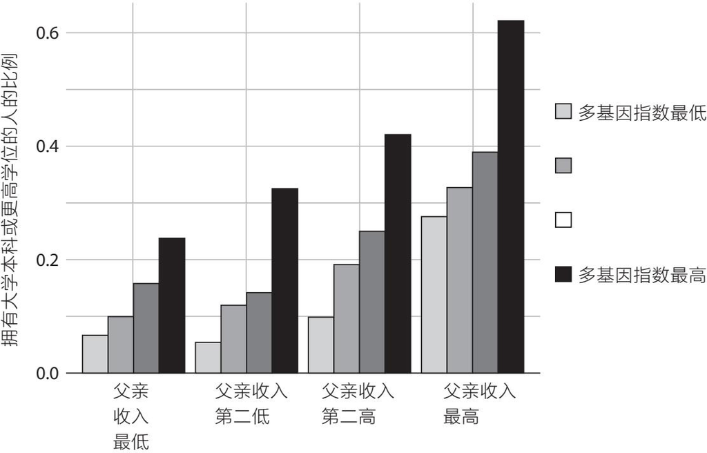

图9.1 1905—1964年出生的美国白人的大学毕业率，按父亲的收入和根据受教育程度的GWAS创建的多基因指数计算。数据由Nicholas Papageorge和Kevin Thom提供；结果见Nicholas W.Papageorge and Kevin Thom,“Genes,Education,and Labor Market Outcomes:Evidence from the Health and Retirement Study,”NBER WorkingPaper 25114 (National Bureau of Economic Research,September 2018),https://doi.org/10.3386/w25114。

但另一条研究路线巧妙地利用了儿童及其父母的遗传信息，来关注环境的影响。请记住，一对父母中的每个人的每个基因都有两个拷贝，只有其中一个会传给孩子。那么，对于每一对亲子，父母的基因组都可以分为传递下去的等位基因（即孩子继承的那些遗传变异）和未传递下去的等位基因（孩子没有继承的遗传变异）。从本质上讲，父母的基因组可分为两部分，一部分就像养父母（也就是说与孩子完全不相似），另一部分像同卵双胞胎（与孩子完全相同）。

那么关键的测试就变成了：父母未传递下去的基因是否仍与他们孩子的生活结果有关？ ㊟ 【Philipp D.Koellinger and K.Paige Harden,“Using Nature to Understand Nurture,”Science 359,no.6374 (January 26,2018):386–87,https://doi.org/10.1126/science.aar6429.】 如果是这样，那么，父母的基因和孩子的表型之间存在着一种关联，这种关联不可能是由于父母对孩子的遗传，而必然是由于父母提供的环境的某个部分。

使用这种研究设计的规模最大的研究之一是在冰岛进行的，这个小国在遗传学研究领域占有重要地位，因为冰岛人的血统是同质的，有“精细”的医疗和家谱记录，并有三分之一以上的人口进行了基因型分型。 ㊟ 【Augustine Kong et al.,“The Nature of Nurture:Effects of Parental Genotypes,”Science 359,no.6374 (January 26,2018):424–28,https://doi.org/10.1126/science.aan6877.】 这项研究发现，对于像身体质量指数或身高这样的身体特征，只有在你真的继承了相关基因的时候，你父母的基因才会使你更高或更胖；未传递的等位基因与孩子的表型没有相关性。而对于教育来说，即使你没有继承相关的基因，你父母的基因仍然与你自己的最终教育程度相关。通过排除生物遗传作为父母特征与子女结果相关的机制，该研究表明，一定是父母提供的环境塑造了子女的教育轨迹。认真对待遗传，可以让我们更清晰地看到环境特权的影响，并直接反驳优生学的论点，即不平等的社会决定因素“实际上”只是无法衡量的遗传差异。

#### 使用工具箱中的每一个工具

在将以多基因指数形式出现的遗传数据更常规地纳入政策和干预研究之前，还有一些实际问题需要解决。截至本书写作时，最大的实际问题是，如我在前文解释的，我们没有在统计上有用的多基因指数，来研究非欧洲遗传血统的人的健康和成就结果。在美国，超过一半的公立学校儿童的种族身份不是白人，因此我们可以合理地预期他们至少有部分非欧洲的遗传血统。所以，最需要教育干预措施改良的儿童，恰恰是我们在遗传学层面了解最少的儿童。统计遗传学家艾丽西亚·马丁这样总结了这个问题：“为了充分实现［多基因指数］的公平的潜力，我们必须在遗传学研究中优先考虑更大的多样性……以确保那些原本就处于不利地位的人［与其他人］的健康差异不会扩大。” ㊟ 【Alicia R.Martin et al.,“Clinical Use of Current Polygenic Risk Scores May Exacerbate Health Disparities,”Nature Genetics 51,no.4 (April 2019):584–91,https://doi.org/10.1038/s41588-019-】

但随着遗传学研究变得更加全球化，这个问题有望得到解决。我预计，科学家们将开发出一种多基因指数，从统计学角度看，它与黑人学生学习成绩的相关性，就像我们已经掌握的白人学生的教育多基因指数与其学习成绩的相关性一样强。我预计，在我们开发出更好的政策和干预工具（从而可靠地提高在数学学习中有困难的青少年的高中毕业率，或者减少患有多动症的青少年的机动车事故）之前，科学家就已经在这个问题上取得了重大进展。正如我在第四章所述，使用多基因指数在不同种族群体之间进行比较，在科学上和伦理上都是错误的。此外，哪些基因与学习成绩有关，以及这些基因与学习成绩的相关程度，在遗传血统不同的人们当中可能是不同的。但是，将全基因组关联分析(GWAS)革命扩展到欧洲血统人口以外的群体，将使研究者能够在每个群体内进行研究，这些研究在确定重要发展结果的具体环境原因方面具有同样的科学严谨性。

制定干预措施和政策从而改善人们生活状况的努力会遇到巨大的障碍，所以我们不应该对任何单一的研究方法抱有过高的期望。当然，在社会科学中更广泛地使用基因数据，并不能解决所有问题。但基因数据可以帮助我们改善人们的生活。正如我在上文描述的，所有的干预措施和政策都反映了世界运作的一种模型。如果关于教育或儿童发展的基础研究有缺陷或不可靠，就更难设计干预措施和政策来改善人们的结果。遗传学对社会科学的最大贡献是为研究者提供了一套额外的工具，通过测量和在统计层面控制一个变量——DNA——来进行基础研究，而这个变量在以前是很难测量和在统计层面控制的。随着遗传信息的采集越来越便宜、应用范围越来越广，我希望我们不要继续错误地宣称我们已经知道了关于如何改善儿童生活的一切，而是准备好使用我们工具箱中的每一件工具。

## 第十章

## 个人责任

“我只是祈祷……他们可以去来世，去上帝想要他们去的地方。”

当谈到自己22岁的怀孕女友查尼丝以及她10岁的弟弟埃迪和母亲安妮特的死亡时，阿莫斯·韦尔斯泪流满面。有一天晚上，韦尔斯来到查尼丝在得克萨斯州沃斯堡市的家中，向母子三人连开数枪。随后韦尔斯向警方自首。在监狱里，他接受了当地NBC记者的7分钟采访，该采访于2013年在网上播出。 ㊟ 【“Unedited:Amos Wells'Jailhouse Interview,”NBC 5 Dallas-Fort Worth,July 3,2013,https://www.nbcdfw.com/news/local/Unedited-Amos-Wells-Jailhouse-Interview_Dallas-Fort-Worth-214139161.html.】

“我没有办法给任何人解释，也没有人可以给出解释，没有人能尝试让我做的事情显得正确，或使它看起来合理，让每个人都能理解……没有理由。”

尽管韦尔斯说他的罪行没有理由，但他的辩护律师试图在遗传学领域寻求解释。辩方在韦尔斯的判决阶段辩称，根据在新西兰进行的一项候选基因研究，韦尔斯之所以有暴力倾向，是因为他继承了某个版本的MAOA基因，一位专家证人称这种基因型为“一种非常糟糕的遗传”。 ㊟ 【Robbie Gonzalez,“How Criminal Courts Are Putting Brains—Not People— on Trial,”Wired,December 4,2017,https://www.wired.com/story/how-criminal-courts-are-putting-brains-not-people-on-trial/.】 本书第二章讨论了为什么科学界不再相信这些候选基因研究是可信的。韦尔斯案件的陪审团也不相信。他们一致投票判他死刑。

作为行为遗传学家，阅读韦尔斯的判决记录是一种令人汗颜的体验。我认识且尊重起初将MAOA基因作为与犯罪行为相关联的候选基因进行研究的那些资深学者。我自己也发表了许多与青少年犯罪有关的遗传学文章。在为学术期刊写论文时，我很难想象我那干巴巴的、充满术语的文字会被得克萨斯法庭上的“专家”引用，而他面对的十二个人将决定政府是否应该杀死一个人。一个令人不安的问题伴随着我们所有的科学：如果你认真地把遗传视为人与人之间差异的来源，那么这对“我们对自己的生活结果应当承担多少责任”意味着什么？当遗传被作为死刑案件的证据时，我们不能将其视为抽象问题并打发掉。

遗传如何影响我们对个人责任的判断，这个问题不限于犯罪行为领域。在本书中，我试图论证，我们应当认真对待遗传，因为它是“出生的意外”，会影响一个人的教育轨迹。正如那些伤害他人的人受到国家的惩罚一样，那些在学校取得“成功”的人也得到了社会的奖励。受过教育的人得到的回报不仅仅是更多的金钱和更稳定的工作，还包括更好的健康和福祉。

在本章中，我接下来会考虑，遗传对教育的影响如何改变我们对“个人对自己在学校的成败以及随之而来的一切应负怎样的责任”的看法。然后，鉴于遗传和“个人责任”之间的紧张关系，我会考虑如何利用关于社会经济结果的遗传学研究，来主张在社会上进行更大规模的资源再分配。

#### 犯罪的遗传学

韦尔斯的辩护团队并不是第一个将其客户的行为归咎于基因的律师团队。2017年对法律数据库的一项检查发现，在十一起刑事案件中，被告的MAOA基因型信息被作为证据提交给法庭，最常见的情况是在量刑阶段或定罪后的上诉程序中。 ㊟ 【Sally McSwiggan,Bernice Elger,and Paul S.Appelbaum,“The Forensic Use of Behavioral Genetics in Criminal Proceedings:Case of the MAOA-L Genotype,”International Journal of Law and Psychiatry 50 (January–February 2017):17–23,https://doi.org/10.1016/j.ijlp.2016.09.005.】 关于遗传信息如何在刑事审判中使用的原始研究提出，遗传信息可能像一把“双刃剑”，它可能让人觉得被告在道德层面不是那么有罪，但也可能让人觉得被告更有可能继续危害社会。 ㊟ 【Lisa G.Aspinwall,Teneille R.Brown,and James Tabery,“The Double-Edged Sword:Does Biomechanism Increase or Decrease Judges'Sentencing of Psychopaths?,”Science 337,no.6096 (August 17,2012):846–49.】

不过，后续研究发现，在司法鉴定的语境中引入的遗传信息，与其说是一把双刃剑，不如说是一把钝刃剑。无论对法官还是对普通人来说，无论罪行是严重的（如谋杀）还是轻微的（如财产侵害），遗传解释一般不会改变人们对恰当量刑的意见。当我们想惩罚某人的时候，我们就会选择无视遗传信息。 ㊟ 【Nicholas Scurich and Paul Appelbaum,“The Blunt-Edged Sword:Genetic Explanations of Misbehavior Neither Mitigate nor Aggravate Punishment,”Journal of Law and the Biosciences 3,no.1 (April 2016):140–57,https://doi.org/10.1093/jlb/lsv053.】

这种对犯罪行为的遗传解释的摒除，理应让我们感到惊讶，因为我们对其他类型的行为和生活结果的判断，更容易受到遗传信息的影响。平均而言，对心理问题（如抑郁症、精神分裂症、焦虑症、肥胖症、饮食失调和性功能障碍）的“生物遗传学”解释减少了人们对这些问题的过错和责任的评判。 ㊟ 【Erlend P.Kvaale,William H.Gottdiener,and Nick Haslam,“Biogenetic Explanations and Stigma:A Meta-Analytic Review of Associations among Lay people,”Social Science & Medicine 96 (November 2013):95–103,https://doi.org/10.1016/j.socscimed.2013.07.017.】 而对性取向的生物遗传学解释的普及，有助于增加人们对同性恋权利的支持。 ㊟ 【Jeremiah Garretson and Elizabeth Suhay,“Scientific Communication about Biological Influences on Homosexuality and the Politics of Gay Rights,”Political Research Quarterly 69,no.1 (March 1,2016):17–29,https://doi.org/10.1177/1065912915620050.】 因此，一些活动团体已经接受了遗传学研究在消除污名方面的潜在价值。例如，“全国精神疾病联盟”为每一种精神病诊断发布了概况介绍，其中显著地表明“遗传”和“大脑结构”是该疾病的原因。 ㊟ 【Fact Sheet Library,NAMI:National Alliance on Mental Illness,accessed November 6,2019,https://www.nami.org/learn-more/fact-sheet-library.】 遗传学可以成为消灭污名的解药。

为什么大家可以接受用遗传学研究来为抑郁症患者或超重者“开脱”，而不能接受用它来为实施暴力犯罪的人“开脱”？这个差异不能简单地归结为两种情况背后的遗传学研究的差异。虽然在阿莫斯·韦尔斯的案件中，关于MAOA基因影响的论点在科学上很弱，但有很强的证据表明基因对人的攻击性和暴力行为有影响。从童年开始的严重行为问题、身体攻击行为和情感冷漠，都是反社会行为综合征的一部分，这种综合征在儿童时期已经具有高度的遗传率(>80%)。 ㊟ 【Essi Viding et al.,“Evidence for Substantial Genetic Risk for Psychopathy in 7-Year-Olds,”Journal of Child Psychology and Psychiatry 46,no.6 (June 2005):592–97,https://doi.org/10.1111/j.1469-7610.2004.00393.x.】

除了高遗传率，科学界还获得了与犯罪可能性有关的遗传数据。在与犯罪行为有关的规模最大的一项遗传学研究中，我和我的合作者汇集了多种冲动或危险行为的GWAS信息，如童年时的多动症症状、滥交、酗酒、吸食大麻。这些行为并不总是违法的，但它们都在犯下暴力罪行的人中更常见。我们一共汇集了近150万人的信息，并测试了个别SNP是否与心理学家所说的“外化”(externalizing)的总体倾向有关。“外化”指的是这样一种倾向：持续地违反规则和社会规范，并与冲动控制作斗争。

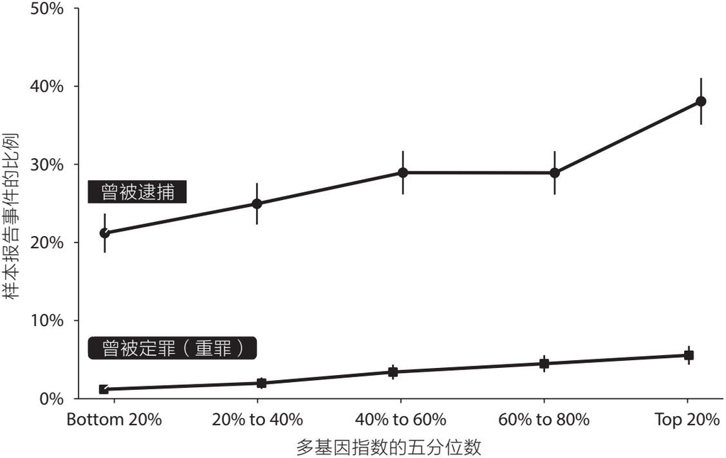

图10.1 从150万人的外化GWAS中创建的多基因指数来看违法犯罪率和反社会行为率。图表改编自Richard Karlsson Linnér et al.,“Multivariate Genomic Analysis of 1.5 Million People Identifies Genes Related to Addiction,Antisocial Behavior,and Health,”bioRxiv,October 16,2020,https://doi.org/10.1101/2020.10.16.342501。

我应该再次强调，我们的研究集中于那些具有欧洲遗传血统并可能被认定为白人的人群内的差异。正如我在第四章所述，这些遗传关联不能也不应该被用来解释不同种族在违法犯罪或监禁率方面的差异。

即使有了这样的提醒，很多人仍会觉得关于犯罪行为的遗传学研究令人不安。事实上，在我们对人类发展和社会背景的了解的语境里解读我刚刚描述的那项研究，需要一整本书的篇幅。在这里我们可以弄简单一些。请注意，如果我说“基因影响人们的冲动和冒险行为，所以他们不应该为自己的犯罪行为负责”，比起我说“基因影响人们的体重，所以他们不应该为自己的超重负责”或“基因影响人们的情绪和情感，所以他们不应该为自己的抑郁负责”，这听起来会有多大不同。根据表型的不同，人们对遗传信息的反应也不同。

#### 想责怪别人

一位心理学家（马特·莱博维茨）、一位哲学家（凯蒂·塔布）和一位精神病学家（保罗·阿普尔鲍姆）对人们接受遗传信息的方式的明显差异感到好奇，于是他们联手尝试了解其原因。 ㊟ 【Matthew S.Lebowitz,Kathryn Tabb,and Paul S.Appelbaum,“Asymmetrical Genetic Attributions for Prosocial versus Antisocial Behaviour,”Nature Human Behaviour 3,no.9 (September 2019):940–49,https://doi.org/10.1038/s41562-019-0651-1.】 在一系列引人入胜的研究中，莱博维茨、塔布和阿普尔鲍姆让实验参与者阅读关于“简”或“汤姆”的故事，这些人有反社会行为（例如，从一个睡着的流浪汉那里偷钱，欺负一个年纪较小的学生）或亲社会行为（例如，检查以确保流浪汉安然无恙，出手保护一个被霸凌的学生）。 ㊟ 【Lebowitz,Tabb,and Appelbaum.他们写道：“我们的发现支持了大量的现有证据，表明‘行为的生物学解释的固有性质’之外的因素，可能影响人们赞同它们的可能性。”如果“人们认为遗传学的解释是在推卸行为的道德责任”，那么他们拒绝接受这些解释就“是因为希望维持责怪别人的能力”。】 然后，实验参与者要么得到用遗传来解释汤姆或简的行为的信息，要么不得到遗传解释。

研究者在介绍基因“证据”时态度相当坚定，既提供了一个图，又提供了一大块解释文字（图10.2）。

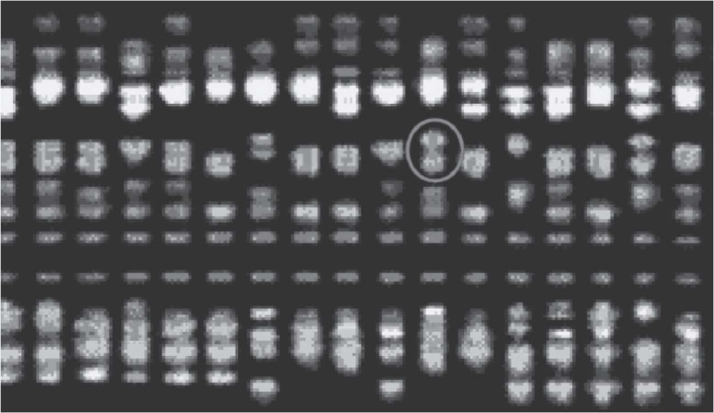

科学家发现，人们之所以会做出这样的行为，是因为受到了他们的基因的影响。这张图显示了基因组中相关基因的位置。根据近期的测试，简具有这样的基因。换言之，简的基因构成（即她从父母那里遗传的基因）导致她在上述情境中做出这样的行为。

图10.2 行为的遗传解释。提供给实验参与者的图片和文字，见Matthew S.Lebowitz,Kathryn Tabb,and Paul S.Appelbaum,“Asymmetrical Genetic Attributions forProsocial versus Antisocial Behaviour,”Nature Human Behaviour 3,no.9 (September 2019):940.49,https://doi.org/10.1038/s41562.019.0651.1 ；图片出自Nicholas Scurich and Paul Appelbaum,“The Blunt-Edged Sword:Genetic Explanations of Misbehavior Neither Mitigate nor Aggravate Punishment,”Journal of Law and the Biosciences 3,no.1 (April 2016):140–57,https://doi.org/10.1093/jlb/lsv053,by permission of Oxford University Press。

然后，实验参与者被问及他们在多大程度上相信他们刚刚被告知的内容：“你认为，在你刚读的故事中，遗传在汤姆/简的行为中起了多大作用？”（记住，除了调查者给他们的信息，参与者对汤姆和简一无所知，而调查者只是告诉他们：“简的基因构成导致她的行为方式。”）在一些研究中，参与者还被问到“你认为，简在多大程度上应当对你刚才读到的行为模式负责？”和“你认为，你刚才读到的简的行为模式在多大程度上反映了她的真实本性？”。

在所有这些研究中，参与者对亲社会行为的遗传解释的认可程度，明显高于对反社会行为的遗传解释的认可程度。拒绝接受对反社会行为的遗传解释的倾向，与认为简应对自己的行为负责的倾向是一致的。

这些结果表明，我们对罪责与责任的判断与我们对遗传解释的认可之间的关系，同人们通常认为的方向相反。并不是说我们听到遗传对人有影响，就相应地认定某人是否责任较轻，而是我们会先决定是否要追究某人的责任，然后相应地选择拒绝或接受有关遗传影响的信息。

我们想要保留责怪别人的能力并想让人承担道德责任的时候，就拒绝接受遗传证据。这个结论有助于大家理解我在第二章介绍的另一项研究的结果。在那项研究中，明尼苏达大学的心理学家要求人们估计不同表型的遗传率。 ㊟ 【Emily A.Willoughby et al.,“Free Will,Determinism,and Intuitive Judgments About the Heritability of Behavior,”Behavior Genetics 49,no.2 (March 2019):136–53,https://doi.org/10.1007/s10519-018-9931-1.】 估计最准确的人，是有多个子女的母亲，但一般来说，受试者的估计都趋向于接近正确答案。换言之，人们对遗传率的平均估计相当接近西方工业化社会对某一性状之遗传率的科学共识。不过，有两个例外。有意思的是，这项研究中的受试者大大高估了两个表型的遗传率：乳腺癌和性取向。那些自称是政治自由派的人，对性取向的遗传率估计特别高。

乳腺癌和性取向是非常不同类型的结果，具有非常不同的遗传结构，但它们至少有一个共同点：说某人对自己是否得癌症或是否成为同性恋者有选择权，通常是一种禁忌。如果你告诉乳腺癌患者，她们应当对自己的疾病负责，那么你就是在主张“受害者有罪论”。如果你告诉同性恋者，他们应当为自己不是异性恋者负责，那么政治自由主义者会认为你是恐同分子。“拒绝接受遗传信息以保留我们责怪别人的能力”与“接受遗传信息以推卸责任”是一体两面。

#### 同卵双胞胎和自由意志系数

人们对责任的判断与他们对遗传率信息的接受与否是相辅相成的，这就提出了一个更基本的问题：我们是否应该将遗传影响视为对一个人的能动性或控制能力的限制？如果一个人的某项结果是具有高遗传率的，这是否意味着他只需要对自己的结果承担较少的责任？

这类讨论有可能陷入永无止境的形而上学辩论的黑洞。客气地说，宇宙是否是决定论的，自由意志是否存在，这些问题已经超出了本书的范围。所以我们需要设置一些哲学上的边界。如果你认为宇宙是决定论的，自由意志的存在与决定论的宇宙不相容，自由意志是一种幻觉，那么遗传学就无话可说了。 ㊟ 【道金斯很好地说明了这一点：“无论人们对决定论的问题持何种观点，插入‘遗传’一词都不会产生任何影响。如果你是一个彻头彻尾的决定论者，你会相信你的所有行为都是由过去的物理原因所决定的，你可能会，也可能不会相信你因此不能对你的外遇行为负责。但是，即便如此，一些物理原因是否是遗传的，又有什么区别呢？为什么遗传决定因素被认为比环境决定因素更不可避免，或更能免除人的责任？”Richard Dawkins,The Extended Phenotype:The Long Reach of the Gene,rev.ed.(Oxford and New York:Oxford University Press,1999).】 遗传只是宇宙的一个小角落，在这个宇宙里，我们已经理解了更大的决定论链条的一小部分。

但抛开形而上的问题，我们作为彼此生活在一起的社会人，对待谋杀和眼睛颜色的方式并不一样。在人类事务的正常过程中，我们不会认为人们是自己选择拥有蓝眼睛的，也不会认为人们是有意识地确保他们的眼睛不是棕色，更不会认为因为人们有蓝眼睛所以他们应该得到更多，因为我们已经（在我看来是正确地）认定，眼睛颜色不是一个人能够自己选择的。我的眼睛是绿色的，这不是我邀功或受责备的理由。但我们会对人们的谋杀行为做出评判。当我们在不同类型的人类结果之间做出这种区分时，我们可以考虑，在做出区分时将有关遗传的信息（以及有关早期环境作用的信息）纳入考虑是否合理。在我看来，答案是肯定的。一个人的生活结果在多大程度上可以追溯到他们的生活起点，他们在多大程度上可以采取不同的行动也就成为问题。

电影《侏罗纪公园》有一个场景，在恐龙开始吃人之前，杰夫·高布伦饰演的角色正向劳拉·邓恩饰演的角色解释“复杂系统的不可预测性”。他把她的手平举起来（“像象形文字一样”），在她的手上滴了一滴水。水会向哪个方向滚落？她做了一个预测，然后他们观察水滑落的地方。高布伦要求她重复这个动作：“我将做同样的事情，并且从同一个地方开始。水将向哪个方向滚落？”

第二次，水珠从邓恩的手的另一侧滑落。为什么水没有以完全相同的方式从她的手上滑落？高布伦利用结果的差异，对邓恩的手进行了在职业场合很不适合的爱抚，同时也提出了“微小的变化……从不重复，并极大地影响结果”的假设。

两个同卵双胞胎一起长大，就像两滴水从同一个地方开始。他们开始是一个受精卵，后来才分裂成两个独立的人。由于是用同一个卵子和同一个精子受孕，他们的DNA序列几乎完全相同（不过并非完全相同，因为发育突变可以只影响双胞胎中的一个，但不影响另一个）。 ㊟ 【单卵双胞胎的基因组之间存在差异，这意味着双胞胎遗传率的估计可能会被系统地低估了，因为由单卵双胞胎之间的遗传差异引起的表型差异会被错误地归因于环境差异。Hakon Jonsson et al.,“Di.erences between Germline Genomes of Monozygotic Twins,”Nature Genetics 53,no.1 (January 2021):27–34,https://doi.org/10.1038/s41588-020-00755-1.】 他们是同一个子宫里的胎儿。他们通常在同一时间出生，通常在同一座房子里被同一对父母抚养，双胞胎的父母有同样的缺陷、长处和怪癖。双胞胎通常在同一所学校上学，住在同一个社区。

不过，同卵双胞胎的许多生活结果并不完全相同。他们之间的差异——双胞胎之一很胖，另一个很瘦；其中一个患有精神分裂症，另一个正常——可能像他们的相似之处一样令人着迷。

研究者通常将同卵双胞胎之间的这些差异称为“非共享环境”(non-shared environment)，缩写为e2。同卵双胞胎之间的相关性越低，非共享环境的值就越高。可能的e2值范围在0（意味着同卵双胞胎的结果总是完全相同）到1（意味着同卵双胞胎并不比从人群中随机抽出的两个人更相似）之间。因此，e2代表人与人之间的某些差异，这些差异并不是由他们的DNA或他们出生的社会环境的差异造成的。e2反映了两滴相同的水从同一个地方开始向不同方向落下的程度。

我的博士生导师埃里克·特克海默提出，在考虑了遗传和家庭教养的限制之后，人类结果的个体性仍然存在，这是一种“量化人类能动性”的方式。 ㊟ 【Eric Turkheimer,“Genetics and Human Agency:Comment on Dar-Nimrod and Heine,”Psychological Bulletin 137,no.5 (2011):825–28,https://doi.org/10.1037/a0024306.】 他的推理是这样的：我们认为，如果一个人可以采取不同的行动，那么他就对某一结果有选择和控制。如果那些有着相同的由偶然性造成的条件的人——也就是说，他们有着相同的基因（不考虑上述的例外）和相同的家庭教养——实际上从未出现过不同的结果，那么就很难想象他们原本有可能出现不同的结果。在特克海默看来，不可预知性成为自由的标志。

简而言之，非共享环境就是自由意志。不是那种已经没有人相信的形而上学的自由意志（根据这种自由意志的观念，人类的灵魂自由地漂浮在物理世界的机械性约束之上），而是一种具体的自由意志……它包含了我们以复杂和不可预测的方式对复杂环境做出反应并在这个过程中建立自我的能力。

在特克海默看来，不由你的基因型或环境条件决定的个人表型空间，定义了你的自由意志可以发挥作用的边界。借用哲学家丹尼尔·丹尼特的一句话，e2让你知道你有多少“施展空间”(elbow room)来选择你成为什么样的人。 ㊟ 【Daniel C.Dennett,Elbow Room:The Varieties of Free Will Worth Wanting,new ed.(Cambridge,MA:MIT Press,2015).】 特克海默随后列出了人类的各种结果，指出同卵双胞胎在我们认为很少涉及选择和道德责任的结果上，只有很小的差别。身高的e2系数小于0.1。也就是说，考虑到一个人在特定的时间和地点出生在一个特定的家庭，拥有一个特定的基因组，人的身高没有多少“施展空间”。但这只是身高。社会和行为结果呢，比如教育？

#### 教育中的自由意志系数

如果同卵双胞胎之间的差异程度表明了人们对自己的结果有多大的潜在的能动性， [1] 那让我们考虑一下我们实际观察到的同卵双胞胎在社会和经济结果方面的差异，以及（在现代工业化资本主义社会中）得到奖励（形式是社会和经济层面的成功）的心理表型的差异。

特克海默指出，智商的e2系数只比身高的e2系数大一点，成年后为0.2，儿童期为0.25，而身高的e2系数则为0.1。但即便是这种微小的差异，也可能是因为可靠地测量智商的难度很大。在使用统计技术来纠正测量误差的研究中，智力测试成绩的e2更接近于0.1。在一项对出生后即分离并在不同家庭中长大的双胞胎的经典研究中，双胞胎之间智力测试成绩的平均差异大约等于同一个人参加两次测试的平均差异。 ㊟ 【T.J.Bouchard and M.McGue,“Familial Studies of Intelligence:A Review,”Science 212,no.4498 (May 29,1981):1055–59,https://doi.org/10.1126/science.7195071.】

智力测试考察的是一般的认知能力，但我们也可以考察更基本的认知过程。我在第六章提过，综合执行能力(general EF)是引导和分配注意力的能力。在儿童和青少年中，一般执行功能的e2几乎不大于零(<0.05)，而处理速度的e2又与身高的e2相当(0.15)。 ㊟ 【Laura E.Engelhardt et al.,“Strong Genetic Overlap between Executive Functions and Intelligence,”Journal of Experimental Psychology:General 145,no.9 (September 2016):1141–59,https://doi.org/10.1037/xge0000195.】

当我们考虑学业成果时，e2有时会大于认知能力的观察值，但并不总是大于它。在我们的得克萨斯双胞胎样本中，童年时期的阅读和数学成绩测试分数的e2大约是0.3。 ㊟ 【Laura E.Engelhardt et al.,“Accounting for the Shared Environment in Cognitive Abilities and Academic Achievement with Measured Socioecological Contexts,”Developmental Science 22,no.1 (January 2019):e12699,https://doi.org/10.1111/desc.12699.】 但在英国，从童年到青春期的成绩测试分数显示e2估计值小于0.15。类似地，作为大学录取通道的全国性标准化考试，普通中等教育证书考试(GCSE)分数的e2为0.13。 ㊟ 【Kaili Rimfeld et al.,“The Stability of Educational Achievement across School Years Is Largely Explained by Genetic Factors,”Npj Science of Learning 3 (September 4,2018):16,https://doi.org/10.1038/s41539-018-0030-0.】

在受教育程度方面，不同国家和不同队列之间存在相当大的差异（在所有研究中，从0.11到0.41不等），而所有样本的平均数为0.25。在斯堪的纳维亚的队列中，e2比较小(0.17)，同样比我们看到的成人身高的e2大不了多少。 ㊟ 【Amelia R.Branigan,Kenneth J.McCallum,and Jeremy Freese,“Variation in the Heritability of Educational Attainment:An International Meta-Analysis,”Social Forces 92,no.1 (September 2013):109–40.】 在收入方面，男性的e2约为0.4（二十年的平均收入）。 ㊟ 【Daniel J.Benjamin et al.,“The Promises and Pitfalls of Genoeconomics,”Annual Review of Economics 4 (September 2012):627–62,https://doi.org/10.1146/annurev-economics-080511-110939.】 这与抑郁症的情况相当，但仍然低于个性的e2。

从这个角度审视双生子研究，由于只关注e2，先天—后天之争就会消失。我们并不试图分析，是双胞胎在社会彩票中的相同结果，还是他们在遗传的自然彩票中的相同结果，导致一起长大的同卵双胞胎拥有如此相似的生活。但我们可以简单地理解，在考虑到社会彩票和自然彩票的相同结果之后，心理特征和社会经济地位的剩余的不可预测性就很小了。一旦我们考虑到运气（包括环境和遗传因素）的强大影响，留给“个人责任”的空间就非常小了。

毕竟，说某人应对自己生活的结果负责，意味着在理论上，他本可以做得不同。一般来说，“这个人可以做得不一样吗？”是一个不可能回答的问题。人只有一次生命，因此，如果你选择了不同的行动，你可以在多大程度上有所不同，或有不同的行为，这在经验上是无法解答的。但是，对一起长大的同卵双胞胎的生活的跟踪告诉我们，实际上，在同一个地方开始生活，有相同的父母、相同的住址和相同的基因的人，最终很少会有不同的受教育程度。他们有几乎完全相同的执行功能技能和大学入学考试分数，以及相当类似的最终受教育程度。

你的基因型，就像你家庭的社会阶层一样，是一个你无法控制的“出生的偶然”。你的基因型，就像你家庭的社会阶层，是你生活中的一种运气。关于同卵双胞胎的文献告诉我们，自然彩票和社会彩票加在一起，是预测某人成年后的社会地位，特别是他们的受教育程度的有力因素。

#### 运气的意识形态

社会心理学的研究表明，你对上一段文字的反应会因你的政治立场而不同。一项研究发现，与自由派相比，保守派更不同意“成功人士很可能在生活中很幸运”这样的说法，而更同意“人们不需要运气就能在生活中取得成功”这样的说法。 ㊟ 【Dena M.Gromet,Kimberly A.Hartson,and David K.Sherman,“The Politics of Luck:Political Ideology and the Perceived Relationship between Luck and Success,”Journal of Experimental Social Psychology 59 (July 2015):40–46,https://doi.org/10.1016/j.jesp.2015.03.002.】 在同一研究者的另一项实验中，人们被要求阅读一段摘自作家迈克尔·刘易斯在普林斯顿大学毕业典礼上的讲话。 ㊟ 【“Princeton University's 2012 Baccalaureate Remarks,”Princeton University,June 3,2012,https://www.princeton.edu/news/2012/06/03/princeton-universitys-2012-baccalaureate-remarks.】 这段话的一个版本使用了刘易斯关于运气在成功中的作用的原话（“人们，特别是成功人士，真的不喜欢听到把成功解释为运气”）；另一个版本用“来自其他人的帮助”替换了“运气”。如果政治保守派读到将成功归因于运气的版本，他们尤其可能不同意这段话（自由派和保守派的参与者在阅读将成功归因于运气的版本时，都认为这段话的作者不那么讨人喜欢，不那么有智慧，也不那么令人钦佩）。

最近，盖洛普民意调查发现，特朗普总统在美国的支持者比反对者更少倾向于同意“富人之所以富是因为他们更幸运”的说法（27%对38%）。 ㊟ 【Jonathan Rothwell,“Experiment Shows Conservatives More Willing to Share Wealth Than They Say,”The New York Times,February 13,2020,https://www.nytimes.com/2020/02/13/upshot/trump-supporters-experiment-inequality.html.】 大约同样比例(26%)的特朗普支持者认为，富人和穷人之间的收入差异是不公平的。与全球平均水平相比，这一比例低得惊人：在60个国家中，大多数人(69%)认为他们国家的收入差异是不公平的。

我们在其他地方也可以看到保守派不愿意承认运气的作用。在《华尔街日报》的一篇评论文章中，撰写了《多样性的错觉》(The Diversity Delusion)和《向警察开战》(The War on Cops)等书的保守派作家希瑟·麦克唐纳坚持认为，“掷骰子一样的随机性［并不］足以使今天的商业巨头或他们的前辈取得成功”。相反，“行为选择塑造了人生轨迹” ㊟ 【Heather MacDonald,“Who 'Deserves'to Go to Harvard?,”Wall Street Journal,June 13,2019,https://www.wsj.com/articles/who-deserves-to-go-to-harvard-11560464201.】 （她还声称，“只有最严酷的政府压制才能消除”分布不均的“先天天赋”的影响，这是我在第八章讨论的关于社会变革可能性的遗传悲观主义的一个例子）。

另一位保守派评论员丹·麦克劳夫林(Dan McLaughlin)对伊丽莎白·沃伦在2011年竞选美国参议员时的发言做出回应时，也谈及了同样的主题。沃伦的一次演讲在网上爆红，谈的是公共投资对于私营企业的成功如何必要。麦克劳夫林描述了为什么他认为沃伦的观点对保守派议题是危险的：它可能将更多的财富再分配正当化。麦克劳夫林在推特上写道：“如果你让人们相信，成功跟工作和努力关系不大，你就是在主张给成功人士增加更多负担。” ㊟ 【Quoted in James Pethokoukis,“You Didn't Build That:Obama and Elizabeth Warren Argue against Any Limiting Principle to Big Government,”blog post,AEIdeas,American Enterprise Institute,July 19,2012,https://www.aei.org/pethokoukis/you-didnt-build-that-obama-and-elizabeth-warren-argue-against-any-limiting-principle-to-big-government/.】

认识到保守派多么厌恶将结果归因于运气，有助于我们理解两个观察到的事实(data)。如果你习惯于认为遗传学研究必然支持右翼世界观的话，你会对这两个事实感到惊讶。首先，保守派比自由派更不可能将人们的生活结果归因于遗传，特别是对于像性取向和吸毒这样的涉及道德判断的结果。 ㊟ 【Stephen P.Schneider,Kevin B.Smith,and John R.Hibbing,“Genetic Attributions:Sign of Intolerance or Acceptance?,”The Journal of Politics 80,no.3 (July 2018):1023–27,https://doi.org/10.1086/696860.】 其次，保守派比自由派更不可能同意富人“天生就有更强的能力”。 ㊟ 【Rothwell,“Experiment Shows Conservatives More Willing to Share Wealth Than They Say.”】

麦克劳夫林反对运气意识形态的原因，是他担心强调运气的作用会增加对财富再分配的支持。他的直觉是正确的。事实上，当人们认为不平等源于人们无法控制的运气因素，而不是认为不平等源于选择时，他们更有可能支持财富再分配。

在一系列精彩的实验中，挪威的一个经济学家团队显示了不平等的来源（选择或偶然）与人们再分配金钱的意愿之间的联系。 ㊟ 【Ingvild Alm.s et al.,“Fairness and the Development of Inequality Acceptance,”Science 328,no.5982 (May 28,2010):1176–78,https://doi.org/10.1126/science.1187300;Alexander W.Cappelen,Erik ..S.rensen,and Bertil Tungodden,“Responsibility for What?Fairness and Individual Responsibility,”European Economic Review 54,no.3 (April 2010):429–41,https://doi.org/10.1016/j.euroecorev.2009.08.005;Alexander W.Cappelen et al.,“Just Luck:An Experimental Study of Risk-Taking and Fairness,”The American Economic Review 103,no.4 (2013):1398–1413.】 他们的许多研究涉及一个可分成两部分的经济游戏的变化。在第一部分，即“生产阶段”，参与者通过执行一项任务，如打字，来“挣”钱。有几个变量在起作用。其中一些变量通常被认为处于参与者的控制之下，例如一个人花了多少分钟打字。有些变量显然不在参与者的控制之下，例如实验者为每一个输入的字设定的价格。有些变量受到的控制程度是模糊的，如一个人在一分钟内能打多少个正确的字。有些变量将一个人分得的蛋糕与整个蛋糕的大小对立起来：例如，就游戏结束时每个人的“身价”而言，如果分数分配得更不平等，那么分数就更显得珍贵，这样一个人就可以通过接受更不平等的分配而最终获得更多的钱。

在游戏的第二部分，人们（参与者或观众）被要求决定，是否每个人都能完全保留他们所挣的钱，或者是否应该对一些钱进行再分配。在这些研究中，人们有不同的偏好。有些人喜欢结果平等，而不考虑不平等的来源。这样的人是激进的平等主义者。有些人喜欢让每个人完全保留他们在游戏中挣到的钱，不管它是如何产生的。这样的人是自由意志主义者。

不过，最常见的是，人们根据不平等的来源是偶然还是选择，来区分公平和不公平的不平等：如果因为实验者分配给他们工作的价码较低，人们在游戏结束时赚的钱较少，那么人们就更有可能通过再分配来抵消这种不平等。

人们对运气在经济游戏中的作用的敏感度，反映在他们对有关不平等的调查的反应中。 ㊟ 【Ingvild Alm.s,Alexander W.Cappelen,and Bertil Tungodden,“Cut-throat Capitalism versus Cuddly Socialism:Are Americans More Meritocratic and E.ciency-Seeking than Scandinavians?,”Journal of Political Economy 128,no.5 (May 2020):1753–88,https://doi.org/10.1086/705551.】 在挪威的一项调查中，将近一半的人(48%)表示，由个人无法控制的因素所造成的收入不平等应该被消除。总体而言，美国人比挪威人更能接受不平等，政治保守派比政治自由派更能接受不平等。但从整体上看，如果结果不平等是运气造成的，人们更愿意实施再分配；如果结果不平等是人们能够控制的因素造成的，人们更不愿意实施再分配。

在旨在衡量人们分配偏好的经济游戏中，以及在关于公平和不公平的不平等的调查中，什么类型的运气会产生不平等，是发生在一个人身上的外部事件，这些事件制约着这个人对其社会和经济结果的总体控制。实验者对你的工作设定了低价，你的母亲没有完成高中学业，这些都是你无法控制的外部事件。

不过，正如我们看到的，社会和经济成果的不平等也源于一个人们无法控制但处于人体之内的因素：遗传。

#### 再谈“想责怪别人”

在本书的第一章，我介绍了一项社会心理学研究，参与者被告知，一个虚构的卡尔松博士发现在人们的数学测试表现中，遗传影响能够解释一点点(4%)或很多(26%)的差异。在后一种情况下，人们，特别是政治自由主义者，认为卡尔松博士不太客观，而且持有不太平等的价值观。也就是说，当卡尔松博士报告说遗传因素对数学考试成绩有较强的影响时，人们认为他相信“如果社会允许一些人比其他人有更多的权力和成功，这是可接受的”这样的观点，而不相信“社会应该努力创造公平的竞争环境，使社会变得公正”这样的观点。

这项研究的结果与我作为行为遗传学研究者的个人经验相吻合：承认遗传对社会层面的重要结果（如数学考试成绩或受教育程度）存在影响，被广泛认为是对平等主义价值观的对抗。当然，人们这么想是有充分理由的。历史上，意识形态极端分子曾利用遗传学思想为极度不平等的社会政策辩护，如限制来自世界某些地区的移民，强迫人们绝育，甚至拘禁和谋杀某些人群。

我们认识到了为什么某些类型的遗传学研究，无论在历史上还是在大众想象中，都与关于人类优劣的极端主义观点有关，但我在本章描述的研究指出了一个与之迥异的框架。一个人的基因型是从他可能继承自父母的许多基因型中随机选择的，这是一个运气问题。平均而言，那些政治上保守的人不愿意承认运气在人们的成功中发挥了作用。同样，当人们想指责别人或以其他方式让别人对其（错误）行为负责时，人们更可能拒绝接受有关遗传影响的信息。但是，当不平等被视为源于人们无法控制的运气因素时，保守派和自由派都更有可能将这些不平等视为不公平的，并支持再分配以实现资源平等。

综合起来考虑，这些要点是一个新的合题的要素：遗传是人们生活中的一个运气问题。如果我们认识到遗传运气在人们的教育和经济成功中的作用，就可以减少人们因为没有取得足够“成就”而受到的指责，并且事实上可以支持再分配资源以实现更大的平等。

而在另一面，如果我们拒绝接受关于遗传如何影响社会和经济结果的信息，就可能会产生意想不到的副作用，即导致任何未能在教育方面取得进展，以及在只惠及“技能型”工人的经济体中表现不佳的人，受到更多的指责。英国社会主义者迈克尔·扬担心穷人遭到污名化（即认为穷是他们自己造成的，所以穷人应受指责）。他发明了“优绩主义”(meritocracy)一词来描述一个反乌托邦的未来。在首次使用“优绩主义”一词四十多年后，扬沮丧地反思了那些在学校表现不佳的人是如何因自己的不成功受到责怪的。“在一个如此强调优绩的社会中被判定为没有优绩的人，他的生活确实很艰难。没有哪个底层阶级曾受到这样严苛的道德谴责。” ㊟ 【Michael Young,“Down with Meritocracy,”The Guardian,June 28,2001,https://www.theguardian.com/politics/2001/jun/29/comment.】

[1] 更确切地说，e2可以被认为是人们拥有能动性的程度的上限。神经科学家凯文·米切尔所说的“发育变异”(developmental variation)，即表型发育过程中固有的随机性，也会增大一对双胞胎之间的差异，而无需其中任何一个人施加我们通常承认为能动性的东西。Kevin J.Mitchell,Innate:How the Wiring of Our Brains Shapes Who We Are (Princeton,NJ:Princeton University Press,2018).

## 第十一章

## 无等级优劣的差异

我的大儿子学说话很费劲，2岁时只会说几个字。儿科医生向我们保证，这个孩子没问题，但大人要有耐心，因为男孩可能说话比较晚。六年后，我儿子每周都要接受好几个小时的言语治疗(speech therapy)。治疗师将手伸进他的嘴里，按住他的舌头前部，这样他才能说出“cookie”（曲奇饼）和“go”（走）。他还练习捏住下巴，把嘴唇弄圆，在吸一口气之前说出正确的音节数。

在他接受言语治疗期间，我坐在等候室里，和我的小女儿一起阅读。她很早就学会了说话。与哥哥相比，她的言语能力的发展简直是个奇迹。一个孩子必须坚持不懈地练习的东西，在另一个孩子身上却似乎毫不费力地实现了。

为什么我的一个孩子可以轻松地说话，另一个孩子却要费九牛二虎之力？没有人可以给我一个明确的答案。但我从双生子研究中看到，发音问题90%以上是可遗传的。孩子在发音能力上的差异，大部分是由遗传差异造成的。影响发音能力的遗传差异似乎也会更普遍地影响运动技能，这一科学发现与我的个人经验相吻合。我的儿子很晚才学会说话，并且他学习爬行、走路、玩滑板车都有困难。

当然，语言障碍的高遗传率并不排除环境的重要性。对发音问题的唯一可用的干预措施是环境干预。没有人会对说话晚的3岁孩子的基因组进行编辑。而且不幸的是，我们可以看到许多被虐待、忽视或遗弃的儿童的例子，他们在婴幼儿期被剥夺了言语互动的机会，这造成了灾难性的后果。但是，在我家提供的正常语言环境的背景下，我的两个孩子在语言发展上的不同，很可能是因为他们碰巧从我和他们的父亲那里继承了不同的基因。

根据我的个人经验，讨论语言障碍的遗传率并没有什么争议。大多数语言治疗师都会询问一个人的发音问题家族史。大多数有多个子女的父母都能观察到他们的孩子在语言发展上有多大差异。看着我的两个孩子在发音能力上的差异，我很容易看到大自然的任性之手。我女儿幸运地继承了遗传变异的相关组合，使她在3岁前就能读出“松鼠”这样的词，我儿子却没有。

遗传和环境因素的结合导致了我女儿言语和语言能力的正常发展，而这些遗传和环境因素完全不在她的控制之内，所以如果说她做了什么来赢得她的言语早熟，那就非常奇怪了。她在发育早期就能说出复杂的句子，这并不意味着她很优秀。相反，我儿子才是值得赞扬的，因为他在日常对话中对气息支撑和语调的关注，就像歌剧演员在大都会歌剧院演出时一样，是经过深思熟虑、百般努力的。

下午晚些时候，结束了言语治疗，在回家的路上，我们在奥斯汀南部一条高速公路地下通道附近的红绿灯前停下。地下通道里有一个人口越来越多的无家可归者的营地，随处可见睡袋、帐篷、轮椅和堆满破烂物品的购物推车。在冬天，这里的人口会大幅增多。到了夏天，由于气温超过37.8摄氏度，营地所剩不多的居民饱受酷热之苦。我在车里放了几瓶水给那些在十字路口举着纸板牌子的人（几乎总是男人）。我通过车窗把水递给那些手被太阳烤得发烫的人。我的孩子们也问了一些问题。

“晚上会有鬼魂抓他们吗？”

“为什么他们没有房子？”

“为什么我们有房子？”

为人父母，的确责任重大，因为我想告诉他们什么，就可以说什么。我可以说，那些人做了错误的选择。我可以引用《圣经》的经文，我小时候就听父母说过这句经文：“若有人不肯做工，就不可吃饭。” ㊟ 【《新约·帖撒罗尼迦后书》第3章第10节。据和合本。】 但是无论我们进行多少次这样的对话，我最后总是说同样的话：因为我们很幸运。妈妈很幸运，有一份能挣钱的工作，所以我们能买衣服、食物、玩具和房子。有些人在他们的生活中很不幸。一个人不幸运，并不意味着他就理所应当睡在大桥底下，但我们成年人并不总是分享足够的钱，让每个人都有房子。

（我女儿又问了一个问题：“为什么人会有私心？”）

正如人与人之间的遗传差异在他们出现发音问题的可能性方面造成了差异，人与人之间的遗传差异也在他们成为无家可归者的可能性方面造成了差异。目前还没有关于无家可归者的全基因组关联分析或双生子研究，但上面的说法几乎可以肯定是成立的。大约20%的无家可归者有严重的精神疾病，如双相障碍症或精神分裂症。 ㊟ 【“Homelessness and Mental Illness:A Challenge to Our Society,”Brain & Behavior Research Foundation,November 19,2018,https://www.bbrfoundation.org/blog/homelessness-and-mental-illness-challenge-our-society.】 据估计，约16%的无家可归者有严重的药物滥用障碍，如酗酒或阿片类药物成瘾。归根结底，无家可归的原因是买不起住房。而如果人们没有继承某些遗传变异，那么他们经历所有这些事情（精神疾病、药物成瘾和贫困）的概率就会不同。我们当中没有经历过精神病、药物成瘾或严重贫困的挑战的人，是幸运的。这种幸运有些是间接的，有些则是直接体现出来的。

#### 对遗传学研究的两种担忧

人与人之间的遗传差异造成了他们有多大可能遇到发音及语言问题的差异。人与人之间的遗传差异造成了他们有多大可能无家可归的差异。第一句话没有特别大的争议，而第二句话几乎肯定有争议。

但为什么呢？

把人与人之间的遗传差异跟社会不平等现象（如贫困和无家可归）联系起来，为什么会激起争议，甚至愤怒？生物伦理学学者埃里克·帕伦斯总结了两个核心的原因：“人们担心，通过调查人类差异的原因，行为遗传学将破坏我们的道德平等概念……不幸的是，存在着一种古老的，也许是永久性的危险，即对人类遗传差异的调查，将被用来为社会权力分配的不平等辩护。”（强调是我加的） ㊟ 【Erik Parens,“Genetic Differences and Human Identities.On Why Talking about Behavioral Genetics Is Important and Difficult,”The Hastings Center Report special supplement 34,no.1 (January-February 2004):S14–36,https://www.thehastingscenter.org/wp-content/uploads/genetic_differences_and_human_identities.pdf.】

帕伦斯对人们为什么对（某些）行为遗传学研究结果感到担忧的总结，与伊丽莎白·安德森对不平等主义的定义有着惊人的相似之处，我在本书的导言中提到过安德森的定义。 ㊟ 【Elizabeth S.Anderson,“What Is the Point of Equality?,”Ethics 109,no.2 (January 1999):287–337,https://doi.org/10.1086/233897.】 她写道：“不平等主义主张，将社会秩序建立在人类的等级制度之上是公正的或必要的，而人类的等级是根据人类的内在价值来划分的。不平等与其说是指商品的分配，不如说是指优等人与劣等人之间的关系……这种不平等的社会关系产生了自由、资源和福利分配上的不平等，并被认为是这些不平等的正当理由。这是种族主义、性别歧视、民族主义、种姓制度、阶级和优生主义等不平等主义意识形态的核心。”（强调是我加的）

在这里，我们再次看到同样的两种担忧。有人担忧，首先，将生物学差异与社会不平等联系起来，就是认为一些人比另一些人优越。这是人类价值的等级观念，与人类道德平等的平等主义思想形成鲜明的对比。其次，这种人类等级观念被用于为不平等现象辩护。贫困和压迫不被视为亟待解决的问题，不平等反而被视为部分人类的生物学优越性的正确而自然的结果。

这两个问题似乎是不可避免的。当我说人们在遗传上有差异，并且这些遗传差异影响到他们的教育和社会阶层、收入和就业以及最终无家可归的机会时，这句话似乎必然会被理解为“人类的价值是有等级的”，“某些人的贫困是不可避免的现象，甚至是理所当然的”。

正如诗人和活动家奥黛丽·洛德解释的，“西欧的大部分历史都教我们以简单化的对立方式看待人类差异：主/从、好/坏、上/下、优/劣”。她认为，其结果就是，“很多时候，我们把认识和探索差异所需的精力，用于假装这些差异是不可逾越的障碍，或者假装它们根本不存在”。 ㊟ 【Audre Lorde,“Re.ections,”Feminist Review 45 (Autumn 1993):4–8.】 优生主义的意识形态认为，遗传差异是实现平等的不可逾越的障碍。太多时候，人们对优生主义意识形态的反应是假装遗传差异根本不存在。

但是，我们并不总是从优劣的等级角度来谈论人与人之间的遗传差异。下面这些例子也许会对读者有所启发。当我说我的两个孩子在遗传层面有差异，而且这些遗传差异对他们的说话能力有实际影响时，我当然不是在暗示我的一个孩子比另一个孩子“优越”或“低劣”。言语能力是受看重的(valued)好东西，但拥有强大的言语能力并不意味着我的一个孩子更有价值(valuable)。两个孩子之间的遗传差异对他们的生活是有意义的，但这些差异并没有创造出基于内在价值的等级。

而且我不能以这些差异为理由，在他们每个人的生活中投入不同程度的资源来巩固不平等。鉴于两个孩子之间的差异，为了所谓的“公平”而对他们给予完全相同的待遇，会让人觉得荒唐。相反，我每周在有困难的孩子的发音与语言发展方面投入更多的时间，因为他需要这种额外的训练和投入。

在儿童言语生成(speech production)这样的特定能力（或障碍）的语境中，以及在家族内部兄弟姐妹的比较中，我们理解了人与人之间的遗传差异，就能避开不平等主义的绞索。我们也许可以谈论人与人之间的遗传差异，同时不把它们归入人类价值的等级体系中。我们也许可以承认人们并非生来就有同等的统计意义上的可能性来经历某些生活结果，同时不把他们之间生活结果的差异辩解为不可避免的和理所当然的。

当我们在考虑遗传差异与社会不平等的关系时，为什么很难（确实很难）做到这一点？与儿童期的语言障碍相比，像“智力”这样的概念更容易被视为具有内在的等级制。当我们谈论DNA时，“价值”这个词有一个微妙而危险的双重含义：人们可能太容易将某人的净资产（就其金融资产的市场价值而言）与他作为人类的内在价值相混淆。当净资产与遗传差异相关时，人们很容易误以为人的内在价值也与DNA有关。在本章中，我想探讨对某些人类结果（其中最重要的是智力测试分数）的遗传学研究会自动激活人类优劣观念的历史原因。然后，我想探讨人类表型的其他一些例子（如身高、耳聋和自闭症），在这些例子中，遗传学研究在很大程度上得到接受，而没有被视为危险而遭到排斥。我们是否可以参考这些例子来拓展我们对“关于社会不平等的遗传学研究是否一定危险”的直觉理解？

#### 受社会看重，而不是有内在的价值

智力（以标准化的智商测试来衡量）和教育成功也许比任何其他人类表型都更多地被从优劣等级的角度来看待，这不是一个偶然。这是一种被刻意设计和传播的想法。正如历史学家丹尼尔·凯弗斯总结的：“［20世纪初的］优生学家用来衡量人的价值的标准，就是看一个人是否拥有优生学家假定自己拥有的那些品质……即那种有利于完成中小学、大学和专业培训的品质。” ㊟ 【Daniel J.Kevles,In the Name of Eugenics:Genetics and the Uses of Human Heredity (New York:Alfred A.Knopf,1985;reprint,Cambridge,MA:Harvard University Press,1998).】 而这种观念在智力测试的历史中表现得最为明显。

第一批智力测试是由心理学家阿尔弗雷德·比奈和泰奥多尔·西蒙共创的，他们受法国政府委托，开发一种方法来识别在学业中有困难并需要额外帮助的儿童。由此产生的比奈——西蒙智力量表要求儿童做一系列典型的日常生活中的实际任务和学习任务。例如，一个8岁的孩子被要求数钱，说出四种颜色，倒数和听写。

比奈——西蒙智力量表的关键进步并不在于他们向儿童提出了哪些具体任务，而在于两项创新。首先，向每个人都布置相同的任务（标准化）。第二，向大量儿童布置相同的任务，从而了解某一年龄段处于平均水平的儿童的表现，以及任何一个儿童的表现与该年龄段的平均表现相比如何（规范化）。

任何一位家长，如果曾经查阅过成长图(growth chart)以了解自己孩子的体重增加是否足够，或者曾经问过老师，孩子的阅读量是否跟得上班上其他同学，就能立即领会到规范化(norming)的力量。你可以看看你朋友的孩子，或者试着回忆一下你的年纪较大的孩子在这个年龄段是什么样的，但你并不真正知道——18个月大的孩子的典型体重是多少？6岁的孩子平均能认识多少个单词？一套适当的规范不会告诉你，为什么一个孩子的体重没有增加或为什么他在阅读上有困难。一套任务规范不会告诉你，是否有其他受社会看重的技能没有得到测量。但是，规范会给你一些比较数据，这些数据的基础不是人们对儿童能做什么和不能做什么的主观直觉。

可悲的是，比奈——西蒙智力量表几乎立即被当作一种量化指标，对已经成为美国社会特征的不平等主义进行正当化。关于测量，心理学家有一些发现：如果你要求儿童完成有限数量的任务，年长的儿童可以比年幼的儿童做得更多；儿童在这些任务中的表现的改善速度不同；在少量任务上的表现差异，可以说明哪些儿童在他们一生中面临的更广泛的学习任务上会有困难。然后心理学家发明了另一个想法：这些任务的表现可以说明哪些人比其他人更优秀。

1908年，美国心理学家亨利·戈达德将比奈——西蒙智力测试从法国引进到美国，将其翻译成英文，用于测试成千上万的儿童。戈达德在1914年出版的《弱智症：其原因和后果》一书中发表了这些结果。 ㊟ 【Henry Herbert Goddard,Feeble-Mindedness:Its Causes and Consequences (New York:Macmillan,1914).】 在书中，戈达德声称，所谓的“弱智者”在生理上是与正常人不同的：“他们的动作不协调，外貌有某种粗糙的特征，这使他们缺乏吸引力，而且在许多方面显示出野蛮人的特征。”

更糟糕的是，在早期智力测试中得分低的人被指责在道德上有缺陷。根据戈达德的说法，这些人缺乏“对道德生活至关重要的因素——是非观的理解，也缺乏自制力”。同时，不道德行为的“愚蠢、粗野”，包括所有形式的“不节制和……社会罪恶”，都被认为是“智力低下的表现”。结合智力、身体和道德方面的缺陷，戈达德对“弱智”的总体描述是一种令人震惊的非人化(dehumanization)：“弱智”的男人或女人在他眼中是“更原始的人类形态”，是“人类有机体的原始和粗糙的形式”，是“有活力的动物”。

这样一来，戈达德和他同时代的人就把智力测试的分数定位为对一个人的价值的评判。得分低的人是“原始”人类，像动物一样野蛮，缺乏道德责任感。正如历史学家纳撒尼尔·康福特总结的，“智商不是衡量你做了什么，而是衡量你是什么——一个人作为人的内在价值的分数”。 ㊟ 【Nathaniel Comfort,“How Science Has Shifted Our Sense of Identity,”Nature 574,no.7777 (October 2019):167–70,https://doi.org/10.1038/d41586-019-03014-4.】 正是这种看法——不是“你在标准化智力测试中做对了多少道题？”而是“你的人性有多原始？”——被附加到关于遗传和遗传差异的思想之上。

作为监督过数千次智商测试的临床心理学家，我觉得阅读戈达德的书是一种非常不愉快的体验。戈达德是美国心理学的创始人之一，这些创始人将该领域转变为一门实验科学，而不是哲学的一个分支。他参与起草了第一部强制要求在公立学校提供特殊教育服务的法律。2002年，在“阿特金斯诉弗吉尼亚州案”中，美国最高法院认定智障人士不应该被判处死刑。戈达德九泉之下一定会为之欢呼，因为他是第一个提供正式证词来主张智力低下人士的刑事罪责应当减少的人。今天，任何从事法医或临床或学校心理学工作的人都是在戈达德参与创建的领域里工作的，就像任何从事统计分析的人都必然要感谢高尔顿、皮尔逊和费希尔。但是，戈达德刻意地提出了一种我认为可憎的想法：智力测试分数是衡量一个人价值的标准。

一个世纪之后，可以用智力测试分数来衡量人性的想法，仍然困扰着关于智力测试的所有讨论。例如，2014年，作家塔那西斯·科茨对人们“探讨”是否存在遗传造成的种族差异感到愤怒，并明确表示，他认为关于一个人的智力的问题与关于一个人的人性的问题是不可分割的：“人生苦短。有太多比‘你的人性比我少吗？’更紧迫，实际上也更有趣的问题。”其他一些作家对科茨的声明感到不解，例如安德鲁·沙利文写道：“这真的让我很难过。” ㊟ 【“Excuse Me,Mr Coates,Ctd,”The Dish,December 13,2014,http://dish.andrewsullivan.com/2014/12/23/excuse-me-mr-coates-ctd/.】 但这种困惑掩盖了对智力测试历史的刻意的无知。科茨的“你的人性比我少吗？”这一反问，正是智力测试的早期支持者认真提出的问题。

对智力和教育成功做任何讨论的时候，我们都不能忽视这段历史。鉴于这段历史，许多学者主张干脆彻底放弃标准化测试和“智力”的概念。根据这种观点，即使是在单一种族群体内，也没有正当的手段来研究智力，因为智力的概念本身就是种族主义和优生主义的。历史学家伊布拉姆·X.肯迪在《如何成为反种族主义者》一书中对这种担忧作了精辟的表述：“使用标准化测试来衡量能力和智力，是有史以来最有效的种族主义政策之一，它贬低了黑人的头脑，在法律上排斥了黑人的身体。” ㊟ 【Ibram X.Kendi,How to Be an Antiracist (New York:One World,2019).】

因此，即使关于智力和受教育程度的分子遗传学研究将注意力完全集中于欧洲血统人群内的个体之间的差异，有些人仍然认为这项工作是毒树之果 ㊟ 【毒树之果(fruit of the poisonous tree)是一个法学的比喻，指通过非法手段取得的证据。该术语的逻辑是，如果证据的来源（树）受到污染，那么任何从它获得的证据（果实）也是被污染的，在诉讼审理的过程中不能采纳，即使该证据足以扭转裁判结果。】 。

但其他关注种族和种族主义的作家认为，不管智商测试的初衷是什么，它仍然是了解歧视性政策之影响的宝贵工具。正如肯迪本人所描述的，识别种族不平等对反抗他所说的“转移性种族主义”(metastatic racism)至关重要。

如果我们不能识别种族不平等，那么我们就不能识别种族主义政策。如果我们不能识别种族主义政策，那么我们就不能挑战种族主义政策。如果我们不能挑战种族主义政策，那么种族主义势力的最终解决方案就会实现：一个我们都看不到，更不用说抵抗的不公的世界。

显而易见，记录诸如寿命、肥胖症和产妇死亡率等健康结果的种族不平等是非常重要的。如果我们无法衡量这些差异，我们如何能消除这些差异，如何能调查政策对其的影响？例如，我们至少需要能够对婴儿死亡率进行量化，才会知道美国南方的医院取消种族隔离后缩小了黑人和白人在婴儿死亡率方面的差距，并在1965年至1975年的十年间拯救了成千上万黑人婴儿的生命。 ㊟ 【Douglas Almond,Kenneth Y.Chay,and Michael Greenstone,“Civil Rights,the War on Poverty,and Black-White Convergence in Infant Mortality in the Rural South and Mississippi,”MIT Department of Economics Working Paper no.07-04,SSRN (Rochester,NY:Social Science Research Network,February 7,2007),https://papers.ssrn.com/abstract=961021.】

记录健康方面的种族不平等，意味着记录每个身体系统的种族不平等，包括大脑。某些种族主义政策损害儿童健康的方式，恰恰是剥夺他们获得大脑最佳发育所需的社会和物理环境条件，或使他们暴露在神经毒素的影响之下。

铅就是一个例子。2014年，当密歇根州弗林特市将其饮用水源从休伦湖改为弗林特河时，弗林特市民（大多是黑人）立即对这一转变提出了抗议：CBS新闻的一篇早期报道的标题是“我甚至不让我的狗喝这种水”。 ㊟ 【“Flint,Michigan,Decision to Break Away from Detroit for Water Riles Residents,”CBS News,March 4,2015,https://www.cbsnews.com/news/.int-michigan-break-away-detroit-water-riles-residents/.】 新水源的水具有腐蚀性，当它流经城市供水系统的陈旧铅管时，铅会渗入饮用水中。在该市饮用水铅含量特别高的地区，血液中铅含量升高的儿童比例几乎增加了两倍，超过10%。 ㊟ 【Mona Hanna-Attisha et al.,“Elevated Blood Lead Levels in Children Associated With the Flint Drinking Water Crisis:A Spatial Analysis of Risk and Public Health Response,”American Journal of Public Health 106,no.2 (February 2016):283–90,https://doi.org/10.2105/AJPH.2015.303003.】 铅暴露程度最高的地区也是黑人儿童最集中的地区。对这些儿童造成伤害的各种因素让密歇根州民权委员会得出结论，铅中毒危机的根源是“系统性的种族主义”。 ㊟ 【Michigan Civil Rights Commission,The Flint Water Crisis:Systemic Racism through the Lens of Flint,February 17,2017,https://www.michigan.gov/documents/mdcr/VFlintCrisisRep-F-Edited3-13-17_554317_7.pdf.】

那么，我们用什么工具来衡量铅的神经毒性作用？智商测试。铅暴露导致的智商缺陷，使研究者和政策制定者无法将铅的影响轻描淡写为暂时性的或微不足道的。这只是例子之一。哈丽雅特·华盛顿在《可怕的浪费》一书中表明，有色人种更有可能接触到有毒废物和空气污染等环境危害。她还认为，智商测试为儿童的抽象推理能力提供了一个数字指标，因此智商测试目前是量化她所称的“环境种族主义” ㊟ 【Harriet A.Washington,A Terrible Thing to Waste:Environmental Racism and Its Assault on the American Mind (New York:Little,Brown Spark,2019).】 之恶劣程度的不可替代的工具：“在今天的技术社会中，由智商［测试］衡量的智力，被认为是与成功最相关的东西……智商太重要了，我们不能忽视它，也不能假装它不存在。” ㊟ 【Washington.】

华盛顿说得对。虽然智商测试测量的技能肯定只能代表人类所有技能和才能的一部分，但我们不能因此认为这些技能不重要。在美国和英国等高收入的西方国家，标准化认知测试（包括经典的智商测试分数，以及用于教育选择的测试分数，如SAT或ACT ㊟ 【ACT（American College Testing，字面意思为美国大学测验）是一种在美国和加拿大用作大学本科录取参考的标准化测验，与SAT类似。美国绝大多数大学同时接受ACT和SAT的成绩，将两者平等看待。】 ，这些测试的分数与智商测试分数高度相关 ㊟ 【A.Alexander Beaujean et al.,“Validation of the Frey and Detterman (2004) IQ Prediction Equations Using the Reynolds Intellectual Assessment Scales,”Personality and Individual Di.erences 41,no.2 (July 2006):353–57,https://doi.org/10.1016/j.paid.2006.01.014.】 ）的分数能够从统计学层面预测我们关心的事情，包括人的寿命。11岁时在智商测试中得分较高的孩子更有可能活到76岁，并且这种联系不能用孩子家庭的社会阶层来解释。 ㊟ 【Catherine M.Calvin et al.,“Intelligence in Youth and All-Cause-Mortality:Systematic Review with Meta-Analysis,”International Journal of Epidemiology 40,no.3 (June 1,2011):626–44,https://doi.org/10.1093/ije/dyq190.】 拥有较高SAT分数（与智商的相关系数高达0.8）的学生 ㊟ 【Meredith C.Frey and Douglas K.Detterman,“Scholastic Assessment or g?The Relationship between the Scholastic Assessment Test and General Cognitive Ability,”Psychological Science 15,no.6 (June 1,2004):373–78,https://doi.org/10.1111/j.0956-7976.2004.00687.x.】 在大学里会获得更好的成绩（特别是在考虑了优秀学生往往会选择更难的专业这一事实之后）。 ㊟ 【Christopher M.Berry and Paul R.Sackett,“Individual Differences in Course Choice Result in Underestimation of the Validity of College Admissions Systems,”Psychological Science 20,no.7 (July 1,2009):822–30,https://doi.org/10.1111/j.1467-9280.2009.02368.x.】 SAT分数特别高的早熟学生也更可能获得理工科的博士学位，更可能拥有专利，更可能在美国前五十名的大学获得终身教职，更可能获得高收入。 ㊟ 【David Lubinski and Camilla Persson Benbow,“Study of Mathematically Precocious Youth After 35 Years:Uncovering Antecedents for the Development of Math-Science Expertise,”Perspectives on Psychological Science 1,no.4 (December 1,2006):316–45,https://doi.org/10.1111/j.1745-6916.2006.00019.x.】

华盛顿希望恢复智力测试的正当性，并将其用作打击环境种族主义的工具。其他一些有色人种学者和女权主义学者也在做这样的努力。这些学者主张，可以用定量研究工具来挑战多种形式的不公正现象。例如，女权主义者安·奥克利认为，放弃定量方法的“女权主义立场”“说到底无助于解放性的社会科学(emancipatory social science)的目标”。 ㊟ 【Ann Oakley,“Gender,Methodology and People's Ways of Knowing:Some Problems with Feminism and the Paradigm Debate in Social Science,”Sociology 32,no.4 (November 1,1998):707–31,https://doi.org/10.1177/0038038598032004005.】 类似地，我在得克萨斯大学的同事凯文·柯克利和杰敏·阿瓦德指出：“心理学历史上一些最丑陋的时刻，是研究者使用量化措施将当时的偏见正当化和法典化(codify)的结果。” ㊟ 【Kevin Cokley and Germine H.Awad,“In Defense of Quantitative Methods:Using the 'Master's Tools'to Promote Social Justice,”Journal for Social Action in Counseling & Psychology 5,no.2 (Summer 2013):26–41.】 不过，他们继续争辩说，“定量方法本质上不是压迫性的”，事实上，“如果定量方法被有多元文化能力的研究者和致力于社会正义的学者兼活动家使用，完全可以是解放性的”。

智力测试被优生主义者定位为衡量一个人的内在价值的工具，由此产生的人类优劣等级制度方便地“批准”了种族主义和阶级主义社会的一些最丑陋的假设。智力测试衡量的是认知功能的个体差异。在当前社会中，这些差异与人们在学校和职场的表现，甚至与他们的寿命长短，都有很大关系。我们面临的挑战是如何在不否认智力差异的遗传原因的前提下拒绝人类优劣等级制度。就像衡量一个孩子的语言障碍一样，智力测试并不能告诉你一个人是否有价值，但它们确实能告诉你，一个人是否能做（一些）受看重的事情。